# Lack of association Association of First and Second-Line Medication Dosing and Progression to Refractory Status Epilepticus in Children

#Load Packages

```r
# install.packages("gmodels")
library(gmodels)

# install.packages("gdata")
library(gdata)
#install.packages("car")
library(car)
#install.packages("tidyverse")
library(tidyverse)
```

#Load the database Import the pSERG database into R

```r
pSERG <- read.csv('C:\\Users\\crist\\Desktop\\pSERG_DOSING.csv')
```

##Clean the database and transform variables Keep only the population of interest and transform variables for analysis.

```r
# Transform date of status epilepticus onset into date format
pSERG$DATESEIZURE <- as.Date(pSERG$DATESEIZURE, format = "%m/%d/%Y")

# Keep only patients from 2014 onwards (start of controls collection: September 2014)
pSERG = subset(pSERG, DATESEIZURE >= "2014-09-01")
dim(pSERG)
```

```
## [1]  560 1582
```

```r
# Order by patient and then by date of status epilepticus
pSERG <- pSERG[order(pSERG$PATIENT_LABEL, pSERG$DATESEIZURE), ]
dim(pSERG)
```

```
## [1]  560 1582
```

```r
# Delete duplicate episodes from the same patient
pSERG <- pSERG[!duplicated(pSERG$PATIENT_LABEL), ]
dim(pSERG)
```

```
## [1]  478 1582
```

```r
# Delete patients with unknown group of SE (refractory or control)
pSERG <- pSERG[which(pSERG$SE_GROUP == "refractory_case" | pSERG$SE_GROUP == "control_case"), ]
dim(pSERG)
```

```
## [1]  478 1582
```

```r
#Create a variable for refractory SE group
pSERG$RSE <- ifelse(pSERG$SE_GROUP == "refractory_case", 1, 0)

# Transform age into numeric
pSERG$G_T_STTS_PLPTCUS_EPISODE_YEARS <- as.numeric(as.character(pSERG$G_T_STTS_PLPTCUS_EPISODE_YEARS))
pSERG$G_T_STTS_PLPTCS_EPISODE_MONTHS <- as.numeric(as.character(pSERG$G_T_STTS_PLPTCS_EPISODE_MONTHS))
# Transform age into a single variable with age in years
pSERG$ageyears <- pSERG$G_T_STTS_PLPTCUS_EPISODE_YEARS + (pSERG$G_T_STTS_PLPTCS_EPISODE_MONTHS / 12)

# Delete patients with unknown age
pSERG <- pSERG[complete.cases(pSERG[ , "ageyears"]), ]
dim(pSERG)
```

```
## [1]  468 1584
```

```r
# Delete patients with unknown sex
pSERG <- pSERG[which(pSERG$SEX == "male" | pSERG$SEX == "female"), ]
CrossTable(pSERG$SEX)
```

```
##
##
##    Cell Contents
## |-------------------------|
## |                       N |
## |         N / Table Total |
## |-------------------------|
##
##
## Total Observations in Table:  468
##
##
##           |    female |      male |
##           |-----------|-----------|
##           |       204 |       264 |
##           |     0.436 |     0.564 |
##           |-----------|-----------|
##
##
##
##
```

```r
dim(pSERG)
```

```
## [1]  468 1584
```

```r
#Create variable male sex
pSERG$male <- ifelse(pSERG$SEX=="male",1,0)

#Transform weight units into kg
pSERG <- pSERG[which(pSERG$WEIGHTUNITS == "kg" | pSERG$WEIGHTUNITS == "lbs"), ]
pSERG$WEIGHT <- as.numeric(as.character(pSERG$WEIGHT))
pSERG$WEIGHT <- ifelse(pSERG$WEIGHTUNITS == "kg", pSERG$WEIGHT, pSERG$WEIGHT * 2.2)

# Delete patients with unknown hospital onset
pSERG <- pSERG[which(pSERG$HOSPITALONSET == "yes" | pSERG$HOSPITALONSET == "no"), ]
dim(pSERG)
```

```
## [1]  468 1585
```

```r
# Create variable white race (vs non-white)
pSERG$white <- ifelse(pSERG$RACE == "white", 1, 0)

# Create variable not hispanic ethnicity (vs hispanic)
pSERG$nothispanic <- ifelse(pSERG$ETHNICITY == "not_hispanic_or_latino", 1, 0)

# Create variable history of developmental delay
pSERG$delay[grepl("delay", pSERG$PAST)] <- 1
pSERG$delay[!grepl("delay", pSERG$PAST)] <- 0

# Create variable history of cerebral palsy
pSERG$palsy[grepl("palsy", pSERG$PAST)] <- 1
pSERG$palsy[!grepl("palsy", pSERG$PAST)] <- 0

# Create variable febrile
pSERG$febrile[grepl("febrile", pSERG$PAST)] <- 1
pSERG$febrile[!grepl("febrile", pSERG$PAST)] <- 0

# Create variable no history of epilepsy
pSERG$NOepilepsy[grepl("epi", pSERG$PAST)] <- 0
pSERG$NOepilepsy[!grepl("epi", pSERG$PAST)] <- 1

# Create variable history of epilepsy
pSERG$priorepilepsy[grepl("epi", pSERG$PAST)] <- 1
pSERG$priorepilepsy[!grepl("epi", pSERG$PAST)] <- 0

# Create variable history of status epilepticus
pSERG$priorSE[grepl("status", pSERG$PAST)] <- 1
pSERG$priorSE[!grepl("status", pSERG$PAST)] <- 0

# Create variable no prior neurological history
pSERG$none[grepl("none", pSERG$PAST)] <- 1
pSERG$none[!grepl("none", pSERG$PAST)] <- 0

#Delete patients with etiology not available
pSERG <- pSERG[complete.cases(pSERG[ ,"ETIOLOGY"]), ]
dim(pSERG)
```

```
## [1]  468 1594
```

```r
#Create variable for structural etiology
pSERG$STRUCTURALETIOLOGY<- ifelse(grepl("structural", pSERG$ETIOLOGY) == TRUE, 1, 0)

#Create variable for unknown etiology
pSERG$UNKETIOLOGY<- ifelse(grepl("unknown", pSERG$ETIOLOGY) == TRUE, 1, 0)

#Create variable for genetic etiology
pSERG$GENETICETIOLOGY <- ifelse(grepl("genetic", pSERG$ETIOLOGY) == TRUE, 1, 0)

#Create variable for metabolic etiology
pSERG$METABOLICETIOLOGY <- ifelse(grepl("metabolic", pSERG$ETIOLOGY) == TRUE, 1, 0)

#Create variable for other etiology
pSERG$OTHERETIOLOGY <- ifelse(grepl("other", pSERG$ETIOLOGY) == TRUE, 1, 0)

#Create variable for febrile cause
pSERG$Febrile_cause <- 0
pSERG$Febrile_cause <- ifelse(pSERG$CAUSE == "febrile_status_epilepticus", 1, 0)

#Create a variable for prior home medication (when home medication can be used as 2nd line)
CrossTable(pSERG$HOMEMED.0)
```

```
##
##
##    Cell Contents
## |-------------------------|
## |                       N |
## |         N / Table Total |
## |-------------------------|
##
##
## Total Observations in Table:  468
##
##
##           |           |     carba |  clobazam |     clona |      diaz |
##           |-----------|-----------|-----------|-----------|-----------|
##           |        22 |         4 |        28 |        20 |        34 |
##           |     0.047 |     0.009 |     0.060 |     0.043 |     0.073 |
##           |-----------|-----------|-----------|-----------|-----------|
##
##
##           |     gabap |      laco |      lamo |      leve |      none |
##           |-----------|-----------|-----------|-----------|-----------|
##           |         2 |         8 |         9 |        78 |       184 |
##           |     0.004 |     0.017 |     0.019 |     0.167 |     0.393 |
##           |-----------|-----------|-----------|-----------|-----------|
##
##
##           |     other |       oxc |     pheno |     pheny |      rufi |
##           |-----------|-----------|-----------|-----------|-----------|
##           |        13 |        17 |        10 |         2 |         4 |
##           |     0.028 |     0.036 |     0.021 |     0.004 |     0.009 |
##           |-----------|-----------|-----------|-----------|-----------|
##
##
##           |      topi |  valproic |      viga |      zoni |
##           |-----------|-----------|-----------|-----------|
##           |        13 |         7 |         4 |         9 |
##           |     0.028 |     0.015 |     0.009 |     0.019 |
##           |-----------|-----------|-----------|-----------|
##
##
##
##
```

```r
CrossTable(pSERG$HOMEMED.1)
```

```
##
##
##    Cell Contents
## |-------------------------|
## |                       N |
## |         N / Table Total |
## |-------------------------|
##
##
## Total Observations in Table:  468
##
##
##           |           |     carba |  clobazam |     clona |      diaz |
##           |-----------|-----------|-----------|-----------|-----------|
##           |       283 |         1 |        16 |        10 |        13 |
##           |     0.605 |     0.002 |     0.034 |     0.021 |     0.028 |
##           |-----------|-----------|-----------|-----------|-----------|
##
##
##           |     gabap |      laco |      lamo |      leve |      none |
##           |-----------|-----------|-----------|-----------|-----------|
##           |         2 |         9 |         9 |        45 |         1 |
##           |     0.004 |     0.019 |     0.019 |     0.096 |     0.002 |
##           |-----------|-----------|-----------|-----------|-----------|
##
##
##           |     other |       oxc |     pheno |      topi |  valproic |
##           |-----------|-----------|-----------|-----------|-----------|
##           |        18 |        14 |         7 |         9 |        10 |
##           |     0.038 |     0.030 |     0.015 |     0.019 |     0.021 |
##           |-----------|-----------|-----------|-----------|-----------|
##
##
##           |      viga |      zoni |
##           |-----------|-----------|
##           |         5 |        16 |
##           |     0.011 |     0.034 |
##           |-----------|-----------|
##
##
##
##
```

```r
CrossTable(pSERG$HOMEMED.2)
```

```
##
##
##    Cell Contents
## |-------------------------|
## |                       N |
## |         N / Table Total |
## |-------------------------|
##
##
## Total Observations in Table:  468
##
##
##           |           |  clobazam |     clona |      diaz |     gabap |
##           |-----------|-----------|-----------|-----------|-----------|
##           |       354 |         5 |         5 |         4 |         2 |
##           |     0.756 |     0.011 |     0.011 |     0.009 |     0.004 |
##           |-----------|-----------|-----------|-----------|-----------|
##
##
##           |      laco |      lamo |      leve |      none |     other |
##           |-----------|-----------|-----------|-----------|-----------|
##           |         5 |         5 |        17 |         1 |        15 |
##           |     0.011 |     0.011 |     0.036 |     0.002 |     0.032 |
##           |-----------|-----------|-----------|-----------|-----------|
##
##
##           |       oxc |     pheno |     pheny |      rufi |      topi |
##           |-----------|-----------|-----------|-----------|-----------|
##           |        11 |         8 |         1 |         6 |         9 |
##           |     0.024 |     0.017 |     0.002 |     0.013 |     0.019 |
##           |-----------|-----------|-----------|-----------|-----------|
##
##
##           |  valproic |      viga |      zoni |
##           |-----------|-----------|-----------|
##           |        11 |         5 |         4 |
##           |     0.024 |     0.011 |     0.009 |
##           |-----------|-----------|-----------|
##
##
##
##
```

```r
CrossTable(pSERG$HOMEMED.3)
```

```
##
##
##    Cell Contents
## |-------------------------|
## |                       N |
## |         N / Table Total |
## |-------------------------|
##
##
## Total Observations in Table:  468
##
##
##           |           |  clobazam |     clona |      diaz |     gabap |
##           |-----------|-----------|-----------|-----------|-----------|
##           |       413 |         4 |         4 |         2 |         2 |
##           |     0.882 |     0.009 |     0.009 |     0.004 |     0.004 |
##           |-----------|-----------|-----------|-----------|-----------|
##
##
##           |      laco |      lamo |      leve |     other |       oxc |
##           |-----------|-----------|-----------|-----------|-----------|
##           |         3 |         1 |        13 |         9 |         1 |
##           |     0.006 |     0.002 |     0.028 |     0.019 |     0.002 |
##           |-----------|-----------|-----------|-----------|-----------|
##
##
##           |     pheno |      rufi |      topi |  valproic |      viga |
##           |-----------|-----------|-----------|-----------|-----------|
##           |         1 |         2 |         6 |         3 |         1 |
##           |     0.002 |     0.004 |     0.013 |     0.006 |     0.002 |
##           |-----------|-----------|-----------|-----------|-----------|
##
##
##           |      zoni |
##           |-----------|
##           |         3 |
##           |     0.006 |
##           |-----------|
##
##
##
##
```

```r
CrossTable(pSERG$HOMEMED.4)
```

```
##
##
##    Cell Contents
## |-------------------------|
## |                       N |
## |         N / Table Total |
## |-------------------------|
##
##
## Total Observations in Table:  468
##
##
##           |           |  clobazam |     clona |      diaz |     gabap |
##           |-----------|-----------|-----------|-----------|-----------|
##           |       442 |         1 |         3 |         3 |         1 |
##           |     0.944 |     0.002 |     0.006 |     0.006 |     0.002 |
##           |-----------|-----------|-----------|-----------|-----------|
##
##
##           |      laco |      leve |     other |       oxc |     pheno |
##           |-----------|-----------|-----------|-----------|-----------|
##           |         1 |         1 |         7 |         1 |         2 |
##           |     0.002 |     0.002 |     0.015 |     0.002 |     0.004 |
##           |-----------|-----------|-----------|-----------|-----------|
##
##
##           |     pheny |      topi |      viga |      zoni |
##           |-----------|-----------|-----------|-----------|
##           |         2 |         2 |         1 |         1 |
##           |     0.004 |     0.004 |     0.002 |     0.002 |
##           |-----------|-----------|-----------|-----------|
##
##
##
##
```

```r
#Create variable for prior home treatment with LEV
pSERG$HOMEMEDLEV <- 0
pSERG$HOMEMEDLEV[pSERG$HOMEMED.0=="leve" | pSERG$HOMEMED.1=="leve" | pSERG$HOMEMED.2=="leve" | pSERG$HOMEMED.3=="leve" | pSERG$HOMEMED.4=="leve"] <- 1
CrossTable(pSERG$HOMEMEDLEV)
```

```
##
##
##    Cell Contents
## |-------------------------|
## |                       N |
## |         N / Table Total |
## |-------------------------|
##
##
## Total Observations in Table:  468
##
##
##           |         0 |         1 |
##           |-----------|-----------|
##           |       314 |       154 |
##           |     0.671 |     0.329 |
##           |-----------|-----------|
##
##
##
##
```

```r
#Prior home treatment with PB
pSERG$HOMEMEDPB <- 0
pSERG$HOMEMEDPB[pSERG$HOMEMED.0=="pheno" | pSERG$HOMEMED.1=="pheno" | pSERG$HOMEMED.2=="pheno" | pSERG$HOMEMED.3=="pheno" | pSERG$HOMEMED.4=="pheno"] <- 1
CrossTable(pSERG$HOMEMEDPB)
```

```
##
##
##    Cell Contents
## |-------------------------|
## |                       N |
## |         N / Table Total |
## |-------------------------|
##
##
## Total Observations in Table:  468
##
##
##           |         0 |         1 |
##           |-----------|-----------|
##           |       441 |        27 |
##           |     0.942 |     0.058 |
##           |-----------|-----------|
##
##
##
##
```

```r
#Prior home treatment with PHT
pSERG$HOMEMEDPHT <- 0
pSERG$HOMEMEDPHT[pSERG$HOMEMED.0=="pheny" | pSERG$HOMEMED.1=="pheny" | pSERG$HOMEMED.2=="pheny" | pSERG$HOMEMED.3=="pheny" | pSERG$HOMEMED.4=="pheny"] <- 1
CrossTable(pSERG$HOMEMEDPHT)
```

```
##
##
##    Cell Contents
## |-------------------------|
## |                       N |
## |         N / Table Total |
## |-------------------------|
##
##
## Total Observations in Table:  468
##
##
##           |         0 |         1 |
##           |-----------|-----------|
##           |       463 |         5 |
##           |     0.989 |     0.011 |
##           |-----------|-----------|
##
##
##
##
```

```r
#Prior home treatment with VPA
pSERG$HOMEMEDVPA <- 0
pSERG$HOMEMEDVPA[pSERG$HOMEMED.0=="valproic" | pSERG$HOMEMED.1=="valproic" | pSERG$HOMEMED.2=="valproic" | pSERG$HOMEMED.3=="valproic" | pSERG$HOMEMED.4=="valproic"] <- 1
CrossTable(pSERG$HOMEMEDVPA)
```

```
##
##
##    Cell Contents
## |-------------------------|
## |                       N |
## |         N / Table Total |
## |-------------------------|
##
##
## Total Observations in Table:  468
##
##
##           |         0 |         1 |
##           |-----------|-----------|
##           |       438 |        30 |
##           |     0.936 |     0.064 |
##           |-----------|-----------|
##
##
##
##
```

```r
#Prior home treatment with LCM
pSERG$HOMEMEDLCM <- 0
pSERG$HOMEMEDLCM[pSERG$HOMEMED.0=="laco" | pSERG$HOMEMED.1=="laco" | pSERG$HOMEMED.2=="laco" | pSERG$HOMEMED.3=="laco" | pSERG$HOMEMED.4=="laco"] <- 1
CrossTable(pSERG$HOMEMEDLCM)
```

```
##
##
##    Cell Contents
## |-------------------------|
## |                       N |
## |         N / Table Total |
## |-------------------------|
##
##
## Total Observations in Table:  468
##
##
##           |         0 |         1 |
##           |-----------|-----------|
##           |       442 |        26 |
##           |     0.944 |     0.056 |
##           |-----------|-----------|
##
##
##
##
```

```r
#Prior home treatment with any of the second line treatments
pSERG$HOMEMEDAED <- 0
pSERG$HOMEMEDAED[pSERG$HOMEMEDLEV==1 | pSERG$HOMEMEDPHT==1 | pSERG$HOMEMEDPB==1 | pSERG$HOMEMEDVPA==1 | pSERG$HOMEMEDLCM==1] <- 1
CrossTable(pSERG$HOMEMEDAED)
```

```
##
##
##    Cell Contents
## |-------------------------|
## |                       N |
## |         N / Table Total |
## |-------------------------|
##
##
## Total Observations in Table:  468
##
##
##           |         0 |         1 |
##           |-----------|-----------|
##           |       277 |       191 |
##           |     0.592 |     0.408 |
##           |-----------|-----------|
##
##
##
##
```

```r
#Family history of epilepsy
pSERG$familyhxsz <- ifelse(pSERG$family_history_of_seizures =="yes", 1, 0)
CrossTable(pSERG$familyhxsz)
```

```
##
##
##    Cell Contents
## |-------------------------|
## |                       N |
## |         N / Table Total |
## |-------------------------|
##
##
## Total Observations in Table:  468
##
##
##           |         0 |         1 |
##           |-----------|-----------|
##           |       337 |       131 |
##           |     0.720 |     0.280 |
##           |-----------|-----------|
##
##
##
##
```

```r
### Create a variable for intermittent SE
pSERG$INTERMITTENT <- ifelse(grepl("intermittent",pSERG$TYPESTATUS) == TRUE, 1, 0)

#Create variable for inhospital BZD administration
pSERG$INHOSPITAL <- ifelse(pSERG$BZDLOCATION.0 =="studyh"|pSERG$BZDLOCATION.0 =="outsideh", 1, 0)
CrossTable(pSERG$INHOSPITAL)
```

```
##
##
##    Cell Contents
## |-------------------------|
## |                       N |
## |         N / Table Total |
## |-------------------------|
##
##
## Total Observations in Table:  468
##
##
##           |         0 |         1 |
##           |-----------|-----------|
##           |       210 |       258 |
##           |     0.449 |     0.551 |
##           |-----------|-----------|
##
##
##
##
```

```r
#Create a variable for patients who received continuous infusion
pSERG$CONTINF <-ifelse(pSERG$CONTMED.0=="",0,1)

# Transform convulsive duration into numeric
pSERG$CONVULSIVEDURATION <- as.numeric(as.character(pSERG$CONVULSIVEDURATION))
# Create convulsive duration in minutes
pSERG$convulsivemin <- pSERG$CONVULSIVEDURATION
pSERG$convulsivehr <- pSERG$CONVULSIVEDURATION * 60
pSERG$convulsivedurationmin <- ifelse(pSERG$CONVULSIVEDURATIONUNITS == "min", pSERG$convulsivemin, pSERG$convulsivehr)

# Create a variable for Seizure duration in hours
pSERG$SEIZUREDURATION <- as.numeric(as.character(pSERG$SEIZUREDURATION))
for (i in 1 : dim(pSERG)[1]) {
  if (pSERG$SEIZUREDURATIONUNITS[i] == "day") {
    pSERG$SEIZUREDURATION[i] = pSERG$SEIZUREDURATION[i] * 1440
  } else if (pSERG$SEIZUREDURATIONUNITS[i] == "min") {
    pSERG$SEIZUREDURATION[i] = pSERG$SEIZUREDURATION[i]
  } else if (pSERG$SEIZUREDURATIONUNITS[i] == "hr") {
    pSERG$SEIZUREDURATION[i] = pSERG$SEIZUREDURATION[i] * 60
  }
}

pSERG$SEIZUREDURATIONHR <- pSERG$SEIZUREDURATION/60

#Create a variable for ICU days
pSERG$ICU_DURATION <- as.numeric(as.character(pSERG$ICU_DURATION))
pSERG$ICU_DURATION <- ifelse(pSERG$ICU_DURATION ==0.00000,NA,pSERG$ICU_DURATION)
pSERG$ICU_DURATIONdays<- ifelse(pSERG$ICU_UNITS=="days",pSERG$ICU_DURATION,pSERG$ICU_DURATION/24)

#Create variable requirement for intubation excluding unknown values
pSERG$intubation[pSERG$INTUBATION == "yes"] <- 1
pSERG$intubation[pSERG$INTUBATION == "no"] <- 0
CrossTable(pSERG$intubation)
```

```
##
##
##    Cell Contents
## |-------------------------|
## |                       N |
## |         N / Table Total |
## |-------------------------|
##
##
## Total Observations in Table:  458
##
##
##           |         0 |         1 |
##           |-----------|-----------|
##           |       211 |       247 |
##           |     0.461 |     0.539 |
##           |-----------|-----------|
##
##
##
##
```

```r
#Create variable hypotension excluding unknown values
pSERG$hypo[pSERG$HYPO == "yes"] <- 1
pSERG$hypo[pSERG$HYPO == "no"] <- 0
CrossTable(pSERG$hypo)
```

```
##
##
##    Cell Contents
## |-------------------------|
## |                       N |
## |         N / Table Total |
## |-------------------------|
##
##
## Total Observations in Table:  458
##
##
##           |         0 |         1 |
##           |-----------|-----------|
##           |       358 |       100 |
##           |     0.782 |     0.218 |
##           |-----------|-----------|
##
##
##
##
```

```r
#Create a dichotomous variable return to baseline
pSERG$baseline <- ifelse(pSERG$BASELINE =="yes", 1, 0)
CrossTable(pSERG$baseline)
```

```
##
##
##    Cell Contents
## |-------------------------|
## |                       N |
## |         N / Table Total |
## |-------------------------|
##
##
## Total Observations in Table:  468
##
##
##           |         0 |         1 |
##           |-----------|-----------|
##           |       121 |       347 |
##           |     0.259 |     0.741 |
##           |-----------|-----------|
##
##
##
##
```

```r
#Create variable mortality excluding unknown values
pSERG$alive[pSERG$ALIVE == "yes"] <- 1
pSERG$alive[pSERG$ALIVE == "no"] <- 0
CrossTable(pSERG$alive)
```

```
##
##
##    Cell Contents
## |-------------------------|
## |                       N |
## |         N / Table Total |
## |-------------------------|
##
##
## Total Observations in Table:  458
##
##
##           |         0 |         1 |
##           |-----------|-----------|
##           |        10 |       448 |
##           |     0.022 |     0.978 |
##           |-----------|-----------|
##
##
##
##
```

```r
#Transform BZD doses into numeric variable
pSERG$BZDDOSE.0<- as.numeric(as.character(pSERG$BZDDOSE.0))
pSERG$BZDDOSE.1<- as.numeric(as.character(pSERG$BZDDOSE.1))
pSERG$BZDDOSE.2<- as.numeric(as.character(pSERG$BZDDOSE.2))
pSERG$BZDDOSE.3<- as.numeric(as.character(pSERG$BZDDOSE.3))
pSERG$BZDDOSE.4<- as.numeric(as.character(pSERG$BZDDOSE.4))

#Delete patients with first BZD dose incomplete
pSERG <- pSERG[complete.cases(pSERG[ ,"BZDDOSE.0"]), ]
dim(pSERG)
```

```
## [1]  445 1619
```

```r
#Create variable BZD dose/Kg
pSERG$BZDDOSE.0KG <- pSERG$BZDDOSE.0 / pSERG$WEIGHT
pSERG$BZDDOSE.1KG <- pSERG$BZDDOSE.1 / pSERG$WEIGHT
pSERG$BZDDOSE.2KG <- pSERG$BZDDOSE.2 / pSERG$WEIGHT
pSERG$BZDDOSE.3KG <- pSERG$BZDDOSE.3 / pSERG$WEIGHT
pSERG$BZDDOSE.4KG <- pSERG$BZDDOSE.4 / pSERG$WEIGHT

# Delete patients with unknown/undetermined BZD
pSERG <- pSERG[!(pSERG$BZDMED.0== "other" & pSERG$BZDMEDOTHER.0 == "none"), ]
pSERG <- pSERG[!(pSERG$BZDMED.0== "other" & pSERG$BZDMEDOTHER.0 == "None"), ]
pSERG <- pSERG[!(pSERG$BZDMED.0== "other" & pSERG$BZDMEDOTHER.0 == "UNK"), ]
pSERG <- pSERG[!(pSERG$BZDMED.0== "other" & pSERG$BZDMEDOTHER.0 == "N/A"), ]

#Transform BZD time into numeric variable
pSERG$BZDTIME.0 <- as.numeric(as.character(pSERG$BZDTIME.0))
pSERG$BZDTIME.1 <- as.numeric(as.character(pSERG$BZDTIME.1))
pSERG$BZDTIME.2 <- as.numeric(as.character(pSERG$BZDTIME.2))
pSERG$BZDTIME.3 <- as.numeric(as.character(pSERG$BZDTIME.3))
pSERG$BZDTIME.4 <- as.numeric(as.character(pSERG$BZDTIME.4))
# Delete patients with unknown time to first benzodiazepine
pSERG <- pSERG[complete.cases(pSERG[ , "BZDTIME.0"]), ]
dim(pSERG)
```

```
## [1]  405 1624
```

```r
#Create variable for delayed treatment
pSERG$BZDTIME10<-ifelse(pSERG$BZDTIME.0>10,1,0)

# Delete patients with unknown route of administration
pSERG <- pSERG[!(pSERG$BZDROUTE.0== "other" & pSERG$BZDROUTEOTHER.0 == "Not Documented"), ]
pSERG <- pSERG[!(pSERG$BZDROUTE.0== "other" & pSERG$BZDROUTEOTHER.0 == "Unknown"), ]
pSERG <- pSERG[!(pSERG$BZDROUTE.0== "other" & pSERG$BZDROUTEOTHER.0 == "N/A"), ]

#Transform AED doses into numeric variable
pSERG$AEDDOSE.0<- as.numeric(as.character(pSERG$AEDDOSE.0))
pSERG$AEDDOSE.1<- as.numeric(as.character(pSERG$AEDDOSE.1))
pSERG$AEDDOSE.2<- as.numeric(as.character(pSERG$AEDDOSE.2))
pSERG$AEDDOSE.3<- as.numeric(as.character(pSERG$AEDDOSE.3))
pSERG$AEDDOSE.4<- as.numeric(as.character(pSERG$AEDDOSE.4))
#Delete patients with first AED dose incomplete
pSERG <- pSERG[complete.cases(pSERG[ ,"AEDDOSE.0"]), ]
dim(pSERG)
```

```
## [1]  371 1625
```

```r
#Create variable AED dose/Kg
pSERG$AEDDOSE.0KG <- pSERG$AEDDOSE.0 / pSERG$WEIGHT
pSERG$AEDDOSE.1KG <- pSERG$AEDDOSE.1 / pSERG$WEIGHT
pSERG$AEDDOSE.2KG <- pSERG$AEDDOSE.2 / pSERG$WEIGHT
pSERG$AEDDOSE.3KG <- pSERG$AEDDOSE.3 / pSERG$WEIGHT
pSERG$AEDDOSE.4KG <- pSERG$AEDDOSE.4 / pSERG$WEIGHT

#Transform AED time into numeric variable
pSERG$AEDTIME.0 <- as.numeric(as.character(pSERG$AEDTIME.0))
pSERG$AEDTIME.1 <- as.numeric(as.character(pSERG$AEDTIME.1))
pSERG$AEDTIME.2 <- as.numeric(as.character(pSERG$AEDTIME.2))
pSERG$AEDTIME.3 <- as.numeric(as.character(pSERG$AEDTIME.3))
pSERG$AEDTIME.4 <- as.numeric(as.character(pSERG$AEDTIME.4))
# Delete patients with unknown time to first AED
pSERG <- pSERG[complete.cases(pSERG[ , "AEDTIME.0"]), ]
dim(pSERG)
```

```
## [1]  358 1630
```

```r
# Identify what did the patients receive as first single non-BZD AED
CrossTable(pSERG$AEDMEDICATION.0)
```

```
##
##
##    Cell Contents
## |-------------------------|
## |                       N |
## |         N / Table Total |
## |-------------------------|
##
##
## Total Observations in Table:  358
##
##
##               |      clobazam |  fosphenytoin |    lacosamide | levetiracetam |         other |
##               |---------------|---------------|---------------|---------------|---------------|
##               |             1 |           161 |             5 |           148 |             8 |
##               |         0.003 |         0.450 |         0.014 |         0.413 |         0.022 |
##               |---------------|---------------|---------------|---------------|---------------|
##
##
##               | phenobarbital |     phenytoin |      valproic |
##               |---------------|---------------|---------------|
##               |            22 |             7 |             6 |
##               |         0.061 |         0.020 |         0.017 |
##               |---------------|---------------|---------------|
##
##
##
##
```

```r
# Identify the type of other treatments for non-BZD AED
CrossTable(pSERG[which(pSERG$AEDMEDICATION.0 =="other"), ]$AEDMEDICATIONOTHER.0)
```

```
##
##
##    Cell Contents
## |-------------------------|
## |                       N |
## |         N / Table Total |
## |-------------------------|
##
##
## Total Observations in Table:  8
##
##
##              |   Clonazepam |     fentanyl | fosphenytoin |     Klonopin |     Propofol |
##              |--------------|--------------|--------------|--------------|--------------|
##              |            1 |            2 |            1 |            1 |            1 |
##              |        0.125 |        0.250 |        0.125 |        0.125 |        0.125 |
##              |--------------|--------------|--------------|--------------|--------------|
##
##
##              |    valproate |    Valproate |
##              |--------------|--------------|
##              |            1 |            1 |
##              |        0.125 |        0.125 |
##              |--------------|--------------|
##
##
##
##
```

```r
# Delete patients with unconventional drugs as second line treatment (out of guideline recommendations)
pSERG <- pSERG[!(pSERG$AEDMEDICATIONOTHER.0 =="fentanyl" | pSERG$AEDMEDICATIONOTHER.0 =="Propofol"), ]

# Create categorical variable first non-BZD AED type (fosphenytoin/levetiracetam/other)
pSERG$AEDMEDICATION.0
```

[output not shown]

[output cut: 74 more lines]

```r
pSERG$AEDTYPE[pSERG$AEDMEDICATION.0 == "fosphenytoin"] <- 0
pSERG$AEDTYPE[pSERG$AEDMEDICATION.0 == "levetiracetam"] <- 1
pSERG$AEDTYPE[pSERG$AEDMEDICATION.0 == "other" | pSERG$AEDMEDICATION.0 == "lacosamide" | pSERG$AEDMEDICATION.0 == "valproic" | pSERG$AEDMEDICATION.0 == "clobazam" | pSERG$AEDMEDICATION.0 == "phenobarbital" | pSERG$AEDMEDICATION.0 == "phenytoin"] <- 2
CrossTable(pSERG$AEDTYPE)
```

```
##
##
##    Cell Contents
## |-------------------------|
## |                       N |
## |         N / Table Total |
## |-------------------------|
##
##
## Total Observations in Table:  355
##
##
##           |         0 |         1 |         2 |
##           |-----------|-----------|-----------|
##           |       161 |       148 |        46 |
##           |     0.454 |     0.417 |     0.130 |
##           |-----------|-----------|-----------|
##
##
##
##
```

```r
# Identify the route of first dose of all non-BZD ASM
CrossTable(pSERG$AEDROUTE.0)
```

```
##
##
##    Cell Contents
## |-------------------------|
## |                       N |
## |         N / Table Total |
## |-------------------------|
##
##
## Total Observations in Table:  355
##
##
##               | intramuscular |            io |           Ivb |           Ivf |         other |
##               |---------------|---------------|---------------|---------------|---------------|
##               |             2 |             2 |           238 |           104 |             2 |
##               |         0.006 |         0.006 |         0.670 |         0.293 |         0.006 |
##               |---------------|---------------|---------------|---------------|---------------|
##
##
##               |            po |        rectal |
##               |---------------|---------------|
##               |             6 |             1 |
##               |         0.017 |         0.003 |
##               |---------------|---------------|
##
##
##
##
```

```r
table(pSERG$AEDROUTE.0)
```

```
##
## intramuscular            io           Ivb           Ivf         other
##             2             2           238           104             2
##            po        rectal
##             6             1
```

```r
# Delete patients with route of administration different to intravenous
pSERG <- pSERG[which(pSERG$AEDROUTE.0 =="Ivb" | pSERG$AEDROUTE.0 =="Ivf"), ]

#Identify who got first BZD
pSERG$AEDBZD1 <- ifelse(pSERG$AEDTIME.0 < pSERG$BZDTIME.0,1,0)
pSERG$BZDFIRST <- ifelse(pSERG$AEDBZD1== 0,1,0)
pSERG[which(pSERG$BZDFIRST==0), ]$BZDTIME.0
```

```
##  [1]   20   38  205   52   10   13   70   40   55  275 1260   15  120  173  328
## [16]  625  315  460   50  517
```

```r
#Delete patients who received first CI or at the same time than first benzodiazepine
pSERG$CONTTIME.0<- as.numeric(as.character(pSERG$CONTTIME.0))
pSERG$CIbeforeBZD <- 0
pSERG$CIbeforeBZD[pSERG$CONTINF == 1 & (pSERG$BZDTIME.0 >= pSERG$CONTTIME.0)] <- 1
pSERG <- pSERG[!(pSERG$CIbeforeBZD == 1), ]
dim(pSERG)
```

```
## [1]  339 1634
```

```r
pSERG[which(pSERG$CONTINF == 1 & pSERG$BZDFIRST==1):10, c("BZDTIME.0", "BZDMED.0", "BZDMEDOTHER.0", "AEDTIME.0", "AEDMEDICATION.0", "AEDMEDICATIONOTHER.0", "CONTTIME.0", "CONTMED.0", "CONTMEDALT.0")]
```

|  | BZDTIME.0 | BZDMED.0 | BZDMEDOTHER.0 | AEDTIME.0 | AEDMEDICATION.0 | AEDMEDICATIONOTHER.0 | CONTTIME.0 | CONTMED.0 | CONTMEDALT.0 |
| --- | --- | --- | --- | --- | --- | --- | --- | --- | --- |
| 468 | 10 | lorazepam |  | 60 | levetiracetam |  | 720 | midazolam |  |
| 469 | 5 | lorazepam |  | 15 | levetiracetam |  | NA |  |  |
| 473 | 18 | lorazepam |  | 205 | fosphenytoin |  | 230 | midazolam |  |
| 474 | 30 | midazolam |  | 77 | fosphenytoin |  | NA |  |  |
| 482 | 39 | lorazepam |  | 55 | levetiracetam |  | NA |  |  |
| 512 | 5 | diazepam |  | 66 | fosphenytoin |  | NA |  |  |
| 513 | 2 | diazepam |  | 50 | phenobarbital |  | NA |  |  |

```r
# Delete patients with AED as first line
pSERG <- pSERG[which(pSERG$BZDFIRST==1), ]
dim(pSERG)
```

```
## [1]  320 1634
```

```r
# Create variable after publication of AES Guidelines (2017-2020)
pSERG$afterAES <- ifelse(pSERG$DATESEIZURE >= "2017-01-01", 1, 0)
table(pSERG$afterAES)
```

```
##
##   0   1
## 147 173
```

#Demographics and clinical characteristics

```r
# Proportion of refractory / non-refractory patients
CrossTable(pSERG$SE_GROUP)
```

```
##
##
##    Cell Contents
## |-------------------------|
## |                       N |
## |         N / Table Total |
## |-------------------------|
##
##
## Total Observations in Table:  320
##
##
##                 |    control_case | refractory_case |
##                 |-----------------|-----------------|
##                 |             150 |             170 |
##                 |           0.469 |           0.531 |
##                 |-----------------|-----------------|
##
##
##
##
```

```r
# Age
nobs(pSERG$ageyears)
```

```
## [1] 320
```

```r
summary(pSERG$ageyears)
```

```
##     Min.  1st Qu.   Median     Mean  3rd Qu.     Max.
##  0.08333  1.66667  4.66667  6.24622  9.72917 21.78333
```

```r
sd(pSERG$ageyears)
```

```
## [1] 5.254581
```

```r
# Age in patients with refractory status epilepticus
nobs(pSERG[pSERG$SE_GROUP=="refractory_case", ]$ageyears)
```

```
## [1] 170
```

```r
summary(pSERG[pSERG$SE_GROUP=="refractory_case", ]$ageyears)
```

```
##     Min.  1st Qu.   Median     Mean  3rd Qu.     Max.
##  0.08333  1.66667  4.79167  6.25358 10.20833 19.33333
```

```r
sd(pSERG[pSERG$SE_GROUP=="refractory_case", ]$ageyears)
```

```
## [1] 5.180446
```

```r
# Age in patients with non-refractory status epilepticus
nobs(pSERG[pSERG$SE_GROUP=="control_case", ]$ageyears)
```

```
## [1] 150
```

```r
summary(pSERG[pSERG$SE_GROUP=="control_case", ]$ageyears)
```

```
##    Min. 1st Qu.  Median    Mean 3rd Qu.    Max.
##   0.250   1.708   4.667   6.238   9.479  21.783
```

```r
sd(pSERG[pSERG$SE_GROUP=="control_case", ]$ageyears)
```

```
## [1] 5.354738
```

```r
# Sex
CrossTable(pSERG$male)
```

```
##
##
##    Cell Contents
## |-------------------------|
## |                       N |
## |         N / Table Total |
## |-------------------------|
##
##
## Total Observations in Table:  320
##
##
##           |         0 |         1 |
##           |-----------|-----------|
##           |       147 |       173 |
##           |     0.459 |     0.541 |
##           |-----------|-----------|
##
##
##
##
```

```r
# Sex in patients with refractory status epilepticus
CrossTable(pSERG[pSERG$SE_GROUP =="refractory_case", ]$male)
```

```
##
##
##    Cell Contents
## |-------------------------|
## |                       N |
## |         N / Table Total |
## |-------------------------|
##
##
## Total Observations in Table:  170
##
##
##           |         0 |         1 |
##           |-----------|-----------|
##           |        75 |        95 |
##           |     0.441 |     0.559 |
##           |-----------|-----------|
##
##
##
##
```

```r
# Sex in patients with non-refractory status epilepticus
CrossTable(pSERG[pSERG$SE_GROUP =="control_case", ]$male)
```

```
##
##
##    Cell Contents
## |-------------------------|
## |                       N |
## |         N / Table Total |
## |-------------------------|
##
##
## Total Observations in Table:  150
##
##
##           |         0 |         1 |
##           |-----------|-----------|
##           |        72 |        78 |
##           |     0.480 |     0.520 |
##           |-----------|-----------|
##
##
##
##
```

```r
# Race
CrossTable(pSERG$RACE)
```

```
##
##
##    Cell Contents
## |-------------------------|
## |                       N |
## |         N / Table Total |
## |-------------------------|
##
##
## Total Observations in Table:  320
##
##
##                                     |       american_indian_alaska_native |                              arabic |                               asian |           black_or_african_american | native_hawaiian_or_pacific_islander |
##                                     |-------------------------------------|-------------------------------------|-------------------------------------|-------------------------------------|-------------------------------------|
##                                     |                                   4 |                                   9 |                                   8 |                                  50 |                                   1 |
##                                     |                               0.012 |                               0.028 |                               0.025 |                               0.156 |                               0.003 |
##                                     |-------------------------------------|-------------------------------------|-------------------------------------|-------------------------------------|-------------------------------------|
##
##
##                                     |                        not_reported |                             unknown |                               white |
##                                     |-------------------------------------|-------------------------------------|-------------------------------------|
##                                     |                                  20 |                                  13 |                                 215 |
##                                     |                               0.062 |                               0.041 |                               0.672 |
##                                     |-------------------------------------|-------------------------------------|-------------------------------------|
##
##
##
##
```

```r
# Race in patients with refractory status epilepticus
CrossTable(pSERG[pSERG$SE_GROUP=="refractory_case", ]$RACE)
```

```
##
##
##    Cell Contents
## |-------------------------|
## |                       N |
## |         N / Table Total |
## |-------------------------|
##
##
## Total Observations in Table:  170
##
##
##                                     |       american_indian_alaska_native |                              arabic |                               asian |           black_or_african_american | native_hawaiian_or_pacific_islander |
##                                     |-------------------------------------|-------------------------------------|-------------------------------------|-------------------------------------|-------------------------------------|
##                                     |                                   1 |                                   2 |                                   5 |                                  29 |                                   1 |
##                                     |                               0.006 |                               0.012 |                               0.029 |                               0.171 |                               0.006 |
##                                     |-------------------------------------|-------------------------------------|-------------------------------------|-------------------------------------|-------------------------------------|
##
##
##                                     |                        not_reported |                             unknown |                               white |
##                                     |-------------------------------------|-------------------------------------|-------------------------------------|
##                                     |                                   3 |                                   9 |                                 120 |
##                                     |                               0.018 |                               0.053 |                               0.706 |
##                                     |-------------------------------------|-------------------------------------|-------------------------------------|
##
##
##
##
```

```r
# Race in patients with non-refractory status epilepticus
CrossTable(pSERG[pSERG$SE_GROUP=="control_case", ]$RACE)
```

```
##
##
##    Cell Contents
## |-------------------------|
## |                       N |
## |         N / Table Total |
## |-------------------------|
##
##
## Total Observations in Table:  150
##
##
##                               | american_indian_alaska_native |                        arabic |                         asian |     black_or_african_american |                  not_reported |
##                               |-------------------------------|-------------------------------|-------------------------------|-------------------------------|-------------------------------|
##                               |                             3 |                             7 |                             3 |                            21 |                            17 |
##                               |                         0.020 |                         0.047 |                         0.020 |                         0.140 |                         0.113 |
##                               |-------------------------------|-------------------------------|-------------------------------|-------------------------------|-------------------------------|
##
##
##                               |                       unknown |                         white |
##                               |-------------------------------|-------------------------------|
##                               |                             4 |                            95 |
##                               |                         0.027 |                         0.633 |
##                               |-------------------------------|-------------------------------|
##
##
##
##
```

```r
# Ethnicity
CrossTable(pSERG$ETHNICITY)
```

```
##
##
##    Cell Contents
## |-------------------------|
## |                       N |
## |         N / Table Total |
## |-------------------------|
##
##
## Total Observations in Table:  320
##
##
##                        |     hispanic_or_latino | not_hispanic_or_latino |           not_reported |                unknown |
##                        |------------------------|------------------------|------------------------|------------------------|
##                        |                     56 |                    236 |                     20 |                      8 |
##                        |                  0.175 |                  0.738 |                  0.062 |                  0.025 |
##                        |------------------------|------------------------|------------------------|------------------------|
##
##
##
##
```

```r
# Ethnicity in patients with refractory status epilepticus
CrossTable(pSERG[pSERG$SE_GROUP=="refractory_case", ]$ETHNICITY)
```

```
##
##
##    Cell Contents
## |-------------------------|
## |                       N |
## |         N / Table Total |
## |-------------------------|
##
##
## Total Observations in Table:  170
##
##
##                        |     hispanic_or_latino | not_hispanic_or_latino |           not_reported |                unknown |
##                        |------------------------|------------------------|------------------------|------------------------|
##                        |                     26 |                    130 |                     10 |                      4 |
##                        |                  0.153 |                  0.765 |                  0.059 |                  0.024 |
##                        |------------------------|------------------------|------------------------|------------------------|
##
##
##
##
```

```r
# Ethnicity in patients with non-refractory status epilepticus
CrossTable(pSERG[pSERG$SE_GROUP=="control_case", ]$ETHNICITY)
```

```
##
##
##    Cell Contents
## |-------------------------|
## |                       N |
## |         N / Table Total |
## |-------------------------|
##
##
## Total Observations in Table:  150
##
##
##                        |     hispanic_or_latino | not_hispanic_or_latino |           not_reported |                unknown |
##                        |------------------------|------------------------|------------------------|------------------------|
##                        |                     30 |                    106 |                     10 |                      4 |
##                        |                  0.200 |                  0.707 |                  0.067 |                  0.027 |
##                        |------------------------|------------------------|------------------------|------------------------|
##
##
##
##
```

```r
# Etiology
CrossTable(pSERG$STRUCTURALETIOLOGY)
```

```
##
##
##    Cell Contents
## |-------------------------|
## |                       N |
## |         N / Table Total |
## |-------------------------|
##
##
## Total Observations in Table:  320
##
##
##           |         0 |         1 |
##           |-----------|-----------|
##           |       244 |        76 |
##           |     0.762 |     0.237 |
##           |-----------|-----------|
##
##
##
##
```

```r
# Etiology in patients with refractory status epilepticus
CrossTable(pSERG[pSERG$SE_GROUP=="refractory_case", ]$STRUCTURALETIOLOGY)
```

```
##
##
##    Cell Contents
## |-------------------------|
## |                       N |
## |         N / Table Total |
## |-------------------------|
##
##
## Total Observations in Table:  170
##
##
##           |         0 |         1 |
##           |-----------|-----------|
##           |       133 |        37 |
##           |     0.782 |     0.218 |
##           |-----------|-----------|
##
##
##
##
```

```r
# Etiology in patients with non-refractory status epilepticus
CrossTable(pSERG[pSERG$SE_GROUP=="control_case", ]$STRUCTURALETIOLOGY)
```

```
##
##
##    Cell Contents
## |-------------------------|
## |                       N |
## |         N / Table Total |
## |-------------------------|
##
##
## Total Observations in Table:  150
##
##
##           |         0 |         1 |
##           |-----------|-----------|
##           |       111 |        39 |
##           |     0.740 |     0.260 |
##           |-----------|-----------|
##
##
##
##
```

```r
# Etiology
CrossTable(pSERG$UNKETIOLOGY)
```

```
##
##
##    Cell Contents
## |-------------------------|
## |                       N |
## |         N / Table Total |
## |-------------------------|
##
##
## Total Observations in Table:  320
##
##
##           |         0 |         1 |
##           |-----------|-----------|
##           |       188 |       132 |
##           |     0.588 |     0.412 |
##           |-----------|-----------|
##
##
##
##
```

```r
# Etiology in patients with refractory status epilepticus
CrossTable(pSERG[pSERG$SE_GROUP=="refractory_case", ]$UNKETIOLOGY)
```

```
##
##
##    Cell Contents
## |-------------------------|
## |                       N |
## |         N / Table Total |
## |-------------------------|
##
##
## Total Observations in Table:  170
##
##
##           |         0 |         1 |
##           |-----------|-----------|
##           |       102 |        68 |
##           |     0.600 |     0.400 |
##           |-----------|-----------|
##
##
##
##
```

```r
# Etiology in patients with non-refractory status epilepticus
CrossTable(pSERG[pSERG$SE_GROUP=="control_case", ]$UNKETIOLOGY)
```

```
##
##
##    Cell Contents
## |-------------------------|
## |                       N |
## |         N / Table Total |
## |-------------------------|
##
##
## Total Observations in Table:  150
##
##
##           |         0 |         1 |
##           |-----------|-----------|
##           |        86 |        64 |
##           |     0.573 |     0.427 |
##           |-----------|-----------|
##
##
##
##
```

```r
# Etiology
CrossTable(pSERG$GENETICETIOLOGY)
```

```
##
##
##    Cell Contents
## |-------------------------|
## |                       N |
## |         N / Table Total |
## |-------------------------|
##
##
## Total Observations in Table:  320
##
##
##           |         0 |         1 |
##           |-----------|-----------|
##           |       260 |        60 |
##           |     0.812 |     0.188 |
##           |-----------|-----------|
##
##
##
##
```

```r
# Etiology in patients with refractory status epilepticus
CrossTable(pSERG[pSERG$SE_GROUP=="refractory_case", ]$GENETICETIOLOGY)
```

```
##
##
##    Cell Contents
## |-------------------------|
## |                       N |
## |         N / Table Total |
## |-------------------------|
##
##
## Total Observations in Table:  170
##
##
##           |         0 |         1 |
##           |-----------|-----------|
##           |       138 |        32 |
##           |     0.812 |     0.188 |
##           |-----------|-----------|
##
##
##
##
```

```r
# Etiology in patients with non-refractory status epilepticus
CrossTable(pSERG[pSERG$SE_GROUP=="control_case", ]$GENETICETIOLOGY)
```

```
##
##
##    Cell Contents
## |-------------------------|
## |                       N |
## |         N / Table Total |
## |-------------------------|
##
##
## Total Observations in Table:  150
##
##
##           |         0 |         1 |
##           |-----------|-----------|
##           |       122 |        28 |
##           |     0.813 |     0.187 |
##           |-----------|-----------|
##
##
##
##
```

```r
# Etiology
CrossTable(pSERG$METABOLICETIOLOGY)
```

```
##
##
##    Cell Contents
## |-------------------------|
## |                       N |
## |         N / Table Total |
## |-------------------------|
##
##
## Total Observations in Table:  320
##
##
##           |         0 |         1 |
##           |-----------|-----------|
##           |       310 |        10 |
##           |     0.969 |     0.031 |
##           |-----------|-----------|
##
##
##
##
```

```r
# Etiology in patients with refractory status epilepticus
CrossTable(pSERG[pSERG$SE_GROUP=="refractory_case", ]$METABOLICETIOLOGY)
```

```
##
##
##    Cell Contents
## |-------------------------|
## |                       N |
## |         N / Table Total |
## |-------------------------|
##
##
## Total Observations in Table:  170
##
##
##           |         0 |         1 |
##           |-----------|-----------|
##           |       166 |         4 |
##           |     0.976 |     0.024 |
##           |-----------|-----------|
##
##
##
##
```

```r
# Etiology in patients with non-refractory status epilepticus
CrossTable(pSERG[pSERG$SE_GROUP=="control_case", ]$METABOLICETIOLOGY)
```

```
##
##
##    Cell Contents
## |-------------------------|
## |                       N |
## |         N / Table Total |
## |-------------------------|
##
##
## Total Observations in Table:  150
##
##
##           |         0 |         1 |
##           |-----------|-----------|
##           |       144 |         6 |
##           |     0.960 |     0.040 |
##           |-----------|-----------|
##
##
##
##
```

```r
# Etiology
CrossTable(pSERG$OTHERETIOLOGY)
```

```
##
##
##    Cell Contents
## |-------------------------|
## |                       N |
## |         N / Table Total |
## |-------------------------|
##
##
## Total Observations in Table:  320
##
##
##           |         0 |         1 |
##           |-----------|-----------|
##           |       279 |        41 |
##           |     0.872 |     0.128 |
##           |-----------|-----------|
##
##
##
##
```

```r
# Etiology in patients with refractory status epilepticus
CrossTable(pSERG[pSERG$SE_GROUP=="refractory_case", ]$OTHERETIOLOGY)
```

```
##
##
##    Cell Contents
## |-------------------------|
## |                       N |
## |         N / Table Total |
## |-------------------------|
##
##
## Total Observations in Table:  170
##
##
##           |         0 |         1 |
##           |-----------|-----------|
##           |       142 |        28 |
##           |     0.835 |     0.165 |
##           |-----------|-----------|
##
##
##
##
```

```r
# Etiology in patients with non-refractory status epilepticus
CrossTable(pSERG[pSERG$SE_GROUP=="control_case", ]$OTHERETIOLOGY)
```

```
##
##
##    Cell Contents
## |-------------------------|
## |                       N |
## |         N / Table Total |
## |-------------------------|
##
##
## Total Observations in Table:  150
##
##
##           |         0 |         1 |
##           |-----------|-----------|
##           |       137 |        13 |
##           |     0.913 |     0.087 |
##           |-----------|-----------|
##
##
##
##
```

```r
# Type of status epilepticus
CrossTable(pSERG$TYPESTATUS)
```

```
##
##
##    Cell Contents
## |-------------------------|
## |                       N |
## |         N / Table Total |
## |-------------------------|
##
##
## Total Observations in Table:  320
##
##
##              |   continuous | intermittent |
##              |--------------|--------------|
##              |          121 |          199 |
##              |        0.378 |        0.622 |
##              |--------------|--------------|
##
##
##
##
```

```r
# Type of status in patients with refractory status epilepticus
CrossTable(pSERG[pSERG$SE_GROUP=="refractory_case", ]$TYPESTATUS)
```

```
##
##
##    Cell Contents
## |-------------------------|
## |                       N |
## |         N / Table Total |
## |-------------------------|
##
##
## Total Observations in Table:  170
##
##
##              |   continuous | intermittent |
##              |--------------|--------------|
##              |           59 |          111 |
##              |        0.347 |        0.653 |
##              |--------------|--------------|
##
##
##
##
```

```r
# Type of status in patients with non-refractory status epilepticus
CrossTable(pSERG[pSERG$SE_GROUP=="control_case", ]$TYPESTATUS)
```

```
##
##
##    Cell Contents
## |-------------------------|
## |                       N |
## |         N / Table Total |
## |-------------------------|
##
##
## Total Observations in Table:  150
##
##
##              |   continuous | intermittent |
##              |--------------|--------------|
##              |           62 |           88 |
##              |        0.413 |        0.587 |
##              |--------------|--------------|
##
##
##
##
```

```r
# Delay
CrossTable(pSERG$delay)
```

```
##
##
##    Cell Contents
## |-------------------------|
## |                       N |
## |         N / Table Total |
## |-------------------------|
##
##
## Total Observations in Table:  320
##
##
##           |         0 |         1 |
##           |-----------|-----------|
##           |       154 |       166 |
##           |     0.481 |     0.519 |
##           |-----------|-----------|
##
##
##
##
```

```r
# Delay in patients with refractory status epilepticus
CrossTable(pSERG[pSERG$SE_GROUP=="refractory_case", ]$delay)
```

```
##
##
##    Cell Contents
## |-------------------------|
## |                       N |
## |         N / Table Total |
## |-------------------------|
##
##
## Total Observations in Table:  170
##
##
##           |         0 |         1 |
##           |-----------|-----------|
##           |        80 |        90 |
##           |     0.471 |     0.529 |
##           |-----------|-----------|
##
##
##
##
```

```r
# Delay in patients with non-refractory status epilepticus
CrossTable(pSERG[pSERG$SE_GROUP=="control_case", ]$delay)
```

```
##
##
##    Cell Contents
## |-------------------------|
## |                       N |
## |         N / Table Total |
## |-------------------------|
##
##
## Total Observations in Table:  150
##
##
##           |         0 |         1 |
##           |-----------|-----------|
##           |        74 |        76 |
##           |     0.493 |     0.507 |
##           |-----------|-----------|
##
##
##
##
```

```r
# Prior epilepsy
CrossTable(pSERG$priorepilepsy)
```

```
##
##
##    Cell Contents
## |-------------------------|
## |                       N |
## |         N / Table Total |
## |-------------------------|
##
##
## Total Observations in Table:  320
##
##
##           |         0 |         1 |
##           |-----------|-----------|
##           |       161 |       159 |
##           |     0.503 |     0.497 |
##           |-----------|-----------|
##
##
##
##
```

```r
# Prior epilepsy in patients with refractory status epilepticus
CrossTable(pSERG[pSERG$SE_GROUP=="refractory_case", ]$priorepilepsy)
```

```
##
##
##    Cell Contents
## |-------------------------|
## |                       N |
## |         N / Table Total |
## |-------------------------|
##
##
## Total Observations in Table:  170
##
##
##           |         0 |         1 |
##           |-----------|-----------|
##           |        85 |        85 |
##           |     0.500 |     0.500 |
##           |-----------|-----------|
##
##
##
##
```

```r
# Prior epilepsy in patients with non-refractory status epilepticus
CrossTable(pSERG[pSERG$SE_GROUP=="control_case", ]$priorepilepsy)
```

```
##
##
##    Cell Contents
## |-------------------------|
## |                       N |
## |         N / Table Total |
## |-------------------------|
##
##
## Total Observations in Table:  150
##
##
##           |         0 |         1 |
##           |-----------|-----------|
##           |        76 |        74 |
##           |     0.507 |     0.493 |
##           |-----------|-----------|
##
##
##
##
```

```r
# Status
CrossTable(pSERG$priorSE)
```

```
##
##
##    Cell Contents
## |-------------------------|
## |                       N |
## |         N / Table Total |
## |-------------------------|
##
##
## Total Observations in Table:  320
##
##
##           |         0 |         1 |
##           |-----------|-----------|
##           |       255 |        65 |
##           |     0.797 |     0.203 |
##           |-----------|-----------|
##
##
##
##
```

```r
# Status in patients with refractory status epilepticus
CrossTable(pSERG[pSERG$SE_GROUP=="refractory_case", ]$priorSE)
```

```
##
##
##    Cell Contents
## |-------------------------|
## |                       N |
## |         N / Table Total |
## |-------------------------|
##
##
## Total Observations in Table:  170
##
##
##           |         0 |         1 |
##           |-----------|-----------|
##           |       136 |        34 |
##           |     0.800 |     0.200 |
##           |-----------|-----------|
##
##
##
##
```

```r
# Status in patients with non-refractory status epilepticus
CrossTable(pSERG[pSERG$SE_GROUP=="control_case", ]$priorSE)
```

```
##
##
##    Cell Contents
## |-------------------------|
## |                       N |
## |         N / Table Total |
## |-------------------------|
##
##
## Total Observations in Table:  150
##
##
##           |         0 |         1 |
##           |-----------|-----------|
##           |       119 |        31 |
##           |     0.793 |     0.207 |
##           |-----------|-----------|
##
##
##
##
```

```r
# Palsy
CrossTable(pSERG$palsy)
```

```
##
##
##    Cell Contents
## |-------------------------|
## |                       N |
## |         N / Table Total |
## |-------------------------|
##
##
## Total Observations in Table:  320
##
##
##           |         0 |         1 |
##           |-----------|-----------|
##           |       285 |        35 |
##           |     0.891 |     0.109 |
##           |-----------|-----------|
##
##
##
##
```

```r
# Palsy in patients with refractory status epilepticus
CrossTable(pSERG[pSERG$SE_GROUP=="refractory_case", ]$palsy)
```

```
##
##
##    Cell Contents
## |-------------------------|
## |                       N |
## |         N / Table Total |
## |-------------------------|
##
##
## Total Observations in Table:  170
##
##
##           |         0 |         1 |
##           |-----------|-----------|
##           |       153 |        17 |
##           |     0.900 |     0.100 |
##           |-----------|-----------|
##
##
##
##
```

```r
# Palsy in patients with non-refractory status epilepticus
CrossTable(pSERG[pSERG$SE_GROUP=="control_case", ]$palsy)
```

```
##
##
##    Cell Contents
## |-------------------------|
## |                       N |
## |         N / Table Total |
## |-------------------------|
##
##
## Total Observations in Table:  150
##
##
##           |         0 |         1 |
##           |-----------|-----------|
##           |       132 |        18 |
##           |     0.880 |     0.120 |
##           |-----------|-----------|
##
##
##
##
```

```r
# None
CrossTable(pSERG$none)
```

```
##
##
##    Cell Contents
## |-------------------------|
## |                       N |
## |         N / Table Total |
## |-------------------------|
##
##
## Total Observations in Table:  320
##
##
##           |         0 |         1 |
##           |-----------|-----------|
##           |       218 |       102 |
##           |     0.681 |     0.319 |
##           |-----------|-----------|
##
##
##
##
```

```r
# None in patients with refractory status epilepticus
CrossTable(pSERG[pSERG$SE_GROUP=="refractory_case", ]$none)
```

```
##
##
##    Cell Contents
## |-------------------------|
## |                       N |
## |         N / Table Total |
## |-------------------------|
##
##
## Total Observations in Table:  170
##
##
##           |         0 |         1 |
##           |-----------|-----------|
##           |       115 |        55 |
##           |     0.676 |     0.324 |
##           |-----------|-----------|
##
##
##
##
```

```r
# None in patients with non-refractory status epilepticus
CrossTable(pSERG[pSERG$SE_GROUP=="control_case", ]$none)
```

```
##
##
##    Cell Contents
## |-------------------------|
## |                       N |
## |         N / Table Total |
## |-------------------------|
##
##
## Total Observations in Table:  150
##
##
##           |         0 |         1 |
##           |-----------|-----------|
##           |       103 |        47 |
##           |     0.687 |     0.313 |
##           |-----------|-----------|
##
##
##
##
```

```r
# Febrile
CrossTable(pSERG$febrile)
```

```
##
##
##    Cell Contents
## |-------------------------|
## |                       N |
## |         N / Table Total |
## |-------------------------|
##
##
## Total Observations in Table:  320
##
##
##           |         0 |         1 |
##           |-----------|-----------|
##           |       286 |        34 |
##           |     0.894 |     0.106 |
##           |-----------|-----------|
##
##
##
##
```

```r
# Febrile in patients with refractory status epilepticus
CrossTable(pSERG[pSERG$SE_GROUP=="refractory_case", ]$febrile)
```

```
##
##
##    Cell Contents
## |-------------------------|
## |                       N |
## |         N / Table Total |
## |-------------------------|
##
##
## Total Observations in Table:  170
##
##
##           |         0 |         1 |
##           |-----------|-----------|
##           |       152 |        18 |
##           |     0.894 |     0.106 |
##           |-----------|-----------|
##
##
##
##
```

```r
# Febrile in patients with non-refractory status epilepticus
CrossTable(pSERG[pSERG$SE_GROUP=="control_case", ]$febrile)
```

```
##
##
##    Cell Contents
## |-------------------------|
## |                       N |
## |         N / Table Total |
## |-------------------------|
##
##
## Total Observations in Table:  150
##
##
##           |         0 |         1 |
##           |-----------|-----------|
##           |       134 |        16 |
##           |     0.893 |     0.107 |
##           |-----------|-----------|
##
##
##
##
```

```r
# Hospital onset
CrossTable(pSERG$HOSPITALONSET)
```

```
##
##
##    Cell Contents
## |-------------------------|
## |                       N |
## |         N / Table Total |
## |-------------------------|
##
##
## Total Observations in Table:  320
##
##
##           |        no |       yes |
##           |-----------|-----------|
##           |       214 |       106 |
##           |     0.669 |     0.331 |
##           |-----------|-----------|
##
##
##
##
```

```r
# Hospital onset in patients with refractory status epilepticus
CrossTable(pSERG[pSERG$SE_GROUP=="refractory_case", ]$HOSPITALONSET)
```

```
##
##
##    Cell Contents
## |-------------------------|
## |                       N |
## |         N / Table Total |
## |-------------------------|
##
##
## Total Observations in Table:  170
##
##
##           |        no |       yes |
##           |-----------|-----------|
##           |       110 |        60 |
##           |     0.647 |     0.353 |
##           |-----------|-----------|
##
##
##
##
```

```r
# Hospital onset in patients with non-refractory status epilepticus
CrossTable(pSERG[pSERG$SE_GROUP=="control_case", ]$HOSPITALONSET)
```

```
##
##
##    Cell Contents
## |-------------------------|
## |                       N |
## |         N / Table Total |
## |-------------------------|
##
##
## Total Observations in Table:  150
##
##
##           |        no |       yes |
##           |-----------|-----------|
##           |       104 |        46 |
##           |     0.693 |     0.307 |
##           |-----------|-----------|
##
##
##
##
```

```r
# Seizure duration
nobs(pSERG$SEIZUREDURATIONHR)
```

```
## [1] 315
```

```r
summary(pSERG$SEIZUREDURATIONHR)
```

```
##     Min.  1st Qu.   Median     Mean  3rd Qu.     Max.     NA's
##    0.000    1.008    1.983   30.096    5.000 1512.000        5
```

```r
# Seizure duration in patients with refractory status epilepticus
summary(pSERG[pSERG$SE_GROUP=="refractory_case", ]$SEIZUREDURATIONHR)
```

```
##     Min.  1st Qu.   Median     Mean  3rd Qu.     Max.     NA's
##    0.000    1.367    2.600   54.383    9.500 1512.000        3
```

```r
# Seizure duration in patients with non-refractory status epilepticus
summary(pSERG[pSERG$SE_GROUP=="control_case", ]$SEIZUREDURATIONHR)
```

```
##    Min. 1st Qu.  Median    Mean 3rd Qu.    Max.    NA's
##  0.1167  0.7375  1.4667  2.6908  2.5458 34.6000       2
```

```r
# Convulsive duration
nobs(pSERG$convulsivedurationmin)
```

```
## [1] 311
```

```r
summary(pSERG$convulsivedurationmin)
```

```
##    Min. 1st Qu.  Median    Mean 3rd Qu.    Max.    NA's
##     0.0    48.5    90.0  1102.3   188.5 90720.0       9
```

```r
# Convulsive duration in patients with refractory status epilepticus
summary(pSERG[pSERG$SE_GROUP=="refractory_case", ]$convulsivedurationmin)
```

```
##     Min.  1st Qu.   Median     Mean  3rd Qu.     Max.     NA's
##     0.00    59.75   120.00  1966.76   300.00 90720.00        6
```

```r
# Convulsive duration in patients with non-refractory status epilepticus
summary(pSERG[pSERG$SE_GROUP=="control_case", ]$convulsivedurationmin)
```

```
##    Min. 1st Qu.  Median    Mean 3rd Qu.    Max.    NA's
##     0.0    33.5    74.0   137.8   120.0  2880.0       3
```

```r
# Time to first BZD
nobs(pSERG$BZDTIME.0)
```

```
## [1] 320
```

```r
summary(pSERG$BZDTIME.0)
```

```
##    Min. 1st Qu.  Median    Mean 3rd Qu.    Max.
##    0.00    5.00   15.00   38.79   35.00 1132.00
```

```r
# Time to first BZD in patients with refractory status epilepticus
summary(pSERG[pSERG$SE_GROUP=="refractory_case", ]$BZDTIME.0)
```

```
##    Min. 1st Qu.  Median    Mean 3rd Qu.    Max.
##    0.00    5.00   15.00   37.84   33.75 1132.00
```

```r
# Time to first BZD in patients with non-refractory status epilepticus
summary(pSERG[pSERG$SE_GROUP=="control_case", ]$BZDTIME.0)
```

```
##    Min. 1st Qu.  Median    Mean 3rd Qu.    Max.
##    0.00    5.00   15.00   39.87   35.75  705.00
```

```r
# Time to first non-BZD-AED
nobs(pSERG$AEDTIME.0)
```

```
## [1] 320
```

```r
summary(pSERG$AEDTIME.0)
```

```
##    Min. 1st Qu.  Median    Mean 3rd Qu.    Max.
##     5.0    38.0    66.0   116.3   119.2  1488.0
```

```r
# Time to first non-BZD-AED in patients in patients with refractory status epilepticus
summary(pSERG[pSERG$SE_GROUP=="refractory_case", ]$AEDTIME.0)
```

```
##    Min. 1st Qu.  Median    Mean 3rd Qu.    Max.
##     5.0    36.5    63.0   126.1   121.8  1488.0
```

```r
# Time to first non-BZD-AED in patients with non-refractory status epilepticus
summary(pSERG[pSERG$SE_GROUP=="control_case", ]$AEDTIME.0)
```

```
##    Min. 1st Qu.  Median    Mean 3rd Qu.    Max.
##    11.0    39.0    72.0   105.1   110.0   738.0
```

```r
# ICU length of stay
nobs(pSERG$ICU_DURATIONdays)
```

```
## [1] 262
```

```r
summary(pSERG$ICU_DURATIONdays)
```

```
##     Min.  1st Qu.   Median     Mean  3rd Qu.     Max.     NA's
##   0.1321   1.0000   2.0729   9.0330   7.3513 121.0000       58
```

```r
# Length of stay in patients with refractory status epilepticus
summary(pSERG[pSERG$SE_GROUP=="refractory_case", ]$ICU_DURATIONdays)
```

```
##    Min. 1st Qu.  Median    Mean 3rd Qu.    Max.    NA's
##   0.250   1.781   4.000  13.217  12.000 121.000      20
```

```r
# Length of stay in patients with non-refractory status epilepticus
summary(pSERG[pSERG$SE_GROUP=="control_case", ]$ICU_DURATIONdays)
```

```
##    Min. 1st Qu.  Median    Mean 3rd Qu.    Max.    NA's
##  0.1321  1.0000  1.4583  3.4290  3.0000 47.0000      38
```

```r
# Return to baseline function
CrossTable(pSERG$BASELINE)
```

```
##
##
##    Cell Contents
## |-------------------------|
## |                       N |
## |         N / Table Total |
## |-------------------------|
##
##
## Total Observations in Table:  320
##
##
##           |           |        no |   unclear |       yes |
##           |-----------|-----------|-----------|-----------|
##           |         5 |        41 |        25 |       249 |
##           |     0.016 |     0.128 |     0.078 |     0.778 |
##           |-----------|-----------|-----------|-----------|
##
##
##
##
```

```r
# Return to baseline function in patients with refractory status epilepticus
CrossTable(pSERG[pSERG$SE_GROUP=="refractory_case", ]$BASELINE)
```

```
##
##
##    Cell Contents
## |-------------------------|
## |                       N |
## |         N / Table Total |
## |-------------------------|
##
##
## Total Observations in Table:  170
##
##
##           |           |        no |   unclear |       yes |
##           |-----------|-----------|-----------|-----------|
##           |         4 |        36 |        16 |       114 |
##           |     0.024 |     0.212 |     0.094 |     0.671 |
##           |-----------|-----------|-----------|-----------|
##
##
##
##
```

```r
# Return to baseline function in patients with non-refractory status epilepticus
CrossTable(pSERG[pSERG$SE_GROUP=="control_case", ]$BASELINE)
```

```
##
##
##    Cell Contents
## |-------------------------|
## |                       N |
## |         N / Table Total |
## |-------------------------|
##
##
## Total Observations in Table:  150
##
##
##           |           |        no |   unclear |       yes |
##           |-----------|-----------|-----------|-----------|
##           |         1 |         5 |         9 |       135 |
##           |     0.007 |     0.033 |     0.060 |     0.900 |
##           |-----------|-----------|-----------|-----------|
##
##
##
##
```

```r
# Mortality
CrossTable(pSERG$ALIVE)
```

```
##
##
##    Cell Contents
## |-------------------------|
## |                       N |
## |         N / Table Total |
## |-------------------------|
##
##
## Total Observations in Table:  320
##
##
##           |           |        no |       yes |
##           |-----------|-----------|-----------|
##           |         5 |         8 |       307 |
##           |     0.016 |     0.025 |     0.959 |
##           |-----------|-----------|-----------|
##
##
##
##
```

```r
# Mortality in patients in patients with refractory status epilepticus
CrossTable(pSERG[pSERG$SE_GROUP=="refractory_case", ]$ALIVE)
```

```
##
##
##    Cell Contents
## |-------------------------|
## |                       N |
## |         N / Table Total |
## |-------------------------|
##
##
## Total Observations in Table:  170
##
##
##           |           |        no |       yes |
##           |-----------|-----------|-----------|
##           |         4 |         8 |       158 |
##           |     0.024 |     0.047 |     0.929 |
##           |-----------|-----------|-----------|
##
##
##
##
```

```r
# Mortality in patients with non-refractory status epilepticus
CrossTable(pSERG[pSERG$SE_GROUP=="control_case", ]$ALIVE)
```

```
##
##
##    Cell Contents
## |-------------------------|
## |                       N |
## |         N / Table Total |
## |-------------------------|
##
##
## Total Observations in Table:  150
##
##
##           |           |       yes |
##           |-----------|-----------|
##           |         1 |       149 |
##           |     0.007 |     0.993 |
##           |-----------|-----------|
##
##
##
##
```

```r
# Home AED
CrossTable(pSERG$HOMEMEDAED)
```

```
##
##
##    Cell Contents
## |-------------------------|
## |                       N |
## |         N / Table Total |
## |-------------------------|
##
##
## Total Observations in Table:  320
##
##
##           |         0 |         1 |
##           |-----------|-----------|
##           |       188 |       132 |
##           |     0.588 |     0.412 |
##           |-----------|-----------|
##
##
##
##
```

```r
# Home AED in patients in patients with refractory status epilepticus
CrossTable(pSERG[pSERG$SE_GROUP=="refractory_case", ]$HOMEMEDAED)
```

```
##
##
##    Cell Contents
## |-------------------------|
## |                       N |
## |         N / Table Total |
## |-------------------------|
##
##
## Total Observations in Table:  170
##
##
##           |         0 |         1 |
##           |-----------|-----------|
##           |       101 |        69 |
##           |     0.594 |     0.406 |
##           |-----------|-----------|
##
##
##
##
```

```r
# Home AED in patients with non-refractory status epilepticus
CrossTable(pSERG[pSERG$SE_GROUP=="control_case", ]$HOMEMEDAED)
```

```
##
##
##    Cell Contents
## |-------------------------|
## |                       N |
## |         N / Table Total |
## |-------------------------|
##
##
## Total Observations in Table:  150
##
##
##           |         0 |         1 |
##           |-----------|-----------|
##           |        87 |        63 |
##           |     0.580 |     0.420 |
##           |-----------|-----------|
##
##
##
##
```

#BZD DOSING

### Initial BZD

Identify the initial type of BZD

```r
#Identify what did the patients receive as first single BZD
CrossTable(pSERG$BZDMED.0)
```

```
##
##
##    Cell Contents
## |-------------------------|
## |                       N |
## |         N / Table Total |
## |-------------------------|
##
##
## Total Observations in Table:  320
##
##
##           |  diazepam | lorazepam | midazolam |     other |
##           |-----------|-----------|-----------|-----------|
##           |        91 |       166 |        57 |         6 |
##           |     0.284 |     0.519 |     0.178 |     0.019 |
##           |-----------|-----------|-----------|-----------|
##
##
##
##
```

```r
CrossTable(pSERG[which(pSERG$BZDMED.0=="other"), ]$BZDMEDOTHER.0)
```

```
##
##
##    Cell Contents
## |-------------------------|
## |                       N |
## |         N / Table Total |
## |-------------------------|
##
##
## Total Observations in Table:  6
##
##
##             |      ativan |  clonazepam |  Clonazepam | clonazepam  |
##             |-------------|-------------|-------------|-------------|
##             |           1 |           2 |           2 |           1 |
##             |       0.167 |       0.333 |       0.333 |       0.167 |
##             |-------------|-------------|-------------|-------------|
##
##
##
##
```

```r
#Create variables for the type of BZD received
#Identify number of patients who received lorazepam as first single BZD
pSERG$FIRSTLZP<-ifelse(pSERG$BZDMED.0 == "lorazepam",1,0)

#Identify number of patients who received diazepam as first single BZD
pSERG$FIRSTDZP<-ifelse(pSERG$BZDMED.0 == "diazepam",1,0)

#Identify number of patients who received midazolam as first single BZD
pSERG$FIRSTMDZ<-ifelse(pSERG$BZDMED.0 == "midazolam",1,0)

#Identify number of patients who received clonazepam as first single BZD
pSERG$FIRSTCLZ<-ifelse(pSERG$BZDMEDOTHER.0 == "Clonazepam"|pSERG$BZDMEDOTHER.0 == "clonazepam "|pSERG$BZDMEDOTHER.0 == "Clonazepam Wafer"|pSERG$BZDMEDOTHER.0 == "clonazepam",1,0)

#Identify number of patients that received Clobazam as first single BZD
pSERG$FIRSTCLBZ<-ifelse(pSERG$BZDMEDOTHER.0 == "Clobazam",1,0)
```

#Identify the dose administered as initial BZD dose LORAZEPAM

```r
##Initial single dose of lorazepam
#Weight-based dose (<40kg)
nobs(pSERG[which(pSERG$FIRSTLZP==1 & pSERG$WEIGHT < 40), ]$BZDDOSE.0KG)
```

```
## [1] 140
```

```r
summary(pSERG[which(pSERG$FIRSTLZP==1 & pSERG$WEIGHT < 40), ]$BZDDOSE.0KG)
```

```
##     Min.  1st Qu.   Median     Mean  3rd Qu.     Max.
## 0.009709 0.059392 0.092095 0.084531 0.100000 0.212766
```

```r
#Absolute dose (>40kg)
nobs(pSERG[which(pSERG$FIRSTLZP==1 & pSERG$WEIGHT >= 40), ]$BZDDOSE.0)
```

```
## [1] 26
```

```r
summary(pSERG[which(pSERG$FIRSTLZP==1 & pSERG$WEIGHT >= 40), ]$BZDDOSE.0)
```

```
##    Min. 1st Qu.  Median    Mean 3rd Qu.    Max.
##   0.500   2.000   2.000   2.173   2.000   6.000
```

DIAZEPAM

```r
#Diazepam PR
#Initial dose of diazepam PR in patients <2 years
nobs(pSERG[which( pSERG$FIRSTDZP==1 & pSERG$ageyears<2 & pSERG$BZDROUTE.0=="per_rectum"), ]$BZDDOSE.0)
```

```
## [1] 19
```

```r
summary(pSERG[which( pSERG$FIRSTDZP==1 & pSERG$ageyears<2 & pSERG$BZDROUTE.0=="per_rectum"), ]$BZDDOSE.0)
```

```
##    Min. 1st Qu.  Median    Mean 3rd Qu.    Max.
##   2.500   2.500   4.000   4.026   5.000   7.500
```

```r
#Initial dose of diazepam PR in patients 2-5 years
nobs(pSERG[which(pSERG$FIRSTDZP==1 & pSERG$ageyears >=2 & pSERG$ageyears<6 & pSERG$BZDROUTE.0=="per_rectum" & pSERG$WEIGHT <40), ]$BZDDOSE.0KG)
```

```
## [1] 26
```

```r
summary(pSERG[which(pSERG$FIRSTDZP==1 & pSERG$ageyears >=2 & pSERG$ageyears<6 &pSERG$BZDROUTE.0=="per_rectum" & pSERG$WEIGHT <40), ]$BZDDOSE.0KG)
```

```
##    Min. 1st Qu.  Median    Mean 3rd Qu.    Max.
##  0.1071  0.2399  0.4518  0.4267  0.5475  0.7692
```

```r
#Initial dose of diazepam PR in patients 6-11 years
nobs(pSERG[which(pSERG$FIRSTDZP==1 & pSERG$ageyears >=6 & pSERG$ageyears<12 & pSERG$BZDROUTE.0=="per_rectum" & pSERG$WEIGHT <66.6), ]$BZDDOSE.0KG)
```

```
## [1] 13
```

```r
summary(pSERG[which(pSERG$FIRSTDZP==1 & pSERG$ageyears >=6 & pSERG$ageyears<12 & pSERG$BZDROUTE.0=="per_rectum" & pSERG$WEIGHT <66.6), ]$BZDDOSE.0KG)
```

```
##    Min. 1st Qu.  Median    Mean 3rd Qu.    Max.
##  0.1829  0.2622  0.2901  0.3095  0.3876  0.5369
```

```r
#Initial dose of diazepam PR in patients >=12 years
nobs(pSERG[which(pSERG$FIRSTDZP==1 & pSERG$ageyears >= 12  & pSERG$BZDROUTE.0=="per_rectum" & pSERG$WEIGHT < 100), ]$BZDDOSE.0KG)
```

```
## [1] 16
```

```r
summary(pSERG[which(pSERG$FIRSTDZP==1 & pSERG$ageyears >= 12  & pSERG$BZDROUTE.0=="per_rectum" & pSERG$WEIGHT < 100), ]$BZDDOSE.0KG)
```

```
##    Min. 1st Qu.  Median    Mean 3rd Qu.    Max.
## 0.06897 0.18416 0.23208 0.22865 0.26210 0.36101
```

```r
#Diazepam administered by other routes
#Create variable with other routes
pSERG$DZPOTHERROUTES<- ifelse(pSERG$BZDMED.0 =="diazepam" & pSERG$BZDROUTE.0!="per_rectum",1,0)

pSERG[which(pSERG$BZDMED.0 =="diazepam"),c("BZDMED.0","BZDROUTE.0","BZDROUTEOTHER.0","DZPOTHERROUTES")]
```

|  | BZDMED.0 | BZDROUTE.0 | BZDROUTEOTHER.0 | DZPOTHERROUTES |
| --- | --- | --- | --- | --- |
| 305 | diazepam | per_rectum |  | 0 |
| 310 | diazepam | per_rectum |  | 0 |
| 512 | diazepam | per_rectum |  | 0 |
| 513 | diazepam | per_rectum |  | 0 |
| 515 | diazepam | per_rectum |  | 0 |
| 516 | diazepam | Ivb |  | 1 |
| 587 | diazepam | per_rectum |  | 0 |
| 723 | diazepam | per_rectum |  | 0 |
| 727 | diazepam | per_rectum |  | 0 |
| 729 | diazepam | per_rectum |  | 0 |

[output cut: 81 more lines]

```r
CrossTable(pSERG[which(pSERG$FIRSTDZP==1), ]$DZPOTHERROUTES)
```

```
##
##
##    Cell Contents
## |-------------------------|
## |                       N |
## |         N / Table Total |
## |-------------------------|
##
##
## Total Observations in Table:  91
##
##
##           |         0 |         1 |
##           |-----------|-----------|
##           |        75 |        16 |
##           |     0.824 |     0.176 |
##           |-----------|-----------|
##
##
##
##
```

```r
#Initial dose of diazepam IV/IO/PO in patients with weight< 66.66 Kg
nobs(pSERG[which(pSERG$WEIGHT < 66.66 & pSERG$FIRSTDZP==1 & pSERG$DZPOTHERROUTES==1),]$BZDDOSE.0KG)
```

```
## [1] 16
```

```r
summary(pSERG[which(pSERG$WEIGHT < 66.66 & pSERG$FIRSTDZP==1 & pSERG$DZPOTHERROUTES==1), ]$BZDDOSE.0KG)
```

```
##    Min. 1st Qu.  Median    Mean 3rd Qu.    Max.
## 0.03546 0.07546 0.15039 0.18038 0.25799 0.59524
```

```r
#Initial dose of diazepam IV/IO/PO in patients with weight>= 66.66 Kg
nobs(pSERG[which(pSERG$WEIGHT >= 66.66 & pSERG$FIRSTDZP==1 & pSERG$DZPOTHERROUTES==1),]$BZDDOSE.0)
```

```
## [1] 0
```

```r
summary(pSERG[which(pSERG$WEIGHT >= 66.66 & pSERG$FIRSTDZP==1 & pSERG$DZPOTHERROUTES==1), ]$BZDDOSE.0)
```

```
##    Min. 1st Qu.  Median    Mean 3rd Qu.    Max.
##
```

MIDAZOLAM

```r
#Midazolam IV
#Create a variable for MDZ administered IV
pSERG$MZDIV<- ifelse(pSERG$BZDMED.0=="midazolam" & (pSERG$BZDROUTE.0=="Ivf"|pSERG$BZDROUTE.0=="Ivb"),1,0)

#Initial dose of midazolam IV
nobs(pSERG[which(pSERG$FIRSTMDZ==1 & pSERG$MZDIV==1), ]$BZDDOSE.0KG)
```

```
## [1] 15
```

```r
summary(pSERG[which(pSERG$FIRSTMDZ==1 & pSERG$MZDIV==1), ]$BZDDOSE.0KG)
```

```
##    Min. 1st Qu.  Median    Mean 3rd Qu.    Max.
## 0.01562 0.02794 0.05000 0.09385 0.09032 0.43269
```

```r
#Midazolam IN
#Create a variable for MDZ administered IN
pSERG$MZDIN<- ifelse(pSERG$BZDROUTE.0=="intranasal",1,0)

#Initial dose of midazolam IN
nobs(pSERG[which(pSERG$FIRSTMDZ==1 & pSERG$MZDIN==1), ]$BZDDOSE.0KG)
```

```
## [1] 31
```

```r
summary(pSERG[which(pSERG$FIRSTMDZ==1 & pSERG$MZDIN==1), ]$BZDDOSE.0KG)
```

```
##    Min. 1st Qu.  Median    Mean 3rd Qu.    Max.
## 0.02577 0.11961 0.18182 0.17390 0.20634 0.35461
```

```r
# Midazolam Buccal
nobs(pSERG[which(pSERG$FIRSTMDZ==1 & pSERG$BZDROUTE.0=="buccal"), ]$BZDDOSE.0KG)
```

```
## [1] 0
```

```r
summary(pSERG[which(pSERG$FIRSTMDZ==1 & pSERG$BZDROUTE.0==" buccal"), ]$BZDDOSE.0KG)
```

```
##    Min. 1st Qu.  Median    Mean 3rd Qu.    Max.
##
```

```r
#Midazolam IM
#Initial dose of midazolam in patients with weight  <13 kg
nobs(pSERG[which(pSERG$WEIGHT < 13 & pSERG$FIRSTMDZ==1 & pSERG$BZDROUTE.0=="intramuscular"), ]$BZDDOSE.0KG)
```

```
## [1] 8
```

```r
summary(pSERG[which( pSERG$WEIGHT < 13 & pSERG$FIRSTMDZ==1 & pSERG$BZDROUTE.0=="intramuscular"), ]$BZDDOSE.0KG)
```

```
##    Min. 1st Qu.  Median    Mean 3rd Qu.    Max.
## 0.04500 0.08992 0.13406 0.13306 0.17330 0.20635
```

```r
## First single dose of midazolam in patients with weight 13-40kg
nobs(pSERG[which(pSERG$WEIGHT >=13 & pSERG$WEIGHT <= 40 & pSERG$FIRSTMDZ==1 & pSERG$BZDROUTE.0=="intramuscular"), ]$BZDDOSE.0)
```

```
## [1] 2
```

```r
summary(pSERG[which(pSERG$WEIGHT >=13 & pSERG$WEIGHT <= 40 & pSERG$FIRSTMDZ==1 & pSERG$BZDROUTE.0=="intramuscular"), ]$BZDDOSE.0)
```

```
##    Min. 1st Qu.  Median    Mean 3rd Qu.    Max.
##   0.500   2.875   5.250   5.250   7.625  10.000
```

CLONAZEPAM

```r
# Create variable for route of administration Clonazepam
CrossTable(pSERG[which(pSERG$FIRSTCLZ==1), ]$BZDROUTE.0)
```

```
##
##
##    Cell Contents
## |-------------------------|
## |                       N |
## |         N / Table Total |
## |-------------------------|
##
##
## Total Observations in Table:  5
##
##
##           |    buccal |     other |        po |
##           |-----------|-----------|-----------|
##           |         2 |         1 |         2 |
##           |     0.400 |     0.200 |     0.400 |
##           |-----------|-----------|-----------|
##
##
##
##
```

```r
CrossTable(pSERG[which(pSERG$FIRSTCLZ==1), ]$BZDROUTEOTHER.0)
```

```
##
##
##    Cell Contents
## |-------------------------|
## |                       N |
## |         N / Table Total |
## |-------------------------|
##
##
## Total Observations in Table:  5
##
##
##             |             | per G tube  |
##             |-------------|-------------|
##             |           4 |           1 |
##             |       0.800 |       0.200 |
##             |-------------|-------------|
##
##
##
##
```

```r
#Initial dose of clonazepam in patients <=30kg
nobs(pSERG[which(pSERG$FIRSTCLZ==1 & pSERG$WEIGHT<= 30), ]$BZDDOSE.0KG)
```

```
## [1] 4
```

```r
summary(pSERG[which(pSERG$FIRSTCLZ==1 & pSERG$WEIGHT<= 30), ]$BZDDOSE.0KG)
```

```
##     Min.  1st Qu.   Median     Mean  3rd Qu.     Max.
## 0.006793 0.014198 0.018333 0.017888 0.022022 0.028090
```

```r
#Initial dose of clonazepam in patients > 30kg
nobs(pSERG[which(pSERG$FIRSTCLZ==1 & pSERG$WEIGHT> 30), ]$BZDDOSE.0)
```

```
## [1] 1
```

```r
summary(pSERG[which(pSERG$FIRSTCLZ==1 & pSERG$WEIGHT> 30), ]$BZDDOSE.0)
```

```
##    Min. 1st Qu.  Median    Mean 3rd Qu.    Max.
##     0.5     0.5     0.5     0.5     0.5     0.5
```

CLOBAZAM

```r
## First single dose of clobazam in patients <30kg
nobs(pSERG[which(pSERG$FIRSTCLBZ==1 & pSERG$WEIGHT<30), ]$BZDDOSE.0)
```

```
## [1] 0
```

```r
summary(pSERG[which(pSERG$FIRSTCLBZ==1 & pSERG$WEIGHT<30), ]$BZDDOSE.0)
```

```
##    Min. 1st Qu.  Median    Mean 3rd Qu.    Max.
##
```

```r
pSERG[which(pSERG$FIRSTCLBZ==1 & pSERG$WEIGHT<30), ]$BZDROUTE.0
```

```
## character(0)
```

##Identify low initial BZD dose LORAZEPAM

```r
#Lorazepam
#Number of patients with low first single dose of lorazepam
pSERG$LZPlowSINGLEDOSELESS40 <- ifelse(pSERG$FIRSTLZP==1 & pSERG$WEIGHT < 40 & pSERG$BZDDOSE.0KG< 0.1, 1, 0)
pSERG$LZPlowSINGLEDOSEMORE40 <- ifelse(pSERG$FIRSTLZP==1 & pSERG$WEIGHT >=40 & pSERG$BZDDOSE.0 < 4,1,0)

# Total number of patients that received first single dose of lorazepam lower than recommended
pSERG$LZPlowSINGLEDOSE <-ifelse(pSERG$LZPlowSINGLEDOSELESS40==1|pSERG$LZPlowSINGLEDOSEMORE40==1,1,0)
CrossTable(pSERG[which(pSERG$FIRSTLZP==1), ]$LZPlowSINGLEDOSE)
```

```
##
##
##    Cell Contents
## |-------------------------|
## |                       N |
## |         N / Table Total |
## |-------------------------|
##
##
## Total Observations in Table:  166
##
##
##           |         0 |         1 |
##           |-----------|-----------|
##           |        48 |       118 |
##           |     0.289 |     0.711 |
##           |-----------|-----------|
##
##
##
##
```

DIAZEPAM

```r
#Diazepam PR

#Number of patients (< 2 years) with low first single dose of diazepam PR (minimum recommended absolute dose is 2.5mg/dose)
pSERG$DZPlowSINGLEDOSE_LESS2PR<-ifelse(pSERG$FIRSTDZP==1 & pSERG$ageyears<2 & pSERG$BZDROUTE.0=="per_rectum" & pSERG$BZDDOSE.0 < 2.5,1,0)
nobs(pSERG$DZPlowSINGLEDOSE_LESS2PR==1)
```

```
## [1] 320
```

```r
#Number of patients (2-5 years) with low initial dose of diazepam PR (minimum recommended recommended dose 0.5 mg/kg)
pSERG$DZPlowSINGLEDOSE_25<-ifelse(pSERG$FIRSTDZP==1 & pSERG$ageyears >=2 & pSERG$ageyears<6 & pSERG$BZDROUTE.0=="per_rectum" & pSERG$WEIGHT <40 & pSERG$BZDDOSE.0KG < 0.5,1,0)
CrossTable(pSERG[which(pSERG$FIRSTDZP==1), ]$DZPlowSINGLEDOSE_25)
```

```
##
##
##    Cell Contents
## |-------------------------|
## |                       N |
## |         N / Table Total |
## |-------------------------|
##
##
## Total Observations in Table:  91
##
##
##           |         0 |         1 |
##           |-----------|-----------|
##           |        76 |        15 |
##           |     0.835 |     0.165 |
##           |-----------|-----------|
##
##
##
##
```

```r
#Accounting for maximum dose of 20mg in patients with 2-5 years
nobs(pSERG[which(pSERG$FIRSTDZP==1 & pSERG$ageyears >=2 & pSERG$ageyears<6 &pSERG$BZDROUTE.0=="per_rectum" & pSERG$WEIGHT >=40), ]$BZDDOSE.0)
```

```
## [1] 1
```

```r
summary(pSERG[which(pSERG$FIRSTDZP==1 & pSERG$ageyears >=2 & pSERG$ageyears<6 &pSERG$BZDROUTE.0=="per_rectum" & pSERG$WEIGHT >=40), ]$BZDDOSE.0)
```

```
##    Min. 1st Qu.  Median    Mean 3rd Qu.    Max.
##     7.5     7.5     7.5     7.5     7.5     7.5
```

```r
## Number of patients ( 6-11 years) with low initial dose of diazepam PR (minimum recommended absolute dose is 0.30 mg/kg)
pSERG$DZPlowSINGLEDOSE_611pr<-ifelse(pSERG$FIRSTDZP==1 & pSERG$ageyears >=6 & pSERG$ageyears<12 & pSERG$BZDROUTE.0=="per_rectum" & pSERG$WEIGHT <66.6 & pSERG$BZDDOSE.0KG <0.3,1,0)
CrossTable(pSERG[which(pSERG$FIRSTDZP==1), ]$DZPlowSINGLEDOSE_611pr)
```

```
##
##
##    Cell Contents
## |-------------------------|
## |                       N |
## |         N / Table Total |
## |-------------------------|
##
##
## Total Observations in Table:  91
##
##
##           |         0 |         1 |
##           |-----------|-----------|
##           |        83 |         8 |
##           |     0.912 |     0.088 |
##           |-----------|-----------|
##
##
##
##
```

```r
#Accounting for maximum dose of 20mg
nobs(pSERG[which(pSERG$FIRSTDZP==1 & pSERG$ageyears >=6 & pSERG$ageyears<12 & pSERG$BZDROUTE.0=="per_rectum" & pSERG$WEIGHT >= 66.6), ]$BZDDOSE.0KG)
```

```
## [1] 0
```

```r
summary(pSERG[which(pSERG$FIRSTDZP==1 & pSERG$ageyears >=6 & pSERG$ageyears<12 & pSERG$BZDROUTE.0=="per_rectum" & pSERG$WEIGHT >= 66.6), ]$BZDDOSE.0KG)
```

```
##    Min. 1st Qu.  Median    Mean 3rd Qu.    Max.
##
```

```r
#Number of patients  (>= 12 years) with low initial dose of diazepam PR (minimum recommended absolute dose is 0.20 mg/kg)
pSERG$DZPlowSINGLEDOSE_12pr<-ifelse(pSERG$FIRSTDZP==1 & pSERG$ageyears >= 12  & pSERG$BZDROUTE.0=="per_rectum" & pSERG$WEIGHT < 100 & pSERG$BZDDOSE.0KG <0.2,1,0)
nobs(pSERG$DZPlowSINGLEDOSE_12pr==1)
```

```
## [1] 320
```

```r
#Accounting for maximum dose of 20mg
nobs(pSERG[which(pSERG$FIRSTDZP==1 & pSERG$ageyears >= 12  & pSERG$BZDROUTE.0=="per_rectum" & pSERG$WEIGHT >= 100), ]$BZDDOSE.0)
```

```
## [1] 0
```

```r
summary(pSERG[which(pSERG$FIRSTDZP==1 & pSERG$ageyears >= 12  & pSERG$BZDROUTE.0=="per_rectum" & pSERG$WEIGHT >= 100), ]$BZDDOSE.0)
```

```
##    Min. 1st Qu.  Median    Mean 3rd Qu.    Max.
##
```

```r
#Number of patients (weight <66.66 Kg) with low first single dose of diazepam IV/IO/PO
pSERG$DZPlowSINGLEDOSE_otherroutes_less66<-ifelse(pSERG$WEIGHT < 66.66 & pSERG$FIRSTDZP==1 & pSERG$DZPOTHERROUTES==1 & pSERG$BZDDOSE.0KG <0.15,1,0)
CrossTable(pSERG$DZPlowSINGLEDOSE_otherroutes_less66)
```

```
##
##
##    Cell Contents
## |-------------------------|
## |                       N |
## |         N / Table Total |
## |-------------------------|
##
##
## Total Observations in Table:  320
##
##
##           |         0 |         1 |
##           |-----------|-----------|
##           |       312 |         8 |
##           |     0.975 |     0.025 |
##           |-----------|-----------|
##
##
##
##
```

```r
CrossTable(pSERG[which(pSERG$FIRSTDZP==1), ]$DZPlowSINGLEDOSE_otherroutes_less66)
```

```
##
##
##    Cell Contents
## |-------------------------|
## |                       N |
## |         N / Table Total |
## |-------------------------|
##
##
## Total Observations in Table:  91
##
##
##           |         0 |         1 |
##           |-----------|-----------|
##           |        83 |         8 |
##           |     0.912 |     0.088 |
##           |-----------|-----------|
##
##
##
##
```

```r
pSERG$DZPlowSINGLEDOSE_otherroutes_more66<-ifelse(pSERG$WEIGHT >= 66.66 & pSERG$FIRSTDZP==1 & pSERG$DZPOTHERROUTES==1 & pSERG$BZDDOSE.0 < 10,1,0)
table(pSERG[which(pSERG$FIRSTDZP==1), ]$DZPlowSINGLEDOSE_otherroutes_more66)
```

```
##
##  0
## 91
```

```r
# Total number of patients who received initial DZP dose lower than recommended regardless of the administration route
pSERG$TOTALDZPLOWSINGLEDOSE<-ifelse(pSERG$DZPlowSINGLEDOSE_otherroutes_less66==1|pSERG$DZPlowSINGLEDOSE_otherroutes_more66==1|pSERG$DZPlowSINGLEDOSE_611pr==1|pSERG$DZPlowSINGLEDOSE_25==1|pSERG$DZPlowSINGLEDOSE_LESS2PR==1,1,0)
CrossTable(pSERG[which(pSERG$FIRSTDZP==1), ]$TOTALDZPLOWSINGLEDOSE)
```

```
##
##
##    Cell Contents
## |-------------------------|
## |                       N |
## |         N / Table Total |
## |-------------------------|
##
##
## Total Observations in Table:  91
##
##
##           |         0 |         1 |
##           |-----------|-----------|
##           |        60 |        31 |
##           |     0.659 |     0.341 |
##           |-----------|-----------|
##
##
##
##
```

MIDAZOLAM

```r
#Midazolam IV
#Number of patients with low first single dose of midazolam IV (minimum recommended of 0.2 mg/kg)
pSERG$MDZlowSINGLEDOSE_IV<-ifelse(pSERG$FIRSTMDZ==1 & pSERG$MZDIV==1 & pSERG$BZDDOSE.0KG <0.2,1,0)
CrossTable(pSERG[which(pSERG$FIRSTMDZ==1), ]$MDZlowSINGLEDOSE_IV)
```

```
##
##
##    Cell Contents
## |-------------------------|
## |                       N |
## |         N / Table Total |
## |-------------------------|
##
##
## Total Observations in Table:  57
##
##
##           |         0 |         1 |
##           |-----------|-----------|
##           |        43 |        14 |
##           |     0.754 |     0.246 |
##           |-----------|-----------|
##
##
##
##
```

```r
#Number of patients with low initial dose of midazolam IN (minimum recommended of 0.2 mg/kg)
pSERG$MDZlowSINGLEDOSE_IN<-ifelse(pSERG$FIRSTMDZ==1 & pSERG$MZDIN==1 & pSERG$BZDDOSE.0KG <0.2,1,0)
CrossTable(pSERG[which(pSERG$FIRSTMDZ==1), ]$MDZlowSINGLEDOSE_IN)
```

```
##
##
##    Cell Contents
## |-------------------------|
## |                       N |
## |         N / Table Total |
## |-------------------------|
##
##
## Total Observations in Table:  57
##
##
##           |         0 |         1 |
##           |-----------|-----------|
##           |        38 |        19 |
##           |     0.667 |     0.333 |
##           |-----------|-----------|
##
##
##
##
```

```r
#Number of patients (weight  <13 kg) with low initial dose of midazolam (minimum recommended doses  0.2mg/kg)
pSERG$MDZlowSINGLEDOSE_IMLESS13<-ifelse(pSERG$WEIGHT < 13 & pSERG$FIRSTMDZ==1 & pSERG$BZDROUTE.0=="intramuscular" & pSERG$BZDDOSE.0KG <0.2,1,0)
CrossTable(pSERG[which(pSERG$FIRSTMDZ==1), ]$MDZlowSINGLEDOSE_IMLESS13)
```

```
##
##
##    Cell Contents
## |-------------------------|
## |                       N |
## |         N / Table Total |
## |-------------------------|
##
##
## Total Observations in Table:  57
##
##
##           |         0 |         1 |
##           |-----------|-----------|
##           |        51 |         6 |
##           |     0.895 |     0.105 |
##           |-----------|-----------|
##
##
##
##
```

```r
#Number of patients (weight 13-40kg)  with low initial dose of midazolam - minimum recommended doses absolute 5mg/dose
pSERG$MDZlowSINGLEDOSE_IM13_40<-ifelse(pSERG$WEIGHT >=13 & pSERG$WEIGHT <= 40 & pSERG$FIRSTMDZ==1 & pSERG$BZDROUTE.0=="intramuscular" & pSERG$BZDDOSE.0<5,1,0)
CrossTable(pSERG[which(pSERG$FIRSTMDZ==1), ]$MDZlowSINGLEDOSE_IM13_40)
```

```
##
##
##    Cell Contents
## |-------------------------|
## |                       N |
## |         N / Table Total |
## |-------------------------|
##
##
## Total Observations in Table:  57
##
##
##           |         0 |         1 |
##           |-----------|-----------|
##           |        56 |         1 |
##           |     0.982 |     0.018 |
##           |-----------|-----------|
##
##
##
##
```

```r
#Total low initial dose of  MZD regardless of the route of administration
pSERG$TOTALMDZLOWSINGLEDOSE<-ifelse(pSERG$MDZlowSINGLEDOSE_IV==1|pSERG$MDZlowSINGLEDOSE_IN==1|pSERG$MDZlowSINGLEDOSE_IMLESS13==1|pSERG$MDZlowSINGLEDOSE_IM13_40==1,1,0)
CrossTable(pSERG[which(pSERG$FIRSTMDZ==1), ]$TOTALMDZLOWSINGLEDOSE)
```

```
##
##
##    Cell Contents
## |-------------------------|
## |                       N |
## |         N / Table Total |
## |-------------------------|
##
##
## Total Observations in Table:  57
##
##
##           |         0 |         1 |
##           |-----------|-----------|
##           |        17 |        40 |
##           |     0.298 |     0.702 |
##           |-----------|-----------|
##
##
##
##
```

CLONAZEPAM

```r
#Clonazepam
#Number of patients <=30kg  with low dose  (minimum recommended dose 0.01 mg/kg)
pSERG$CLZlowSINGLEDOSE_less30<-ifelse(pSERG$FIRSTCLZ==1 & pSERG$WEIGHT<= 30 & pSERG$BZDDOSE.0KG < 0.01,1,0)
nobs(pSERG$CLZlowSINGLEDOSE_less30==1)
```

```
## [1] 320
```

```r
#Number of patients > 30kg  with low dose (minimum recommended dose 0.5 mg/dose)
pSERG$CLZlowSINGLEDOSE_more30<-ifelse(pSERG$FIRSTCLZ==1 & pSERG$WEIGHT> 30 & pSERG$BZDDOSE.0 < 0.5,1,0)
table(pSERG$CLZlowSINGLEDOSE_more30)
```

```
##
##   0
## 320
```

CLOBAZAM

```r
# Number of patients <30kg  with low dose - minimum recommended dose 5 mg/dose
pSERG$CLBZlowSINGLEDOSE_less30<-ifelse(pSERG$FIRSTCLBZ==1 & pSERG$WEIGHT<30 & pSERG$BZDDOSE.0 < 5,1,0)
pSERG[which(pSERG$FIRSTCLBZ==1), ]$CLBZlowSINGLEDOSE_less30
```

```
## numeric(0)
```

###INITIAL BZD DOSE AND ADMINISTRATION SETTING

```r
#Create variable for in-hospital administration setting
pSERG$INHOSPITAL <- ifelse(pSERG$BZDLOCATION.0 =="studyh"|pSERG$BZDLOCATION.0 =="outsideh", 1, 0)
CrossTable(pSERG$INHOSPITAL)
```

```
##
##
##    Cell Contents
## |-------------------------|
## |                       N |
## |         N / Table Total |
## |-------------------------|
##
##
## Total Observations in Table:  320
##
##
##           |         0 |         1 |
##           |-----------|-----------|
##           |       128 |       192 |
##           |     0.400 |     0.600 |
##           |-----------|-----------|
##
##
##
##
```

Identify number of patients per BZD type who received in-hospital or out-of-hospital BZD.

LORAZEPAM

```r
#Lorazepam
CrossTable(pSERG[which(pSERG$FIRSTLZP==1), ]$INHOSPITAL)
```

```
##
##
##    Cell Contents
## |-------------------------|
## |                       N |
## |         N / Table Total |
## |-------------------------|
##
##
## Total Observations in Table:  166
##
##
##           |         0 |         1 |
##           |-----------|-----------|
##           |        19 |       147 |
##           |     0.114 |     0.886 |
##           |-----------|-----------|
##
##
##
##
```

```r
CrossTable(pSERG[which(pSERG$INHOSPITAL==1 & pSERG$FIRSTLZP==1 ), ]$LZPlowSINGLEDOSE)
```

```
##
##
##    Cell Contents
## |-------------------------|
## |                       N |
## |         N / Table Total |
## |-------------------------|
##
##
## Total Observations in Table:  147
##
##
##           |         0 |         1 |
##           |-----------|-----------|
##           |        42 |       105 |
##           |     0.286 |     0.714 |
##           |-----------|-----------|
##
##
##
##
```

```r
CrossTable(pSERG[which(pSERG$INHOSPITAL==0 & pSERG$FIRSTLZP==1 ), ]$LZPlowSINGLEDOSE)
```

```
##
##
##    Cell Contents
## |-------------------------|
## |                       N |
## |         N / Table Total |
## |-------------------------|
##
##
## Total Observations in Table:  19
##
##
##           |         0 |         1 |
##           |-----------|-----------|
##           |         6 |        13 |
##           |     0.316 |     0.684 |
##           |-----------|-----------|
##
##
##
##
```

DIAZEPAM

```r
#Diazepam
CrossTable(pSERG[which(pSERG$FIRSTDZP==1), ]$INHOSPITAL)
```

```
##
##
##    Cell Contents
## |-------------------------|
## |                       N |
## |         N / Table Total |
## |-------------------------|
##
##
## Total Observations in Table:  91
##
##
##           |         0 |         1 |
##           |-----------|-----------|
##           |        66 |        25 |
##           |     0.725 |     0.275 |
##           |-----------|-----------|
##
##
##
##
```

```r
CrossTable(pSERG[which(pSERG$INHOSPITAL==1 & pSERG$FIRSTDZP==1 ), ]$TOTALDZPLOWSINGLEDOSE)
```

```
##
##
##    Cell Contents
## |-------------------------|
## |                       N |
## |         N / Table Total |
## |-------------------------|
##
##
## Total Observations in Table:  25
##
##
##           |         0 |         1 |
##           |-----------|-----------|
##           |        17 |         8 |
##           |     0.680 |     0.320 |
##           |-----------|-----------|
##
##
##
##
```

```r
CrossTable(pSERG[which(pSERG$INHOSPITAL==0 & pSERG$FIRSTDZP==1 ), ]$TOTALDZPLOWSINGLEDOSE)
```

```
##
##
##    Cell Contents
## |-------------------------|
## |                       N |
## |         N / Table Total |
## |-------------------------|
##
##
## Total Observations in Table:  66
##
##
##           |         0 |         1 |
##           |-----------|-----------|
##           |        43 |        23 |
##           |     0.652 |     0.348 |
##           |-----------|-----------|
##
##
##
##
```

MIDAZOLAM

```r
#Midazolam
CrossTable(pSERG[which(pSERG$FIRSTMDZ==1), ]$INHOSPITAL)
```

```
##
##
##    Cell Contents
## |-------------------------|
## |                       N |
## |         N / Table Total |
## |-------------------------|
##
##
## Total Observations in Table:  57
##
##
##           |         0 |         1 |
##           |-----------|-----------|
##           |        39 |        18 |
##           |     0.684 |     0.316 |
##           |-----------|-----------|
##
##
##
##
```

```r
CrossTable(pSERG[which(pSERG$INHOSPITAL==1 & pSERG$FIRSTMDZ==1), ]$TOTALMDZLOWSINGLEDOSE)
```

```
##
##
##    Cell Contents
## |-------------------------|
## |                       N |
## |         N / Table Total |
## |-------------------------|
##
##
## Total Observations in Table:  18
##
##
##           |         0 |         1 |
##           |-----------|-----------|
##           |         9 |         9 |
##           |     0.500 |     0.500 |
##           |-----------|-----------|
##
##
##
##
```

```r
CrossTable(pSERG[which(pSERG$INHOSPITAL==0 & pSERG$FIRSTMDZ==1), ]$TOTALMDZLOWSINGLEDOSE)
```

```
##
##
##    Cell Contents
## |-------------------------|
## |                       N |
## |         N / Table Total |
## |-------------------------|
##
##
## Total Observations in Table:  39
##
##
##           |         0 |         1 |
##           |-----------|-----------|
##           |         8 |        31 |
##           |     0.205 |     0.795 |
##           |-----------|-----------|
##
##
##
##
```

CLONAZEPAM

```r
#Clonazepam
pSERG[which(pSERG$FIRSTCLZ==1), ]$INHOSPITAL
```

```
## [1] 0 0 1 0 0
```

CLOBAZAM

```r
#Clobazam
pSERG[which(pSERG$BZDMEDOTHER.0=="Clobazam"), ]$INHOSPITAL
```

```
## numeric(0)
```

```r
### Number of patients <30kg  with low dose - minimum recommended dose 5 mg/dose
pSERG$CLBZlowSINGLEDOSE_less30<-ifelse(pSERG$FIRSTCLBZ==1 & pSERG$WEIGHT<30 & pSERG$BZDDOSE.0 < 5,1,0)
pSERG[which(pSERG$FIRSTCLBZ==1), ]$CLBZlowSINGLEDOSE_less30
```

```
## numeric(0)
```

#TOTAL BZD DOSE Total BZD Dose within 10 minutes of treatment initiation

###Lorazepam

```r
#Number of LZP administered within 10 minutes of treatment initiation regardless of the BZD type
pSERG$BZDTIMEDELTA.1<- pSERG$BZDTIME.1-pSERG$BZDTIME.0
pSERG$BZDTIMEDELTA.2<- pSERG$BZDTIME.2-pSERG$BZDTIME.0
pSERG$BZDTIMEDELTA.3<- pSERG$BZDTIME.3-pSERG$BZDTIME.0
pSERG$BZDTIMEDELTA.4<- pSERG$BZDTIME.4-pSERG$BZDTIME.0

for(i in 1: dim(pSERG) [1]){
pSERG$LZPnumber[i] <- 0
if ( !is.na(pSERG$BZDTIMEDELTA.1[i]) & pSERG$BZDMED.1[i]=="lorazepam" & pSERG$BZDTIMEDELTA.1[i]<=10) {
pSERG$LZPnumber[i]<-pSERG$LZPnumber[i]+1 }
if  (!is.na(pSERG$BZDTIMEDELTA.2[i]) & pSERG$BZDMED.2[i]=="lorazepam" & pSERG$BZDTIMEDELTA.2[i]<=10){
pSERG$LZPnumber[i]<-pSERG$LZPnumber[i]+1}
if ( !is.na(pSERG$BZDTIMEDELTA.3[i]) & pSERG$BZDMED.3[i]=="lorazepam" & pSERG$BZDTIMEDELTA.3[i]<=10){
pSERG$LZPnumber[i]<-pSERG$LZPnumber[i]+1}
if (!is.na(pSERG$BZDTIMEDELTA.4[i]) & pSERG$BZDMED.4[i]=="lorazepam" & pSERG$BZDTIMEDELTA.4[i]<=10){
pSERG$LZPnumber[i]<-pSERG$LZPnumber[i]+1}

}

pSERG$LZPnumber <- ifelse(pSERG$BZDMED.0=="lorazepam", pSERG$LZPnumber + 1, pSERG$LZPnumber)
CrossTable(pSERG$LZPnumber)
```

```
##
##
##    Cell Contents
## |-------------------------|
## |                       N |
## |         N / Table Total |
## |-------------------------|
##
##
## Total Observations in Table:  320
##
##
##           |         0 |         1 |         2 |         3 |         4 |
##           |-----------|-----------|-----------|-----------|-----------|
##           |       138 |       117 |        57 |         7 |         1 |
##           |     0.431 |     0.366 |     0.178 |     0.022 |     0.003 |
##           |-----------|-----------|-----------|-----------|-----------|
##
##
##
##
```

```r
#Number of patients that received LZP
pSERG$BZD_LZP <- ifelse(pSERG$LZPnumber>0,1,0)
CrossTable(pSERG$BZD_LZP)
```

```
##
##
##    Cell Contents
## |-------------------------|
## |                       N |
## |         N / Table Total |
## |-------------------------|
##
##
## Total Observations in Table:  320
##
##
##           |         0 |         1 |
##           |-----------|-----------|
##           |       138 |       182 |
##           |     0.431 |     0.569 |
##           |-----------|-----------|
##
##
##
##
```

```r
pSERG[which(pSERG$BZD_LZP == 1):10,c( "BZDMED.0","BZDMED.1","BZDMED.2","LZPnumber", "BZDTIME.0","BZDTIME.1","BZDTIME.2")]
```

|  | BZDMED.0 | BZDMED.1 | BZDMED.2 | LZPnumber | BZDTIME.0 | BZDTIME.1 | BZDTIME.2 |
| --- | --- | --- | --- | --- | --- | --- | --- |
| 305 | diazepam | lorazepam |  | 1 | 1 | 3 | NA |
| 310 | diazepam | diazepam | diazepam | 0 | 5 | 10 | 15 |
| 468 | lorazepam | diazepam | diazepam | 1 | 10 | NA | NA |
| 469 | lorazepam | lorazepam | lorazepam | 2 | 5 | 10 | NA |
| 473 | lorazepam | lorazepam |  | 1 | 18 | 47 | NA |
| 474 | midazolam | lorazepam | lorazepam | 0 | 30 | 115 | 120 |
| 482 | lorazepam | lorazepam |  | 2 | 39 | 44 | NA |
| 512 | diazepam | midazolam | lorazepam | 0 | 5 | 20 | 70 |
| 513 | diazepam | lorazepam |  | 0 | 2 | 50 | NA |
| 514 | lorazepam | lorazepam |  | 1 | 30 | 50 | NA |

```r
# Create variable with Total LZP dose/kg administered within 10 minutes of treatment

for(i in 1: dim(pSERG) [1]){
pSERG$TOTALLZP10min[i] <- 0
if ( !is.na(pSERG$BZDTIMEDELTA.1[i])  & pSERG$BZDMED.1[i]=="lorazepam" & pSERG$BZDTIMEDELTA.1[i]<=10) {
pSERG$TOTALLZP10min[i]<-pSERG$TOTALLZP10min[i]+pSERG$BZDDOSE.1KG[i]}
if  (!is.na(pSERG$BZDTIMEDELTA.2[i]) & pSERG$BZDMED.2[i]=="lorazepam" & pSERG$BZDTIMEDELTA.2[i]<=10){
pSERG$TOTALLZP10min[i]<-pSERG$TOTALLZP10min[i]+pSERG$BZDDOSE.2KG[i]}
if ( !is.na(pSERG$BZDTIMEDELTA.3[i]) & pSERG$BZDMED.3[i]=="lorazepam" & pSERG$BZDTIMEDELTA.3[i]<=10){
pSERG$TOTALLZP10min[i]<-pSERG$TOTALLZP10min[i]+pSERG$BZDDOSE.3KG[i]}
if (!is.na(pSERG$BZDTIMEDELTA.4[i]) & pSERG$BZDMED.4[i]=="lorazepam" & pSERG$BZDTIMEDELTA.4[i]<=10){
pSERG$TOTALLZP10min[i]<-pSERG$TOTALLZP10min[i]+pSERG$BZDDOSE.4KG[i]}

}

pSERG$TOTALLZP10min <- ifelse(pSERG$BZDMED.0=="lorazepam", pSERG$TOTALLZP10min + pSERG$BZDDOSE.0KG, pSERG$TOTALLZP10min)

pSERG[which(pSERG$BZD_LZP == 1):10,c("LZPnumber", "TOTALLZP10min","BZDDOSE.0KG","BZDDOSE.1KG","BZDDOSE.2KG","BZDDOSE.3KG")]
```

|  | LZPnumber | TOTALLZP10min | BZDDOSE.0KG | BZDDOSE.1KG | BZDDOSE.2KG | BZDDOSE.3KG |
| --- | --- | --- | --- | --- | --- | --- |
| 305 | 1 | 0.06250000 | 0.23437500 | 0.06250000 | NA | NA |
| 310 | 0 | 0.00000000 | 0.20449898 | 0.20449898 | 0.20449898 | NA |
| 468 | 1 | 0.08955224 | 0.08955224 | NA | NA | NA |
| 469 | 2 | 0.18918919 | 0.09459459 | 0.09459459 | 0.09459459 | NA |
| 473 | 1 | 0.10000000 | 0.10000000 | 0.10000000 | NA | NA |
| 474 | 0 | 0.00000000 | 0.03937008 | 0.03937008 | 0.03937008 | NA |
| 482 | 2 | 0.21917808 | 0.10958904 | 0.10958904 | NA | NA |
| 512 | 0 | 0.00000000 | 0.32051282 | 0.12820513 | 0.06410256 | 0.06410256 |
| 513 | 0 | 0.00000000 | 0.39267016 | 0.07853403 | NA | NA |
| 514 | 1 | 0.04885057 | 0.04885057 | 0.04885057 | NA | NA |

```r
#Create variable with the total absolute dose of LZP
# Create variable with Total LZP dose/kg administered within 10 minutes of treatment
for(i in 1: dim(pSERG) [1]){
pSERG$TOTALLZP10minabsolute[i] <- 0
if ( !is.na(pSERG$BZDTIMEDELTA.1[i])  & pSERG$BZDMED.1[i]=="lorazepam" & pSERG$BZDTIMEDELTA.1[i]<=10) {
pSERG$TOTALLZP10minabsolute[i]<-pSERG$TOTALLZP10minabsolute[i]+pSERG$BZDDOSE.1[i]}
if  (!is.na(pSERG$BZDTIMEDELTA.2[i]) & pSERG$BZDMED.2[i]=="lorazepam" & pSERG$BZDTIMEDELTA.2[i]<=10){
pSERG$TOTALLZP10minabsolute[i]<-pSERG$TOTALLZP10minabsolute[i]+pSERG$BZDDOSE.2[i]}
if ( !is.na(pSERG$BZDTIMEDELTA.3[i]) & pSERG$BZDMED.3[i]=="lorazepam" & pSERG$BZDTIMEDELTA.3[i]<=10){
pSERG$TOTALLZP10minabsolute[i]<-pSERG$TOTALLZP10minabsolute[i]+pSERG$BZDDOSE.3[i]}
if (!is.na(pSERG$BZDTIMEDELTA.4[i]) & pSERG$BZDMED.4[i]=="lorazepam" & pSERG$BZDTIMEDELTA.4[i]<=10){
pSERG$TOTALLZP10minabsolute[i]<-pSERG$TOTALLZP10minabsolute[i]+pSERG$BZDDOSE.4[i]}

}

pSERG$TOTALLZP10minabsolute <- ifelse(pSERG$BZDMED.0=="lorazepam", pSERG$TOTALLZP10minabsolute + pSERG$BZDDOSE.0, pSERG$TOTALLZP10minabsolute)

pSERG[which(pSERG$BZD_LZP == 1):10,c("LZPnumber","TOTALLZP10minabsolute","BZDDOSE.0","BZDDOSE.1","BZDDOSE.2","BZDDOSE.3","WEIGHT")]
```

|  | LZPnumber | TOTALLZP10minabsolute | BZDDOSE.0 | BZDDOSE.1 | BZDDOSE.2 | BZDDOSE.3 | WEIGHT |
| --- | --- | --- | --- | --- | --- | --- | --- |
| 305 | 1 | 2.00 | 7.50 | 2.00 | NA | NA | 32.0 |
| 310 | 0 | 0.00 | 10.00 | 10.00 | 10.0 | NA | 48.9 |
| 468 | 1 | 3.00 | 3.00 | NA | NA | NA | 33.5 |
| 469 | 2 | 1.40 | 0.70 | 0.70 | 0.7 | NA | 7.4 |
| 473 | 1 | 1.18 | 1.18 | 1.18 | NA | NA | 11.8 |
| 474 | 0 | 0.00 | 2.00 | 2.00 | 2.0 | NA | 50.8 |
| 482 | 2 | 1.60 | 0.80 | 0.80 | NA | NA | 7.3 |
| 512 | 0 | 0.00 | 2.50 | 1.00 | 0.5 | 0.5 | 7.8 |
| 513 | 0 | 0.00 | 7.50 | 1.50 | NA | NA | 19.1 |
| 514 | 1 | 0.85 | 0.85 | 0.85 | NA | NA | 17.4 |

Administered total LZP doses

```r
#Administered LZP doses to patients with weight < 40 Kg
nobs(pSERG[which(pSERG$WEIGHT < 40 & pSERG$LZPnumber >0), ]$TOTALLZP10min)
```

```
## [1] 154
```

```r
summary(pSERG[which(pSERG$WEIGHT < 40 & pSERG$LZPnumber >0), ]$TOTALLZP10min)
```

```
##    Min. 1st Qu.  Median    Mean 3rd Qu.    Max.
## 0.01404 0.08520 0.10000 0.11646 0.15351 0.27451
```

```r
#Administered LZP doses  in patients with weight >= 40 Kg
nobs(pSERG[which(pSERG$WEIGHT >= 40 & pSERG$LZPnumber >0), ]$TOTALLZP10minabsolute)
```

```
## [1] 28
```

```r
summary(pSERG[which(pSERG$WEIGHT >= 40 & pSERG$LZPnumber >0), ]$TOTALLZP10minabsolute)
```

```
##    Min. 1st Qu.  Median    Mean 3rd Qu.    Max.
##   0.500   2.000   2.000   2.964   4.000  14.000
```

Low total LZP dose

```r
#Create variable for LZP low dose
pSERG$LZPlow <- ifelse(pSERG$LZPnumber>0 & pSERG$TOTALLZP10min <0.1, 1, 0)
pSERG$LZPlow <- ifelse(pSERG$LZPnumber>0 & pSERG$WEIGHT >= 40 & pSERG$TOTALLZP10minabsolute >= 4, 0,pSERG$LZPlow)

#Total number of LZP low dose
CrossTable(pSERG[which(pSERG$LZPnumber>0), ]$LZPlow)
```

```
##
##
##    Cell Contents
## |-------------------------|
## |                       N |
## |         N / Table Total |
## |-------------------------|
##
##
## Total Observations in Table:  182
##
##
##           |         0 |         1 |
##           |-----------|-----------|
##           |        92 |        90 |
##           |     0.505 |     0.495 |
##           |-----------|-----------|
##
##
##
##
```

```r
#Number of patients < 40kg that received a low dose
nobs(pSERG[which(pSERG$LZPnumber >0 & pSERG$LZPlow==1 & pSERG$WEIGHT < 40), ]$TOTALLZP10min)
```

```
## [1] 73
```

```r
#Median low dose
summary(pSERG[which(pSERG$BZD_LZP==1 & pSERG$LZPlow==1 & pSERG$WEIGHT < 40), ]$TOTALLZP10min)
```

```
##    Min. 1st Qu.  Median    Mean 3rd Qu.    Max.
## 0.01404 0.05618 0.08333 0.07356 0.09467 0.10000
```

```r
#Number of patients >= 40kg that received a low dose
nobs(pSERG[which(pSERG$BZD_LZP==1 & pSERG$LZPlow==1 & pSERG$WEIGHT >= 40), ]$TOTALLZP10minabsolute)
```

```
## [1] 17
```

```r
#Median low dose
summary(pSERG[which(pSERG$BZD_LZP==1 & pSERG$LZPlow==1 & pSERG$WEIGHT >= 40), ]$TOTALLZP10minabsolute)
```

```
##    Min. 1st Qu.  Median    Mean 3rd Qu.    Max.
##   0.500   1.000   2.000   1.706   2.000   3.000
```

###Diazepam Total BZD dose per rectum

```r
#Number of DZP PR administered within 10 minutes of treatment initiation regardless of the BZD type
for(i in 1: dim(pSERG) [1]){
pSERG$DZPnumberPR[i] <- 0
if ( !is.na(pSERG$BZDTIMEDELTA.1[i]) & pSERG$BZDMED.1[i]=="diazepam" & pSERG$BZDROUTE.1[i]=="per_rectum" & pSERG$BZDTIMEDELTA.1[i]<=10) {
pSERG$DZPnumberPR[i]<-pSERG$DZPnumberPR[i]+1 }
if  (!is.na(pSERG$BZDTIMEDELTA.2[i]) & pSERG$BZDMED.2[i]=="diazepam" & pSERG$BZDROUTE.2[i]=="per_rectum" & pSERG$BZDTIMEDELTA.2[i]<=10){
pSERG$DZPnumberPR[i]<-pSERG$DZPnumberPR[i]+1}
if ( !is.na(pSERG$BZDTIMEDELTA.3[i]) & pSERG$BZDMED.3[i]=="diazepam" & pSERG$BZDROUTE.3[i]=="per_rectum" &pSERG$BZDTIMEDELTA.3[i]<=10){
pSERG$DZPnumberPR[i]<-pSERG$DZPnumberPR[i]+1}
if (!is.na(pSERG$BZDTIMEDELTA.4[i]) & pSERG$BZDMED.4[i]=="diazepam" & pSERG$BZDROUTE.4[i]=="per_rectum" &pSERG$BZDTIMEDELTA.4[i]<=10){
pSERG$DZPnumberPR[i]<-pSERG$DZPnumberPR[i]+1}

}

pSERG$DZPnumberPR <- ifelse(pSERG$BZDMED.0=="diazepam" & pSERG$BZDROUTE.0=="per_rectum", pSERG$DZPnumberPR + 1, pSERG$DZPnumberPR)
CrossTable(pSERG$DZPnumberPR)
```

```
##
##
##    Cell Contents
## |-------------------------|
## |                       N |
## |         N / Table Total |
## |-------------------------|
##
##
## Total Observations in Table:  320
##
##
##           |         0 |         1 |         2 |         3 |
##           |-----------|-----------|-----------|-----------|
##           |       243 |        68 |         8 |         1 |
##           |     0.759 |     0.212 |     0.025 |     0.003 |
##           |-----------|-----------|-----------|-----------|
##
##
##
##
```

```r
## Number of patients receiving DZP PR
pSERG$BZD_DZPPR<- ifelse(pSERG$DZPnumberPR>0,1,0)
CrossTable(pSERG$BZD_DZPPR)
```

```
##
##
##    Cell Contents
## |-------------------------|
## |                       N |
## |         N / Table Total |
## |-------------------------|
##
##
## Total Observations in Table:  320
##
##
##           |         0 |         1 |
##           |-----------|-----------|
##           |       243 |        77 |
##           |     0.759 |     0.241 |
##           |-----------|-----------|
##
##
##
##
```

```r
pSERG[which(pSERG$BZD_DZPPR==1):20,c("BZDMED.0","BZDMED.1","BZDMED.2","DZPnumberPR","BZDROUTE.0","BZDROUTE.1","BZDROUTE.2","BZDTIME.0","BZDTIME.1","BZDTIME.2")]
```

|  | BZDMED.0 | BZDMED.1 | BZDMED.2 | DZPnumberPR | BZDROUTE.0 | BZDROUTE.1 | BZDROUTE.2 | BZDTIME.0 | BZDTIME.1 | BZDTIME.2 |
| --- | --- | --- | --- | --- | --- | --- | --- | --- | --- | --- |
| 305 | diazepam | lorazepam |  | 1 | per_rectum | Ivb |  | 1 | 3 | NA |
| 310 | diazepam | diazepam | diazepam | 3 | per_rectum | per_rectum | per_rectum | 5 | 10 | 15 |
| 468 | lorazepam | diazepam | diazepam | 0 | Ivb | Ivb | Ivb | 10 | NA | NA |
| 469 | lorazepam | lorazepam | lorazepam | 0 | Ivb | Ivb | Ivb | 5 | 10 | NA |
| 473 | lorazepam | lorazepam |  | 0 | Ivb | Ivb |  | 18 | 47 | NA |
| 474 | midazolam | lorazepam | lorazepam | 0 | intranasal | Ivb | Ivb | 30 | 115 | 120 |
| 482 | lorazepam | lorazepam |  | 0 | Ivb | Ivb |  | 39 | 44 | NA |
| 512 | diazepam | midazolam | lorazepam | 1 | per_rectum | Ivb | Ivb | 5 | 20 | 70 |
| 513 | diazepam | lorazepam |  | 1 | per_rectum | Ivb |  | 2 | 50 | NA |
| 514 | lorazepam | lorazepam |  | 0 | Ivb | Ivb |  | 30 | 50 | NA |

[output cut: 10 more lines]

```r
#Create variable with Total DZP PR dose/kg administered within 10 minutes of treatment
for(i in 1: dim(pSERG) [1]){
pSERG$TOTALDZPPR10min[i] <- 0
if ( !is.na(pSERG$BZDTIMEDELTA.1[i]) & (pSERG$BZDMED.1[i]=="diazepam" & pSERG$BZDROUTE.1[i]=="per_rectum") & pSERG$BZDTIMEDELTA.1[i]<=10) {
pSERG$TOTALDZPPR10min[i]<-pSERG$TOTALDZPPR10min[i]+pSERG$BZDDOSE.1KG[i]}
if  (!is.na(pSERG$BZDTIMEDELTA.2[i]) & (pSERG$BZDMED.2[i]=="diazepam" & pSERG$BZDROUTE.2[i]=="per_rectum") & pSERG$BZDTIMEDELTA.2[i]<=10){
pSERG$TOTALDZPPR10min[i]<-pSERG$TOTALDZPPR10min[i]+pSERG$BZDDOSE.2KG[i]}
if ( !is.na(pSERG$BZDTIMEDELTA.3[i]) & (pSERG$BZDMED.3[i]=="diazepam" & pSERG$BZDROUTE.3[i]=="per_rectum") & pSERG$BZDTIMEDELTA.3[i]<=10){
pSERG$TOTALDZPPR10min[i]<-pSERG$TOTALDZPPR10min[i]+pSERG$BZDDOSE.3KG[i]}
if (!is.na(pSERG$BZDTIMEDELTA.4[i]) & (pSERG$BZDMED.4[i]=="diazepam" & pSERG$BZDROUTE.4[i]=="per_rectum") & pSERG$BZDTIMEDELTA.4[i]<=10){
pSERG$TOTALDZPPR10min[i]<-pSERG$TOTALDZPPR10min[i]+pSERG$BZDDOSE.4KG[i]}
}

pSERG$TOTALDZPPR10min <- ifelse(pSERG$BZDMED.0=="diazepam" & pSERG$BZDROUTE.0=="per_rectum", pSERG$TOTALDZPPR10min + pSERG$BZDDOSE.0KG, pSERG$TOTALDZPPR10min)

pSERG[which(pSERG$BZD_DZPPR==1):20,c("DZPnumberPR","BZDROUTE.0","BZDROUTE.1","BZDROUTE.2", "TOTALDZPPR10min","BZDDOSE.0KG","BZDDOSE.1KG","BZDDOSE.2KG","BZDDOSE.3KG")]
```

|  | DZPnumberPR | BZDROUTE.0 | BZDROUTE.1 | BZDROUTE.2 | TOTALDZPPR10min | BZDDOSE.0KG | BZDDOSE.1KG | BZDDOSE.2KG | BZDDOSE.3KG |
| --- | --- | --- | --- | --- | --- | --- | --- | --- | --- |
| 305 | 1 | per_rectum | Ivb |  | 0.2343750 | 0.23437500 | 0.06250000 | NA | NA |
| 310 | 3 | per_rectum | per_rectum | per_rectum | 0.6134969 | 0.20449898 | 0.20449898 | 0.20449898 | NA |
| 468 | 0 | Ivb | Ivb | Ivb | 0.0000000 | 0.08955224 | NA | NA | NA |
| 469 | 0 | Ivb | Ivb | Ivb | 0.0000000 | 0.09459459 | 0.09459459 | 0.09459459 | NA |
| 473 | 0 | Ivb | Ivb |  | 0.0000000 | 0.10000000 | 0.10000000 | NA | NA |
| 474 | 0 | intranasal | Ivb | Ivb | 0.0000000 | 0.03937008 | 0.03937008 | 0.03937008 | NA |
| 482 | 0 | Ivb | Ivb |  | 0.0000000 | 0.10958904 | 0.10958904 | NA | NA |
| 512 | 1 | per_rectum | Ivb | Ivb | 0.3205128 | 0.32051282 | 0.12820513 | 0.06410256 | 0.06410256 |
| 513 | 1 | per_rectum | Ivb |  | 0.3926702 | 0.39267016 | 0.07853403 | NA | NA |
| 514 | 0 | Ivb | Ivb |  | 0.0000000 | 0.04885057 | 0.04885057 | NA | NA |

[output cut: 10 more lines]

```r
#Create variable with the total absolute dose of DZP PR
for(i in 1: dim(pSERG) [1]){
pSERG$TOTALDZP10minabsolute[i] <- 0
if ( !is.na(pSERG$BZDTIMEDELTA.1[i]) & (pSERG$BZDMED.1[i]=="diazepam" & pSERG$BZDROUTE.1[i]=="per_rectum") & pSERG$BZDTIMEDELTA.1[i]<=10) {
pSERG$TOTALDZP10minabsolute[i]<-pSERG$TOTALDZP10minabsolute[i]+pSERG$BZDDOSE.1[i]}
if  (!is.na(pSERG$BZDTIMEDELTA.2[i]) & (pSERG$BZDMED.2[i]=="diazepam" & pSERG$BZDROUTE.2[i]=="per_rectum") & pSERG$BZDTIMEDELTA.2[i]<=10){
pSERG$TOTALDZP10minabsolute[i]<-pSERG$TOTALDZP10minabsolute[i]+pSERG$BZDDOSE.2[i]}
if ( !is.na(pSERG$BZDTIMEDELTA.3[i]) & (pSERG$BZDMED.3[i]=="diazepam" & pSERG$BZDROUTE.3[i]=="per_rectum") & pSERG$BZDTIMEDELTA.3[i]<=10){
pSERG$TOTALDZP10minabsolute[i]<-pSERG$TOTALDZP10minabsolute[i]+pSERG$BZDDOSE.3[i]}
if (!is.na(pSERG$BZDTIMEDELTA.4[i]) & (pSERG$BZDMED.4[i]=="diazepam" & pSERG$BZDROUTE.4[i]=="per_rectum") & pSERG$BZDTIMEDELTA.4[i]<=10){
pSERG$TOTALDZP10minabsolute[i]<-pSERG$TOTALDZP10minabsolute[i]+pSERG$BZDDOSE.4[i]}

}

pSERG$TOTALDZP10minabsolute <- ifelse(pSERG$BZDMED.0=="diazepam" & pSERG$BZDROUTE.0=="per_rectum", pSERG$TOTALDZP10minabsolute + pSERG$BZDDOSE.0, pSERG$TOTALDZP10minabsolute)

pSERG[1:20,c( "DZPnumberPR","BZDROUTE.0","BZDROUTE.1","BZDROUTE.2", "TOTALDZP10minabsolute","BZDDOSE.0","BZDDOSE.1","BZDDOSE.2","BZDDOSE.3")]
```

|  | DZPnumberPR | BZDROUTE.0 | BZDROUTE.1 | BZDROUTE.2 | TOTALDZP10minabsolute | BZDDOSE.0 | BZDDOSE.1 | BZDDOSE.2 | BZDDOSE.3 |
| --- | --- | --- | --- | --- | --- | --- | --- | --- | --- |
| 305 | 1 | per_rectum | Ivb |  | 7.5 | 7.500 | 2.00 | NA | NA |
| 310 | 3 | per_rectum | per_rectum | per_rectum | 30.0 | 10.000 | 10.00 | 10.0 | NA |
| 468 | 0 | Ivb | Ivb | Ivb | 0.0 | 3.000 | NA | NA | NA |
| 469 | 0 | Ivb | Ivb | Ivb | 0.0 | 0.700 | 0.70 | 0.7 | NA |
| 473 | 0 | Ivb | Ivb |  | 0.0 | 1.180 | 1.18 | NA | NA |
| 474 | 0 | intranasal | Ivb | Ivb | 0.0 | 2.000 | 2.00 | 2.0 | NA |
| 482 | 0 | Ivb | Ivb |  | 0.0 | 0.800 | 0.80 | NA | NA |
| 512 | 1 | per_rectum | Ivb | Ivb | 2.5 | 2.500 | 1.00 | 0.5 | 0.5 |
| 513 | 1 | per_rectum | Ivb |  | 7.5 | 7.500 | 1.50 | NA | NA |
| 514 | 0 | Ivb | Ivb |  | 0.0 | 0.850 | 0.85 | NA | NA |

[output cut: 10 more lines]

```r
#Total DZP PR dose  within 10 min in patients < 2 years

# Administered DZP PR doses in patients <2 years
nobs(pSERG[which( pSERG$ageyears<2 & pSERG$DZPnumberPR >0), ]$TOTALDZP10minabsolute)
```

```
## [1] 21
```

```r
summary(pSERG[which( pSERG$ageyears<2 & pSERG$DZPnumberPR >0), ]$TOTALDZP10minabsolute)
```

```
##    Min. 1st Qu.  Median    Mean 3rd Qu.    Max.
##   2.000   2.500   5.000   4.095   5.000   7.500
```

```r
#Administered DZP PR doses in patients < 2 years old that received a low dose
pSERG$DZPlowPR <- ifelse(pSERG$DZPnumberPR>0 & pSERG$ageyears<2 & pSERG$TOTALDZP10minabsolute<2.5, 1, 0)
nobs(pSERG[which(pSERG$DZPnumberPR>0 & pSERG$DZPlowPR==1 &  pSERG$ageyears<2), ]$TOTALDZP10minabsolute)
```

```
## [1] 1
```

```r
#Total DZP PR dose  within 10 min in patients 2-5 YEARS

#Administered DZP PR doses in patients  2-5 years
nobs(pSERG[which(pSERG$ageyears >=2 & pSERG$ageyears<6 & pSERG$DZPnumberPR >0 & pSERG$WEIGHT <40), ]$TOTALDZPPR10min)
```

```
## [1] 26
```

```r
summary(pSERG[which(pSERG$ageyears >=2 & pSERG$ageyears<6 & pSERG$DZPnumberPR >0 & pSERG$WEIGHT <40), ]$TOTALDZPPR10min)
```

```
##    Min. 1st Qu.  Median    Mean 3rd Qu.    Max.
##  0.1667  0.3548  0.4999  0.4739  0.6384  0.7692
```

```r
#2-5 years absolute 20mg
nobs(pSERG[which((pSERG$ageyears >=2 & pSERG$ageyears<6) & pSERG$DZPnumberPR >0 & pSERG$WEIGHT >= 40), ]$TOTALDZP10minabsolute)
```

```
## [1] 1
```

```r
## Number of patients  2-5 years old that received DZP PR at a low dose
pSERG$DZPlowPR <- ifelse(pSERG$DZPnumberPR>0 & pSERG$TOTALDZPPR10min < 0.5 & (pSERG$ageyears >=2 & pSERG$ageyears<6), 1, 0)
nobs(pSERG[which(pSERG$DZPnumberPR>0 & pSERG$DZPlowPR==1 & pSERG$ageyears >=2 & pSERG$ageyears<6), ]$TOTALDZPPR10min)
```

```
## [1] 14
```

```r
#median low total DZP PR dose
summary(pSERG[which(pSERG$DZPnumberPR>0 & pSERG$DZPlowPR==1 & pSERG$ageyears >=2 & pSERG$ageyears<6), ]$TOTALDZPPR10min)
```

```
##    Min. 1st Qu.  Median    Mean 3rd Qu.    Max.
##  0.1065  0.1827  0.3153  0.3081  0.4107  0.4870
```

```r
#Total DZP PR dose within 10 min in patients 6-11 years

#Administered DZP PR doses in patients  6-11 years
nobs(pSERG[which(pSERG$ageyears >=6 & pSERG$ageyears<12 & pSERG$DZPnumberPR >0 & pSERG$WEIGHT <66.6), ]$TOTALDZPPR10min)
```

```
## [1] 13
```

```r
summary(pSERG[which(pSERG$ageyears >=6 & pSERG$ageyears<12 & pSERG$DZPnumberPR >0 & pSERG$WEIGHT <66.6), ]$TOTALDZPPR10min)
```

```
##    Min. 1st Qu.  Median    Mean 3rd Qu.    Max.
##  0.1829  0.2622  0.2901  0.3393  0.3968  0.7752
```

```r
#6-11 years absolute 20mg

nobs(pSERG[which(pSERG$ageyears >=6 & pSERG$ageyears<12 & pSERG$DZPnumberPR >0 & pSERG$WEIGHT >=66.6), ]$TOTALDZP10minabsolute)
```

```
## [1] 0
```

```r
#Create variable for patients 6-11 years old who received low dose
pSERG$DZPlowPR <- ifelse( pSERG$DZPnumberPR>0 & pSERG$TOTALDZPPR10min < 0.3 & (pSERG$ageyears >=6 & pSERG$ageyears<12), 1, 0)
#Number of patients 6-11 years old who received low dose
nobs(pSERG[which(pSERG$DZPnumberPR>0 & pSERG$DZPlowPR==1 & pSERG$ageyears >=6 & pSERG$ageyears<12), ]$TOTALDZPPR10min)
```

```
## [1] 8
```

```r
#Median low total DZP PR dose
summary(pSERG[which(pSERG$DZPnumberPR>0 &  pSERG$DZPlowPR==1 & pSERG$ageyears >=6 & pSERG$ageyears<12), ]$TOTALDZPPR10min)
```

```
##    Min. 1st Qu.  Median    Mean 3rd Qu.    Max.
##  0.1829  0.1979  0.2689  0.2462  0.2809  0.2941
```

```r
 #Total DZP PR dose  within 10 min in patients >=12 YEARS
#Administered   DZP PR in patients >=12 years
nobs(pSERG[which(pSERG$ageyears >= 12 & pSERG$DZPnumberPR >0 & pSERG$WEIGHT < 100), ]$TOTALDZPPR10min)
```

```
## [1] 16
```

```r
summary(pSERG[which(pSERG$ageyears >= 12 & pSERG$DZPnumberPR >0 & pSERG$WEIGHT < 100), ]$TOTALDZPPR10min)
```

```
##    Min. 1st Qu.  Median    Mean 3rd Qu.    Max.
## 0.06897 0.21370 0.24936 0.28010 0.35811 0.61350
```

```r
#>12 years absolute 20mg
nobs(pSERG[which(pSERG$ageyears >=12 & pSERG$DZPnumberPR >0 & pSERG$WEIGHT >= 100), ]$TOTALDZP10minabsolute)
```

```
## [1] 0
```

```r
#Create variable for patients >= 12 years old who received low dose
pSERG$DZPlowPR <- ifelse( pSERG$DZPnumberPR>0 & pSERG$TOTALDZPPR10min < 0.2 & pSERG$ageyears >=12, 1, 0)
#Number of patients >= 12 years old who received low dose
nobs(pSERG[which(pSERG$DZPnumberPR>0 & pSERG$DZPlowPR==1 &  pSERG$ageyears >=12), ]$TOTALDZPPR10min)
```

```
## [1] 4
```

```r
#median low dose
summary(pSERG[which(pSERG$DZPnumberPR>0 & pSERG$DZPlowPR==1 &  pSERG$ageyears >=12), ]$TOTALDZPPR10min)
```

```
##    Min. 1st Qu.  Median    Mean 3rd Qu.    Max.
## 0.06897 0.10870 0.14398 0.13502 0.17029 0.18315
```

```r
#DIAZEPAM  FOR OTHER ROUTES IV/IO/PO

#Number of DZP IV/IO/PO administered within 10 minutes of treatment initiation regardless of the BZD type
for(i in 1: dim(pSERG) [1]){
pSERG$DZPnumberother[i] <- 0
if ( !is.na(pSERG$BZDTIMEDELTA.1[i]) & pSERG$BZDMED.1[i]=="diazepam" & pSERG$BZDROUTE.1[i]!="per_rectum" & pSERG$BZDTIMEDELTA.1[i]<=10) {
pSERG$DZPnumberother[i]<-pSERG$DZPnumberother[i]+1 }
if  (!is.na(pSERG$BZDTIMEDELTA.2[i]) & pSERG$BZDMED.2[i]=="diazepam" & pSERG$BZDROUTE.2[i]!="per_rectum" & pSERG$BZDTIMEDELTA.2[i]<=10){
pSERG$DZPnumberother[i]<-pSERG$DZPnumberother[i]+1}
if ( !is.na(pSERG$BZDTIMEDELTA.3[i]) & pSERG$BZDMED.3[i]=="diazepam" & pSERG$BZDROUTE.3[i]!="per_rectum" &pSERG$BZDTIMEDELTA.3[i]<=10){
pSERG$DZPnumberother[i]<-pSERG$DZPnumberother[i]+1}
if (!is.na(pSERG$BZDTIMEDELTA.4[i]) & pSERG$BZDMED.4[i]=="diazepam" & pSERG$BZDROUTE.4[i]!="per_rectum" &pSERG$BZDTIMEDELTA.4[i]<=10){
pSERG$DZPnumberother[i]<-pSERG$DZPnumberother[i]+1}

}

pSERG$DZPnumberother <- ifelse(pSERG$BZDMED.0=="diazepam" & pSERG$BZDROUTE.0!="per_rectum", pSERG$DZPnumberother + 1, pSERG$DZPnumberother)
CrossTable(pSERG$DZPnumberother)
```

```
##
##
##    Cell Contents
## |-------------------------|
## |                       N |
## |         N / Table Total |
## |-------------------------|
##
##
## Total Observations in Table:  320
##
##
##           |         0 |         1 |         2 |
##           |-----------|-----------|-----------|
##           |       304 |        11 |         5 |
##           |     0.950 |     0.034 |     0.016 |
##           |-----------|-----------|-----------|
##
##
##
##
```

```r
pSERG[1:20,c( "BZDMED.0","BZDMED.1","BZDMED.1","DZPnumberother", "BZDROUTE.0","BZDROUTE.1","BZDROUTE.2","BZDTIME.0","BZDTIME.1","BZDTIME.2")]
```

|  | BZDMED.0 | BZDMED.1 | BZDMED.1.1 | DZPnumberother | BZDROUTE.0 | BZDROUTE.1 | BZDROUTE.2 | BZDTIME.0 | BZDTIME.1 | BZDTIME.2 |
| --- | --- | --- | --- | --- | --- | --- | --- | --- | --- | --- |
| 305 | diazepam | lorazepam | lorazepam | 0 | per_rectum | Ivb |  | 1 | 3 | NA |
| 310 | diazepam | diazepam | diazepam | 0 | per_rectum | per_rectum | per_rectum | 5 | 10 | 15 |
| 468 | lorazepam | diazepam | diazepam | 0 | Ivb | Ivb | Ivb | 10 | NA | NA |
| 469 | lorazepam | lorazepam | lorazepam | 0 | Ivb | Ivb | Ivb | 5 | 10 | NA |
| 473 | lorazepam | lorazepam | lorazepam | 0 | Ivb | Ivb |  | 18 | 47 | NA |
| 474 | midazolam | lorazepam | lorazepam | 0 | intranasal | Ivb | Ivb | 30 | 115 | 120 |
| 482 | lorazepam | lorazepam | lorazepam | 0 | Ivb | Ivb |  | 39 | 44 | NA |
| 512 | diazepam | midazolam | midazolam | 0 | per_rectum | Ivb | Ivb | 5 | 20 | 70 |
| 513 | diazepam | lorazepam | lorazepam | 0 | per_rectum | Ivb |  | 2 | 50 | NA |
| 514 | lorazepam | lorazepam | lorazepam | 0 | Ivb | Ivb |  | 30 | 50 | NA |

[output cut: 10 more lines]

```r
#Number of patients receiving DZP IV/IO/PO
pSERG$BZD_DZPOTHER <- ifelse(pSERG$DZPnumberother>0, 1, 0)
CrossTable(pSERG$BZD_DZPOTHER)
```

```
##
##
##    Cell Contents
## |-------------------------|
## |                       N |
## |         N / Table Total |
## |-------------------------|
##
##
## Total Observations in Table:  320
##
##
##           |         0 |         1 |
##           |-----------|-----------|
##           |       304 |        16 |
##           |     0.950 |     0.050 |
##           |-----------|-----------|
##
##
##
##
```

```r
##Create variable with Total DZP IV/IO/PO dose/kg administered within 10 minutes of treatment

for(i in 1: dim(pSERG) [1]){
pSERG$TOTALDZPOTHER10min[i] <- 0
if ( !is.na(pSERG$BZDTIMEDELTA.1[i]) & (pSERG$BZDMED.1[i]=="diazepam" & pSERG$BZDROUTE.1[i]!="per_rectum") & pSERG$BZDTIMEDELTA.1[i]<=10) {
pSERG$TOTALDZPOTHER10min[i]<-pSERG$TOTALDZPOTHER10min[i]+pSERG$BZDDOSE.1KG[i]}
if  (!is.na(pSERG$BZDTIMEDELTA.2[i]) & (pSERG$BZDMED.2[i]=="diazepam" & pSERG$BZDROUTE.2[i]!="per_rectum") & pSERG$BZDTIMEDELTA.2[i]<=10){
pSERG$TOTALDZPOTHER10min[i]<-pSERG$TOTALDZPOTHER10min[i]+pSERG$BZDDOSE.2KG[i]}
if ( !is.na(pSERG$BZDTIMEDELTA.3[i]) & (pSERG$BZDMED.3[i]=="diazepam" & pSERG$BZDROUTE.3[i]!="per_rectum") & pSERG$BZDTIMEDELTA.3[i]<=10){
pSERG$TOTALDZPOTHER10min[i]<-pSERG$TOTALDZPOTHER10min[i]+pSERG$BZDDOSE.3KG[i]}
if (!is.na(pSERG$BZDTIMEDELTA.4[i]) & (pSERG$BZDMED.4[i]=="diazepam" & pSERG$BZDROUTE.4[i]!="per_rectum") & pSERG$BZDTIMEDELTA.4[i]<=10){
pSERG$TOTALDZPOTHER10min[i]<-pSERG$TOTALDZPOTHER10min[i]+pSERG$BZDDOSE.4KG[i]}

}

pSERG$TOTALDZPOTHER10min <- ifelse(pSERG$BZDMED.0=="diazepam" & pSERG$BZDROUTE.0!="per_rectum", pSERG$TOTALDZPOTHER10min + pSERG$BZDDOSE.0KG, pSERG$TOTALDZPOTHER10min)


pSERG[1:20,c( "DZPnumberother","BZDROUTE.0","BZDROUTE.1","BZDROUTE.2", "TOTALDZPOTHER10min","BZDDOSE.0KG","BZDDOSE.1KG","BZDDOSE.2KG","BZDDOSE.3KG")]
```

|  | DZPnumberother | BZDROUTE.0 | BZDROUTE.1 | BZDROUTE.2 | TOTALDZPOTHER10min | BZDDOSE.0KG | BZDDOSE.1KG | BZDDOSE.2KG | BZDDOSE.3KG |
| --- | --- | --- | --- | --- | --- | --- | --- | --- | --- |
| 305 | 0 | per_rectum | Ivb |  | 0.000000 | 0.23437500 | 0.06250000 | NA | NA |
| 310 | 0 | per_rectum | per_rectum | per_rectum | 0.000000 | 0.20449898 | 0.20449898 | 0.20449898 | NA |
| 468 | 0 | Ivb | Ivb | Ivb | 0.000000 | 0.08955224 | NA | NA | NA |
| 469 | 0 | Ivb | Ivb | Ivb | 0.000000 | 0.09459459 | 0.09459459 | 0.09459459 | NA |
| 473 | 0 | Ivb | Ivb |  | 0.000000 | 0.10000000 | 0.10000000 | NA | NA |
| 474 | 0 | intranasal | Ivb | Ivb | 0.000000 | 0.03937008 | 0.03937008 | 0.03937008 | NA |
| 482 | 0 | Ivb | Ivb |  | 0.000000 | 0.10958904 | 0.10958904 | NA | NA |
| 512 | 0 | per_rectum | Ivb | Ivb | 0.000000 | 0.32051282 | 0.12820513 | 0.06410256 | 0.06410256 |
| 513 | 0 | per_rectum | Ivb |  | 0.000000 | 0.39267016 | 0.07853403 | NA | NA |
| 514 | 0 | Ivb | Ivb |  | 0.000000 | 0.04885057 | 0.04885057 | NA | NA |

[output cut: 10 more lines]

```r
##Create variable with absolute DZP IV/IO/PO dose administered within 10 minutes of treatment
for(i in 1: dim(pSERG) [1]){
pSERG$TOTALDZPOTHER10minabsolute[i] <- 0
if ( !is.na(pSERG$BZDTIMEDELTA.1[i]) & (pSERG$BZDMED.1[i]=="diazepam" & pSERG$BZDROUTE.1[i]!="per_rectum") & pSERG$BZDTIMEDELTA.1[i]<=10) {
pSERG$TOTALDZPOTHER10minabsolute[i]<-pSERG$TOTALDZPOTHER10minabsolute[i]+pSERG$BZDDOSE.1[i]}
if  (!is.na(pSERG$BZDTIMEDELTA.2[i]) & (pSERG$BZDMED.2[i]=="diazepam" & pSERG$BZDROUTE.2[i]!="per_rectum") & pSERG$BZDTIMEDELTA.2[i]<=10){
pSERG$TOTALDZPOTHER10minabsolute[i]<-pSERG$TOTALDZPOTHER10minabsolute[i]+pSERG$BZDDOSE.2[i]}
if ( !is.na(pSERG$BZDTIMEDELTA.3[i]) & (pSERG$BZDMED.3[i]=="diazepam" & pSERG$BZDROUTE.3[i]!="per_rectum") & pSERG$BZDTIMEDELTA.3[i]<=10){
pSERG$TOTALDZPOTHER10minabsolute[i]<-pSERG$TOTALDZPOTHER10minabsolute[i]+pSERG$BZDDOSE.3[i]}
if (!is.na(pSERG$BZDTIMEDELTA.4[i]) & (pSERG$BZDMED.4[i]=="diazepam" & pSERG$BZDROUTE.4[i]!="per_rectum") & pSERG$BZDTIMEDELTA.4[i]<=10){
pSERG$TOTALDZPOTHER10minabsolute[i]<-pSERG$TOTALDZPOTHER10minabsolute[i]+pSERG$BZDDOSE.4[i]}

}

pSERG$TOTALDZPOTHER10minabsolute<- ifelse(pSERG$BZDMED.0=="diazepam" & pSERG$BZDROUTE.0!="per_rectum", pSERG$TOTALDZPOTHER10minabsolute + pSERG$BZDDOSE.0, pSERG$TOTALDZPOTHER10minabsolute)

pSERG[1:20,c( "DZPnumberother","BZDROUTE.0","BZDROUTE.1","BZDROUTE.2", "TOTALDZPOTHER10minabsolute","BZDDOSE.0","BZDDOSE.1","BZDDOSE.2","BZDDOSE.3")]
```

|  | DZPnumberother | BZDROUTE.0 | BZDROUTE.1 | BZDROUTE.2 | TOTALDZPOTHER10minabsolute | BZDDOSE.0 | BZDDOSE.1 | BZDDOSE.2 | BZDDOSE.3 |
| --- | --- | --- | --- | --- | --- | --- | --- | --- | --- |
| 305 | 0 | per_rectum | Ivb |  | 0 | 7.500 | 2.00 | NA | NA |
| 310 | 0 | per_rectum | per_rectum | per_rectum | 0 | 10.000 | 10.00 | 10.0 | NA |
| 468 | 0 | Ivb | Ivb | Ivb | 0 | 3.000 | NA | NA | NA |
| 469 | 0 | Ivb | Ivb | Ivb | 0 | 0.700 | 0.70 | 0.7 | NA |
| 473 | 0 | Ivb | Ivb |  | 0 | 1.180 | 1.18 | NA | NA |
| 474 | 0 | intranasal | Ivb | Ivb | 0 | 2.000 | 2.00 | 2.0 | NA |
| 482 | 0 | Ivb | Ivb |  | 0 | 0.800 | 0.80 | NA | NA |
| 512 | 0 | per_rectum | Ivb | Ivb | 0 | 2.500 | 1.00 | 0.5 | 0.5 |
| 513 | 0 | per_rectum | Ivb |  | 0 | 7.500 | 1.50 | NA | NA |
| 514 | 0 | Ivb | Ivb |  | 0 | 0.850 | 0.85 | NA | NA |

[output cut: 10 more lines]

```r
#Compare to the recommended dose
#Administered DZP OTHER in patients with weight < 66.6 kg
nobs(pSERG[which(pSERG$WEIGHT < 66.66 & pSERG$DZPnumberother >0), ]$TOTALDZPOTHER10min)
```

```
## [1] 16
```

```r
summary(pSERG[which(pSERG$WEIGHT < 66.66 & pSERG$DZPnumberother >0), ]$TOTALDZPOTHER10min)
```

```
##    Min. 1st Qu.  Median    Mean 3rd Qu.    Max.
## 0.05319 0.09723 0.18291 0.20809 0.27955 0.59524
```

```r
#Create variable for patients (<66.6 kg) with low dose
pSERG$DZPlowOTHER_less66 <- ifelse(pSERG$DZPnumberother>0 &  pSERG$TOTALDZPOTHER10min < 0.15 & pSERG$WEIGHT<66.6, 1, 0)
#Number of  patients (<66.6 kg) with low dose
nobs(pSERG[which(pSERG$DZPnumberother>0 & pSERG$DZPlowOTHER_less66==1 & pSERG$WEIGHT<66.6), ]$TOTALDZPOTHER10min)
```

```
## [1] 6
```

```r
#median low dose
summary(pSERG[which(pSERG$DZPnumberother>0 & pSERG$DZPlowOTHER_less66==1 & pSERG$WEIGHT<66.6), ]$TOTALDZPOTHER10min)
```

```
##    Min. 1st Qu.  Median    Mean 3rd Qu.    Max.
## 0.05319 0.06159 0.08531 0.08163 0.09723 0.11111
```

```r
#66.66Kg or more vs. recommended
pSERG$DZPlowOTHER_more66 <- ifelse(pSERG$DZPnumberother>0 &  pSERG$TOTALDZPOTHER10minabsolute < 10 & pSERG$WEIGHT>=66.6, 1, 0)
#Number of  patients (>=66.6 kg) with low dose
nobs(pSERG[which(pSERG$WEIGHT >= 66.66 & pSERG$DZPnumberother >0 & pSERG$DZPlowOTHER_more66==1), ]$TOTALDZPOTHER10minabsolute)
```

```
## [1] 0
```

```r
#median low dose
summary(pSERG[which(pSERG$WEIGHT >= 66.66 & pSERG$DZPnumberother >0 & pSERG$DZPlowOTHER_more66==1), ]$TOTALDZPOTHER10minabsolute)
```

```
##    Min. 1st Qu.  Median    Mean 3rd Qu.    Max.
##
```

###MIDAZOLAM

```r
#MIDAZOLAM IN
#Number of MDZ IN administered within 10 minutes of treatment initiation regardless of the BZD type

for(i in 1: dim(pSERG) [1]){
pSERG$MDZnumberIN[i] <- 0
if ( !is.na(pSERG$BZDTIMEDELTA.1[i]) & pSERG$BZDMED.1[i]=="midazolam" & pSERG$BZDROUTE.1[i]=="intranasal" & pSERG$BZDTIMEDELTA.1[i]<=10) {
pSERG$MDZnumberIN[i]<-pSERG$MDZnumberIN[i]+1 }
if  (!is.na(pSERG$BZDTIMEDELTA.2[i]) & pSERG$BZDMED.2[i]=="midazolam" & pSERG$BZDROUTE.2[i]=="intranasal" & pSERG$BZDTIMEDELTA.2[i]<=10){
pSERG$MDZnumberIN[i]<-pSERG$MDZnumberIN[i]+1}
if ( !is.na(pSERG$BZDTIMEDELTA.3[i]) & pSERG$BZDMED.3[i]=="midazolam" & pSERG$BZDROUTE.3[i]=="intranasal" &pSERG$BZDTIMEDELTA.3[i]<=10){
pSERG$MDZnumberIN[i]<-pSERG$MDZnumberIN[i]+1}
if (!is.na(pSERG$BZDTIMEDELTA.4[i]) & pSERG$BZDMED.4[i]=="midazolam" & pSERG$BZDROUTE.4[i]=="intranasal" &pSERG$BZDTIMEDELTA.4[i]<=10){
pSERG$MDZnumberIN[i]<-pSERG$MDZnumberIN[i]+1}

}

pSERG$MDZnumberIN <- ifelse(pSERG$BZDMED.0=="midazolam" & pSERG$BZDROUTE.0=="intranasal", pSERG$MDZnumberIN + 1, pSERG$MDZnumberIN)
CrossTable(pSERG$MDZnumberIN)
```

```
##
##
##    Cell Contents
## |-------------------------|
## |                       N |
## |         N / Table Total |
## |-------------------------|
##
##
## Total Observations in Table:  320
##
##
##           |         0 |         1 |         2 |
##           |-----------|-----------|-----------|
##           |       288 |        27 |         5 |
##           |     0.900 |     0.084 |     0.016 |
##           |-----------|-----------|-----------|
##
##
##
##
```

```r
pSERG[1:20,c( "BZDMED.0","BZDMED.1","BZDMED.1","MDZnumberIN", "BZDROUTE.0","BZDROUTE.1","BZDROUTE.2","BZDTIME.0","BZDTIME.1","BZDTIME.2")]
```

|  | BZDMED.0 | BZDMED.1 | BZDMED.1.1 | MDZnumberIN | BZDROUTE.0 | BZDROUTE.1 | BZDROUTE.2 | BZDTIME.0 | BZDTIME.1 | BZDTIME.2 |
| --- | --- | --- | --- | --- | --- | --- | --- | --- | --- | --- |
| 305 | diazepam | lorazepam | lorazepam | 0 | per_rectum | Ivb |  | 1 | 3 | NA |
| 310 | diazepam | diazepam | diazepam | 0 | per_rectum | per_rectum | per_rectum | 5 | 10 | 15 |
| 468 | lorazepam | diazepam | diazepam | 0 | Ivb | Ivb | Ivb | 10 | NA | NA |
| 469 | lorazepam | lorazepam | lorazepam | 0 | Ivb | Ivb | Ivb | 5 | 10 | NA |
| 473 | lorazepam | lorazepam | lorazepam | 0 | Ivb | Ivb |  | 18 | 47 | NA |
| 474 | midazolam | lorazepam | lorazepam | 1 | intranasal | Ivb | Ivb | 30 | 115 | 120 |
| 482 | lorazepam | lorazepam | lorazepam | 0 | Ivb | Ivb |  | 39 | 44 | NA |
| 512 | diazepam | midazolam | midazolam | 0 | per_rectum | Ivb | Ivb | 5 | 20 | 70 |
| 513 | diazepam | lorazepam | lorazepam | 0 | per_rectum | Ivb |  | 2 | 50 | NA |
| 514 | lorazepam | lorazepam | lorazepam | 0 | Ivb | Ivb |  | 30 | 50 | NA |

[output cut: 10 more lines]

```r
## Number of patients receiving total MDZ dose IN
pSERG$BZD_MDZIN <- ifelse(pSERG$MDZnumberIN>0, 1, 0)
CrossTable(pSERG$BZD_MDZIN)
```

```
##
##
##    Cell Contents
## |-------------------------|
## |                       N |
## |         N / Table Total |
## |-------------------------|
##
##
## Total Observations in Table:  320
##
##
##           |         0 |         1 |
##           |-----------|-----------|
##           |       288 |        32 |
##           |     0.900 |     0.100 |
##           |-----------|-----------|
##
##
##
##
```

```r
#Create variable with Total MDZ IN  dose/kg administered within 10 minutes of treatment
for(i in 1: dim(pSERG) [1]){
pSERG$TOTALMDZIN10min[i] <- 0
if ( !is.na(pSERG$BZDTIMEDELTA.1[i]) & pSERG$BZDMED.1[i]=="midazolam" & pSERG$BZDROUTE.1[i]=="intranasal" & pSERG$BZDTIMEDELTA.1[i]<=10) {
pSERG$TOTALMDZIN10min[i]<-pSERG$TOTALMDZIN10min[i]+pSERG$BZDDOSE.1KG[i]}
if  (!is.na(pSERG$BZDTIMEDELTA.2[i]) & pSERG$BZDMED.2[i]=="midazolam" & pSERG$BZDROUTE.2[i]=="intranasal" & pSERG$BZDTIMEDELTA.2[i]<=10){
pSERG$TOTALMDZIN10min[i]<-pSERG$TOTALMDZIN10min[i]+pSERG$BZDDOSE.2KG[i]}
if ( !is.na(pSERG$BZDTIMEDELTA.3[i]) & pSERG$BZDMED.3[i]=="midazolam" & pSERG$BZDROUTE.3[i]=="intranasal" &pSERG$BZDTIMEDELTA.3[i]<=10){
pSERG$TOTALMDZIN10min[i]<-pSERG$TOTALMDZIN10min[i]+pSERG$BZDDOSE.3KG[i]}
if (!is.na(pSERG$BZDTIMEDELTA.4[i]) & pSERG$BZDMED.4[i]=="midazolam" & pSERG$BZDROUTE.4[i]=="intranasal" &pSERG$BZDTIMEDELTA.4[i]<=10){
pSERG$TOTALMDZIN10min[i]<-pSERG$TOTALMDZIN10min[i]+pSERG$BZDDOSE.4KG[i]}

}

pSERG$TOTALMDZIN10min <- ifelse(pSERG$BZDMED.0=="midazolam" & pSERG$BZDROUTE.0=="intranasal", pSERG$TOTALMDZIN10min + pSERG$BZDDOSE.0KG, pSERG$TOTALMDZIN10min)

pSERG[1:20,c( "MDZnumberIN","BZDROUTE.0","BZDROUTE.1","BZDROUTE.2", "TOTALMDZIN10min","BZDDOSE.0KG","BZDDOSE.1KG","BZDDOSE.2KG","BZDDOSE.3KG")]
```

|  | MDZnumberIN | BZDROUTE.0 | BZDROUTE.1 | BZDROUTE.2 | TOTALMDZIN10min | BZDDOSE.0KG | BZDDOSE.1KG | BZDDOSE.2KG | BZDDOSE.3KG |
| --- | --- | --- | --- | --- | --- | --- | --- | --- | --- |
| 305 | 0 | per_rectum | Ivb |  | 0.00000000 | 0.23437500 | 0.06250000 | NA | NA |
| 310 | 0 | per_rectum | per_rectum | per_rectum | 0.00000000 | 0.20449898 | 0.20449898 | 0.20449898 | NA |
| 468 | 0 | Ivb | Ivb | Ivb | 0.00000000 | 0.08955224 | NA | NA | NA |
| 469 | 0 | Ivb | Ivb | Ivb | 0.00000000 | 0.09459459 | 0.09459459 | 0.09459459 | NA |
| 473 | 0 | Ivb | Ivb |  | 0.00000000 | 0.10000000 | 0.10000000 | NA | NA |
| 474 | 1 | intranasal | Ivb | Ivb | 0.03937008 | 0.03937008 | 0.03937008 | 0.03937008 | NA |
| 482 | 0 | Ivb | Ivb |  | 0.00000000 | 0.10958904 | 0.10958904 | NA | NA |
| 512 | 0 | per_rectum | Ivb | Ivb | 0.00000000 | 0.32051282 | 0.12820513 | 0.06410256 | 0.06410256 |
| 513 | 0 | per_rectum | Ivb |  | 0.00000000 | 0.39267016 | 0.07853403 | NA | NA |
| 514 | 0 | Ivb | Ivb |  | 0.00000000 | 0.04885057 | 0.04885057 | NA | NA |

[output cut: 10 more lines]

```r
#Number of patients receiving MDZ IN and dose
nobs(pSERG$TOTALMDZIN10min)
```

```
## [1] 320
```

```r
summary(pSERG$TOTALMDZIN10min)
```

```
##    Min. 1st Qu.  Median    Mean 3rd Qu.    Max.
## 0.00000 0.00000 0.00000 0.02064 0.00000 0.68493
```

```r
#Create variable with absolute dose of MDZ IN administered within 10 minutes of treatment

for(i in 1: dim(pSERG) [1]){
pSERG$TOTALMDZIN10minabsolute[i] <- 0
if ( !is.na(pSERG$BZDTIMEDELTA.1[i]) & pSERG$BZDMED.1[i]=="midazolam" & pSERG$BZDROUTE.1[i]=="intranasal" & pSERG$BZDTIMEDELTA.1[i]<=10) {
pSERG$TOTALMDZIN10minabsolute[i]<-pSERG$TOTALMDZIN10minabsolute[i]+pSERG$BZDDOSE.1[i]}
if  (!is.na(pSERG$BZDTIMEDELTA.2[i]) & pSERG$BZDMED.2[i]=="midazolam" & pSERG$BZDROUTE.2[i]=="intranasal" & pSERG$BZDTIMEDELTA.2[i]<=10){
pSERG$TOTALMDZIN10minabsolute[i]<-pSERG$TOTALMDZIN10minabsolute[i]+pSERG$BZDDOSE.2[i]}
if ( !is.na(pSERG$BZDTIMEDELTA.3[i]) & pSERG$BZDMED.3[i]=="midazolam" & pSERG$BZDROUTE.3[i]=="intranasal" &pSERG$BZDTIMEDELTA.3[i]<=10){
pSERG$TOTALMDZIN10minabsolute[i]<-pSERG$TOTALMDZIN10minabsolute[i]+pSERG$BZDDOSE.3[i]}
if (!is.na(pSERG$BZDTIMEDELTA.4[i]) & pSERG$BZDMED.4[i]=="midazolam" & pSERG$BZDROUTE.4[i]=="intranasal" &pSERG$BZDTIMEDELTA.4[i]<=10){
pSERG$TOTALMDZIN10minabsolute[i]<-pSERG$TOTALMDZIN10minabsolute[i]+pSERG$BZDDOSE.4[i]}

}

pSERG$TOTALMDZIN10minabsolute <- ifelse(pSERG$BZDMED.0=="midazolam" & pSERG$BZDROUTE.0=="intranasal", pSERG$TOTALMDZIN10minabsolute + pSERG$BZDDOSE.0, pSERG$TOTALMDZIN10minabsolute)

pSERG[1:20,c("BZDROUTE.0","BZDROUTE.1","BZDROUTE.2","MDZnumberIN", "TOTALMDZIN10minabsolute","BZDDOSE.0","BZDDOSE.1","BZDDOSE.2","BZDDOSE.3")]
```

|  | BZDROUTE.0 | BZDROUTE.1 | BZDROUTE.2 | MDZnumberIN | TOTALMDZIN10minabsolute | BZDDOSE.0 | BZDDOSE.1 | BZDDOSE.2 | BZDDOSE.3 |
| --- | --- | --- | --- | --- | --- | --- | --- | --- | --- |
| 305 | per_rectum | Ivb |  | 0 | 0 | 7.500 | 2.00 | NA | NA |
| 310 | per_rectum | per_rectum | per_rectum | 0 | 0 | 10.000 | 10.00 | 10.0 | NA |
| 468 | Ivb | Ivb | Ivb | 0 | 0 | 3.000 | NA | NA | NA |
| 469 | Ivb | Ivb | Ivb | 0 | 0 | 0.700 | 0.70 | 0.7 | NA |
| 473 | Ivb | Ivb |  | 0 | 0 | 1.180 | 1.18 | NA | NA |
| 474 | intranasal | Ivb | Ivb | 1 | 2 | 2.000 | 2.00 | 2.0 | NA |
| 482 | Ivb | Ivb |  | 0 | 0 | 0.800 | 0.80 | NA | NA |
| 512 | per_rectum | Ivb | Ivb | 0 | 0 | 2.500 | 1.00 | 0.5 | 0.5 |
| 513 | per_rectum | Ivb |  | 0 | 0 | 7.500 | 1.50 | NA | NA |
| 514 | Ivb | Ivb |  | 0 | 0 | 0.850 | 0.85 | NA | NA |

[output cut: 10 more lines]

```r
# Number of patients that received midazolam IN
nobs(pSERG[which(pSERG$MDZnumberIN>0), ]$TOTALMDZIN10min)
```

```
## [1] 32
```

```r
summary(pSERG[which(pSERG$MDZnumberIN>0), ]$TOTALMDZIN10min)
```

```
##    Min. 1st Qu.  Median    Mean 3rd Qu.    Max.
## 0.02577 0.12500 0.18875 0.20636 0.27778 0.68493
```

```r
#Create variables for patients who received low dose
pSERG$MDZlowIN <- ifelse(pSERG$MDZnumberIN >0 & pSERG$TOTALMDZIN10min < 0.2,1, 0)
#Number of patients who received low dose
nobs(pSERG[which(pSERG$MDZnumberIN>0 & pSERG$MDZlowIN==1), ]$TOTALMDZIN10min)
```

```
## [1] 18
```

```r
#median low dose
summary(pSERG[which(pSERG$MDZnumberIN>0 & pSERG$MDZlowIN==1), ]$TOTALMDZIN10min)
```

```
##    Min. 1st Qu.  Median    Mean 3rd Qu.    Max.
## 0.02577 0.06111 0.13646 0.12314 0.17951 0.19737
```

```r
#Midazolam IV
#Number of MDZ IV administered within 10 minutes of treatment initiation regardless of the BZD type

for(i in 1: dim(pSERG) [1]){
pSERG$MDZnumberIV[i] <- 0
if ( !is.na(pSERG$BZDTIMEDELTA.1[i]) & pSERG$BZDMED.1[i]=="midazolam" & (pSERG$BZDROUTE.1[i]=="ivf"|pSERG$BZDROUTE.1[i]=="Ivb"|pSERG$BZDROUTE.1[i]=="Ivf") & pSERG$BZDTIMEDELTA.1[i]<=10) {
pSERG$MDZnumberIV[i]<-pSERG$MDZnumberIV[i]+1 }
if  (!is.na(pSERG$BZDTIMEDELTA.2[i]) & pSERG$BZDMED.2[i]=="midazolam" & (pSERG$BZDROUTE.2[i]=="ivf"|pSERG$BZDROUTE.2[i]=="Ivb"|pSERG$BZDROUTE.2[i]=="Ivf") & pSERG$BZDTIMEDELTA.2[i]<=10){
pSERG$MDZnumberIV[i]<-pSERG$MDZnumberIV[i]+1}
if ( !is.na(pSERG$BZDTIMEDELTA.3[i]) & pSERG$BZDMED.3[i]=="midazolam" & (pSERG$BZDROUTE.3[i]=="ivf"|pSERG$BZDROUTE.3[i]=="Ivb"|pSERG$BZDROUTE.3[i]=="Ivf") &pSERG$BZDTIMEDELTA.3[i]<=10){
pSERG$MDZnumberIV[i]<-pSERG$MDZnumberIV[i]+1}
if (!is.na(pSERG$BZDTIMEDELTA.4[i]) & pSERG$BZDMED.4[i]=="midazolam" & (pSERG$BZDROUTE.4[i]=="ivf"|pSERG$BZDROUTE.4[i]=="Ivb"|pSERG$BZDROUTE.4[i]=="Ivf") &pSERG$BZDTIMEDELTA.4[i]<=10){
pSERG$MDZnumberIV[i]<-pSERG$MDZnumberIV[i]+1}

}

pSERG$MDZnumberIV <- ifelse(pSERG$BZDMED.0=="midazolam" & (pSERG$BZDROUTE.0=="ivf"|pSERG$BZDROUTE.0=="Ivb"|pSERG$BZDROUTE.0=="Ivf"), pSERG$MDZnumberIV + 1, pSERG$MDZnumberIV)
CrossTable(pSERG$MDZnumberIV)
```

```
##
##
##    Cell Contents
## |-------------------------|
## |                       N |
## |         N / Table Total |
## |-------------------------|
##
##
## Total Observations in Table:  320
##
##
##           |         0 |         1 |         2 |         3 |
##           |-----------|-----------|-----------|-----------|
##           |       295 |        18 |         6 |         1 |
##           |     0.922 |     0.056 |     0.019 |     0.003 |
##           |-----------|-----------|-----------|-----------|
##
##
##
##
```

```r
pSERG[1:20,c( "BZDMED.0","BZDMED.1","BZDMED.1","MDZnumberIV", "BZDROUTE.0","BZDROUTE.1","BZDROUTE.2","BZDTIME.0","BZDTIME.1","BZDTIME.2")]
```

|  | BZDMED.0 | BZDMED.1 | BZDMED.1.1 | MDZnumberIV | BZDROUTE.0 | BZDROUTE.1 | BZDROUTE.2 | BZDTIME.0 | BZDTIME.1 | BZDTIME.2 |
| --- | --- | --- | --- | --- | --- | --- | --- | --- | --- | --- |
| 305 | diazepam | lorazepam | lorazepam | 0 | per_rectum | Ivb |  | 1 | 3 | NA |
| 310 | diazepam | diazepam | diazepam | 0 | per_rectum | per_rectum | per_rectum | 5 | 10 | 15 |
| 468 | lorazepam | diazepam | diazepam | 0 | Ivb | Ivb | Ivb | 10 | NA | NA |
| 469 | lorazepam | lorazepam | lorazepam | 0 | Ivb | Ivb | Ivb | 5 | 10 | NA |
| 473 | lorazepam | lorazepam | lorazepam | 0 | Ivb | Ivb |  | 18 | 47 | NA |
| 474 | midazolam | lorazepam | lorazepam | 0 | intranasal | Ivb | Ivb | 30 | 115 | 120 |
| 482 | lorazepam | lorazepam | lorazepam | 0 | Ivb | Ivb |  | 39 | 44 | NA |
| 512 | diazepam | midazolam | midazolam | 0 | per_rectum | Ivb | Ivb | 5 | 20 | 70 |
| 513 | diazepam | lorazepam | lorazepam | 0 | per_rectum | Ivb |  | 2 | 50 | NA |
| 514 | lorazepam | lorazepam | lorazepam | 0 | Ivb | Ivb |  | 30 | 50 | NA |

[output cut: 10 more lines]

```r
#Number of patients receiving MDZ IV
pSERG$BZD_MDZIV <- ifelse(pSERG$MDZnumberIV>0, 1, 0)
CrossTable(pSERG$BZD_MDZIV)
```

```
##
##
##    Cell Contents
## |-------------------------|
## |                       N |
## |         N / Table Total |
## |-------------------------|
##
##
## Total Observations in Table:  320
##
##
##           |         0 |         1 |
##           |-----------|-----------|
##           |       295 |        25 |
##           |     0.922 |     0.078 |
##           |-----------|-----------|
##
##
##
##
```

```r
#Create variable with Total MDZ IV  dose/kg administered within 10 minutes of treatment

for(i in 1: dim(pSERG) [1]){
pSERG$TOTALMDZIV10min[i] <- 0
if ( !is.na(pSERG$BZDTIMEDELTA.1[i]) & pSERG$BZDMED.1[i]=="midazolam" & (pSERG$BZDROUTE.1[i]=="ivf"|pSERG$BZDROUTE.1[i]=="Ivb"|pSERG$BZDROUTE.1[i]=="Ivf") & pSERG$BZDTIMEDELTA.1[i]<=10) {
pSERG$TOTALMDZIV10min[i]<-pSERG$TOTALMDZIV10min[i]+ pSERG$BZDDOSE.1KG[i]}
if  (!is.na(pSERG$BZDTIMEDELTA.2[i]) & pSERG$BZDMED.2[i]=="midazolam" & (pSERG$BZDROUTE.2[i]=="ivf"|pSERG$BZDROUTE.2[i]=="Ivb"|pSERG$BZDROUTE.2[i]=="Ivf") & pSERG$BZDTIMEDELTA.2[i]<=10){
pSERG$TOTALMDZIV10min[i]<-pSERG$TOTALMDZIV10min[i]+pSERG$BZDDOSE.2KG[i]}
if ( !is.na(pSERG$BZDTIMEDELTA.3[i]) & pSERG$BZDMED.3[i]=="midazolam" & (pSERG$BZDROUTE.3[i]=="ivf"|pSERG$BZDROUTE.3[i]=="Ivb"|pSERG$BZDROUTE.3[i]=="Ivf") &pSERG$BZDTIMEDELTA.3[i]<=10){
pSERG$TOTALMDZIV10min[i]<-pSERG$TOTALMDZIV10min[i]+pSERG$BZDDOSE.3KG[i]}
if (!is.na(pSERG$BZDTIMEDELTA.4[i]) & pSERG$BZDMED.4[i]=="midazolam" & (pSERG$BZDROUTE.4[i]=="ivf"|pSERG$BZDROUTE.4[i]=="Ivb"|pSERG$BZDROUTE.4[i]=="Ivf") &pSERG$BZDTIMEDELTA.4[i]<=10){
pSERG$TOTALMDZIV10min[i]<-pSERG$TOTALMDZIV10min[i]+pSERG$BZDDOSE.4KG[i]}

}

pSERG$TOTALMDZIV10min <- ifelse(pSERG$BZDMED.0=="midazolam" & (pSERG$BZDROUTE.0=="ivf"|pSERG$BZDROUTE.0=="Ivb"|pSERG$BZDROUTE.0=="Ivf"), pSERG$TOTALMDZIV10min + pSERG$BZDDOSE.0KG, pSERG$TOTALMDZIV10min)


pSERG[1:20,c( "BZDMED.0","BZDMED.1","BZDMED.2","MDZnumberIV","BZDROUTE.0","BZDROUTE.1","BZDROUTE.2", "TOTALMDZIV10min","BZDDOSE.0KG","BZDDOSE.1KG","BZDDOSE.2KG","BZDDOSE.3KG", "BZDTIME.0","BZDMED.1","BZDMED.2")]
```

|  | BZDMED.0 | BZDMED.1 | BZDMED.2 | MDZnumberIV | BZDROUTE.0 | BZDROUTE.1 | BZDROUTE.2 | TOTALMDZIV10min | BZDDOSE.0KG | BZDDOSE.1KG | BZDDOSE.2KG | BZDDOSE.3KG | BZDTIME.0 | BZDMED.1.1 | BZDMED.2.1 |
| --- | --- | --- | --- | --- | --- | --- | --- | --- | --- | --- | --- | --- | --- | --- | --- |
| 305 | diazepam | lorazepam |  | 0 | per_rectum | Ivb |  | 0.0000000 | 0.23437500 | 0.06250000 | NA | NA | 1 | lorazepam |  |
| 310 | diazepam | diazepam | diazepam | 0 | per_rectum | per_rectum | per_rectum | 0.0000000 | 0.20449898 | 0.20449898 | 0.20449898 | NA | 5 | diazepam | diazepam |
| 468 | lorazepam | diazepam | diazepam | 0 | Ivb | Ivb | Ivb | 0.0000000 | 0.08955224 | NA | NA | NA | 10 | diazepam | diazepam |
| 469 | lorazepam | lorazepam | lorazepam | 0 | Ivb | Ivb | Ivb | 0.0000000 | 0.09459459 | 0.09459459 | 0.09459459 | NA | 5 | lorazepam | lorazepam |
| 473 | lorazepam | lorazepam |  | 0 | Ivb | Ivb |  | 0.0000000 | 0.10000000 | 0.10000000 | NA | NA | 18 | lorazepam |  |
| 474 | midazolam | lorazepam | lorazepam | 0 | intranasal | Ivb | Ivb | 0.0000000 | 0.03937008 | 0.03937008 | 0.03937008 | NA | 30 | lorazepam | lorazepam |
| 482 | lorazepam | lorazepam |  | 0 | Ivb | Ivb |  | 0.0000000 | 0.10958904 | 0.10958904 | NA | NA | 39 | lorazepam |  |
| 512 | diazepam | midazolam | lorazepam | 0 | per_rectum | Ivb | Ivb | 0.0000000 | 0.32051282 | 0.12820513 | 0.06410256 | 0.06410256 | 5 | midazolam | lorazepam |
| 513 | diazepam | lorazepam |  | 0 | per_rectum | Ivb |  | 0.0000000 | 0.39267016 | 0.07853403 | NA | NA | 2 | lorazepam |  |
| 514 | lorazepam | lorazepam |  | 0 | Ivb | Ivb |  | 0.0000000 | 0.04885057 | 0.04885057 | NA | NA | 30 | lorazepam |  |

[output cut: 10 more lines]

```r
#Create variable with TotaL absolute dose of MDZ IV administered within 10 minutes of treatment
for(i in 1: dim(pSERG) [1]){
pSERG$TOTALMDZIV10minabsolute[i] <- 0
if ( !is.na(pSERG$BZDTIMEDELTA.1[i]) & pSERG$BZDMED.1[i]=="midazolam" & (pSERG$BZDROUTE.1[i]=="ivf"|pSERG$BZDROUTE.1[i]=="Ivb"|pSERG$BZDROUTE.1[i]=="Ivf") & pSERG$BZDTIMEDELTA.1[i]<=10) {
pSERG$TOTALMDZIV10minabsolute[i]<-pSERG$TOTALMDZIV10minabsolute[i]+ pSERG$BZDDOSE.1[i]}
if  (!is.na(pSERG$BZDTIMEDELTA.2[i]) & pSERG$BZDMED.2[i]=="midazolam" & (pSERG$BZDROUTE.2[i]=="ivf"|pSERG$BZDROUTE.2[i]=="Ivb"|pSERG$BZDROUTE.2[i]=="Ivf") & pSERG$BZDTIMEDELTA.2[i]<=10){
pSERG$TOTALMDZIV10minabsolute[i]<-pSERG$TOTALMDZIV10minabsolute[i]+pSERG$BZDDOSE.2[i]}
if ( !is.na(pSERG$BZDTIMEDELTA.3[i]) & pSERG$BZDMED.3[i]=="midazolam" & (pSERG$BZDROUTE.3[i]=="ivf"|pSERG$BZDROUTE.3[i]=="Ivb"|pSERG$BZDROUTE.3[i]=="Ivf") &pSERG$BZDTIMEDELTA.3[i]<=10){
pSERG$TOTALMDZIV10minabsolute[i]<-pSERG$TOTALMDZIV10minabsolute[i]+pSERG$BZDDOSE.3[i]}
if (!is.na(pSERG$BZDTIMEDELTA.4[i]) & pSERG$BZDMED.4[i]=="midazolam" & (pSERG$BZDROUTE.4[i]=="ivf"|pSERG$BZDROUTE.4[i]=="Ivb"|pSERG$BZDROUTE.4[i]=="Ivf") &pSERG$BZDTIMEDELTA.4[i]<=10){
pSERG$TOTALMDZIV10minabsolute[i]<-pSERG$TOTALMDZIV10minabsolute[i]+pSERG$BZDDOSE.4[i]}

}

pSERG$TOTALMDZIV10minabsolute <- ifelse(pSERG$BZDMED.0=="midazolam" & (pSERG$BZDROUTE.0=="ivf"|pSERG$BZDROUTE.0=="Ivb"), pSERG$TOTALMDZIV10minabsolute + pSERG$BZDDOSE.0, pSERG$TOTALMDZIV10minabsolute)

pSERG[1:20,c( "BZDMED.0","BZDMED.1","BZDMED.2","MDZnumberIV","BZDROUTE.0","BZDROUTE.1","BZDROUTE.2", "TOTALMDZIV10minabsolute","BZDDOSE.0","BZDDOSE.1","BZDDOSE.2","BZDDOSE.3", "BZDTIME.0","BZDMED.1","BZDMED.2")]
```

|  | BZDMED.0 | BZDMED.1 | BZDMED.2 | MDZnumberIV | BZDROUTE.0 | BZDROUTE.1 | BZDROUTE.2 | TOTALMDZIV10minabsolute | BZDDOSE.0 | BZDDOSE.1 | BZDDOSE.2 | BZDDOSE.3 | BZDTIME.0 | BZDMED.1.1 | BZDMED.2.1 |
| --- | --- | --- | --- | --- | --- | --- | --- | --- | --- | --- | --- | --- | --- | --- | --- |
| 305 | diazepam | lorazepam |  | 0 | per_rectum | Ivb |  | 0 | 7.500 | 2.00 | NA | NA | 1 | lorazepam |  |
| 310 | diazepam | diazepam | diazepam | 0 | per_rectum | per_rectum | per_rectum | 0 | 10.000 | 10.00 | 10.0 | NA | 5 | diazepam | diazepam |
| 468 | lorazepam | diazepam | diazepam | 0 | Ivb | Ivb | Ivb | 0 | 3.000 | NA | NA | NA | 10 | diazepam | diazepam |
| 469 | lorazepam | lorazepam | lorazepam | 0 | Ivb | Ivb | Ivb | 0 | 0.700 | 0.70 | 0.7 | NA | 5 | lorazepam | lorazepam |
| 473 | lorazepam | lorazepam |  | 0 | Ivb | Ivb |  | 0 | 1.180 | 1.18 | NA | NA | 18 | lorazepam |  |
| 474 | midazolam | lorazepam | lorazepam | 0 | intranasal | Ivb | Ivb | 0 | 2.000 | 2.00 | 2.0 | NA | 30 | lorazepam | lorazepam |
| 482 | lorazepam | lorazepam |  | 0 | Ivb | Ivb |  | 0 | 0.800 | 0.80 | NA | NA | 39 | lorazepam |  |
| 512 | diazepam | midazolam | lorazepam | 0 | per_rectum | Ivb | Ivb | 0 | 2.500 | 1.00 | 0.5 | 0.5 | 5 | midazolam | lorazepam |
| 513 | diazepam | lorazepam |  | 0 | per_rectum | Ivb |  | 0 | 7.500 | 1.50 | NA | NA | 2 | lorazepam |  |
| 514 | lorazepam | lorazepam |  | 0 | Ivb | Ivb |  | 0 | 0.850 | 0.85 | NA | NA | 30 | lorazepam |  |

[output cut: 10 more lines]

```r
# Dose administered  MDZ IV
nobs(pSERG[which(pSERG$MDZnumberIV>0), ]$TOTALMDZIV10min)
```

```
## [1] 25
```

```r
summary(pSERG[which(pSERG$MDZnumberIV>0), ]$TOTALMDZIV10min)
```

```
##    Min. 1st Qu.  Median    Mean 3rd Qu.    Max.
## 0.01562 0.04103 0.08000 0.11531 0.18182 0.43269
```

```r
#Create variable for patients who received low dose
pSERG$MZDlowIV <- ifelse(pSERG$MDZnumberIV >0 & pSERG$TOTALMDZIV10min < 0.2,1, 0)
#Number of patients who received low dose
nobs(pSERG[which(pSERG$MDZnumberIV>0 & pSERG$MZDlowIV==1), ]$TOTALMDZIV10min)
```

```
## [1] 21
```

```r
#median low dose
summary(pSERG[which(pSERG$MDZnumberIV>0 & pSERG$MZDlowIV==1), ]$TOTALMDZIV10min)
```

```
##    Min. 1st Qu.  Median    Mean 3rd Qu.    Max.
## 0.01562 0.03185 0.05384 0.07898 0.09735 0.19512
```

```r
#MDZ BUCCAL - No patient received MDZ buccal
#Number of MDZ Buccal administered within 10 minutes of treatment initiation regardless of the BZD type
for(i in 1: dim(pSERG) [1]){
pSERG$MDZnumberBU[i] <- 0
if ( !is.na(pSERG$BZDTIMEDELTA.1[i]) & pSERG$BZDMED.1[i]=="midazolam" & pSERG$BZDROUTE.1[i]=="buccal" & pSERG$BZDTIMEDELTA.1[i]<=10) {
pSERG$MDZnumberBU[i]<-pSERG$MDZnumberBU[i]+1 }
if  (!is.na(pSERG$BZDTIMEDELTA.2[i]) & pSERG$BZDMED.2[i]=="midazolam" & pSERG$BZDROUTE.2[i]=="buccal" & pSERG$BZDTIMEDELTA.2[i]<=10){
pSERG$MDZnumberBU[i]<-pSERG$MDZnumberBU[i]+1}
if ( !is.na(pSERG$BZDTIMEDELTA.3[i]) & pSERG$BZDMED.3[i]=="midazolam" & pSERG$BZDROUTE.3[i]=="buccal" &pSERG$BZDTIMEDELTA.3[i]<=10){
pSERG$MDZnumberBU[i]<-pSERG$MDZnumberBU[i]+1}
if (!is.na(pSERG$BZDTIMEDELTA.4[i]) & pSERG$BZDMED.4[i]=="midazolam" & pSERG$BZDROUTE.4[i]=="buccal" &pSERG$BZDTIMEDELTA.4[i]<=10){
pSERG$MDZnumberBU[i]<-pSERG$MDZnumberBU[i]+1}

}

pSERG$MDZnumberBU <- ifelse(pSERG$BZDMED.0=="midazolam" & pSERG$BZDROUTE.0=="buccal", pSERG$MDZnumberBU + 1, pSERG$MDZnumberBU)

pSERG[1:20,c( "BZDMED.0","BZDMED.1","BZDMED.1","MDZnumberBU", "BZDROUTE.0","BZDROUTE.1","BZDROUTE.2","BZDTIME.0","BZDTIME.1","BZDTIME.2")]
```

|  | BZDMED.0 | BZDMED.1 | BZDMED.1.1 | MDZnumberBU | BZDROUTE.0 | BZDROUTE.1 | BZDROUTE.2 | BZDTIME.0 | BZDTIME.1 | BZDTIME.2 |
| --- | --- | --- | --- | --- | --- | --- | --- | --- | --- | --- |
| 305 | diazepam | lorazepam | lorazepam | 0 | per_rectum | Ivb |  | 1 | 3 | NA |
| 310 | diazepam | diazepam | diazepam | 0 | per_rectum | per_rectum | per_rectum | 5 | 10 | 15 |
| 468 | lorazepam | diazepam | diazepam | 0 | Ivb | Ivb | Ivb | 10 | NA | NA |
| 469 | lorazepam | lorazepam | lorazepam | 0 | Ivb | Ivb | Ivb | 5 | 10 | NA |
| 473 | lorazepam | lorazepam | lorazepam | 0 | Ivb | Ivb |  | 18 | 47 | NA |
| 474 | midazolam | lorazepam | lorazepam | 0 | intranasal | Ivb | Ivb | 30 | 115 | 120 |
| 482 | lorazepam | lorazepam | lorazepam | 0 | Ivb | Ivb |  | 39 | 44 | NA |
| 512 | diazepam | midazolam | midazolam | 0 | per_rectum | Ivb | Ivb | 5 | 20 | 70 |
| 513 | diazepam | lorazepam | lorazepam | 0 | per_rectum | Ivb |  | 2 | 50 | NA |
| 514 | lorazepam | lorazepam | lorazepam | 0 | Ivb | Ivb |  | 30 | 50 | NA |

[output cut: 10 more lines]

```r
# MIDAZOLAM IM

#Number of MDZ IM administered within 10 minutes of treatment initiation regardless of the BZD type
for(i in 1: dim(pSERG) [1]){
pSERG$MDZnumberIM[i] <- 0
if ( !is.na(pSERG$BZDTIMEDELTA.1[i]) & pSERG$BZDMED.1[i]=="midazolam" & pSERG$BZDROUTE.1[i]=="intramuscular" & pSERG$BZDTIMEDELTA.1[i]<=10) {
pSERG$MDZnumberIM[i]<-pSERG$MDZnumberIM[i]+1 }
if  (!is.na(pSERG$BZDTIMEDELTA.2[i]) & pSERG$BZDMED.2[i]=="midazolam" & pSERG$BZDROUTE.2[i]=="intramuscular" & pSERG$BZDTIMEDELTA.2[i]<=10){
pSERG$MDZnumberIM[i]<-pSERG$MDZnumberIM[i]+1}
if ( !is.na(pSERG$BZDTIMEDELTA.3[i]) & pSERG$BZDMED.3[i]=="midazolam" & pSERG$BZDROUTE.3[i]=="intramuscular" &pSERG$BZDTIMEDELTA.3[i]<=10){
pSERG$MDZnumberIM[i]<-pSERG$MDZnumberIM[i]+1}
if (!is.na(pSERG$BZDTIMEDELTA.4[i]) & pSERG$BZDMED.4[i]=="midazolam" & pSERG$BZDROUTE.4[i]=="intramuscular" &pSERG$BZDTIMEDELTA.4[i]<=10){
pSERG$MDZnumberIM[i]<-pSERG$MDZnumberIM[i]+1}

}

pSERG$MDZnumberIM <- ifelse(pSERG$BZDMED.0=="midazolam" & pSERG$BZDROUTE.0=="intramuscular", pSERG$MDZnumberIM + 1, pSERG$MDZnumberIM)
CrossTable(pSERG$MDZnumberIM)
```

```
##
##
##    Cell Contents
## |-------------------------|
## |                       N |
## |         N / Table Total |
## |-------------------------|
##
##
## Total Observations in Table:  320
##
##
##           |         0 |         1 |
##           |-----------|-----------|
##           |       306 |        14 |
##           |     0.956 |     0.044 |
##           |-----------|-----------|
##
##
##
##
```

```r
pSERG[1:20,c( "BZDMED.0","BZDMED.1","BZDMED.1","MDZnumberIM", "BZDROUTE.0","BZDROUTE.1","BZDROUTE.2","BZDTIME.0","BZDTIME.1","BZDTIME.2")]
```

|  | BZDMED.0 | BZDMED.1 | BZDMED.1.1 | MDZnumberIM | BZDROUTE.0 | BZDROUTE.1 | BZDROUTE.2 | BZDTIME.0 | BZDTIME.1 | BZDTIME.2 |
| --- | --- | --- | --- | --- | --- | --- | --- | --- | --- | --- |
| 305 | diazepam | lorazepam | lorazepam | 0 | per_rectum | Ivb |  | 1 | 3 | NA |
| 310 | diazepam | diazepam | diazepam | 0 | per_rectum | per_rectum | per_rectum | 5 | 10 | 15 |
| 468 | lorazepam | diazepam | diazepam | 0 | Ivb | Ivb | Ivb | 10 | NA | NA |
| 469 | lorazepam | lorazepam | lorazepam | 0 | Ivb | Ivb | Ivb | 5 | 10 | NA |
| 473 | lorazepam | lorazepam | lorazepam | 0 | Ivb | Ivb |  | 18 | 47 | NA |
| 474 | midazolam | lorazepam | lorazepam | 0 | intranasal | Ivb | Ivb | 30 | 115 | 120 |
| 482 | lorazepam | lorazepam | lorazepam | 0 | Ivb | Ivb |  | 39 | 44 | NA |
| 512 | diazepam | midazolam | midazolam | 0 | per_rectum | Ivb | Ivb | 5 | 20 | 70 |
| 513 | diazepam | lorazepam | lorazepam | 0 | per_rectum | Ivb |  | 2 | 50 | NA |
| 514 | lorazepam | lorazepam | lorazepam | 0 | Ivb | Ivb |  | 30 | 50 | NA |

[output cut: 10 more lines]

```r
#Number of patients receiving MDZ IM
pSERG$BZD_MDZIM <- ifelse(pSERG$MDZnumberIM>0, 1, 0)
CrossTable(pSERG$BZD_MDZIM)
```

```
##
##
##    Cell Contents
## |-------------------------|
## |                       N |
## |         N / Table Total |
## |-------------------------|
##
##
## Total Observations in Table:  320
##
##
##           |         0 |         1 |
##           |-----------|-----------|
##           |       306 |        14 |
##           |     0.956 |     0.044 |
##           |-----------|-----------|
##
##
##
##
```

```r
#Create variable with Total MDZ IM  dose/kg administered within 10 minutes of treatment

for(i in 1: dim(pSERG) [1]){
pSERG$TOTALMDZIM10min[i] <- 0
if ( !is.na(pSERG$BZDTIMEDELTA.1[i]) & pSERG$BZDMED.1[i]=="midazolam" & pSERG$BZDROUTE.1[i]=="intramuscular" & pSERG$BZDTIMEDELTA.1[i]<=10) {
pSERG$TOTALMDZIM10min[i]<-pSERG$TOTALMDZIM10min[i]+ pSERG$BZDDOSE.1KG[i]}
if  (!is.na(pSERG$BZDTIMEDELTA.2[i]) & pSERG$BZDMED.2[i]=="midazolam" & pSERG$BZDROUTE.2[i]=="intramuscular" & pSERG$BZDTIMEDELTA.2[i]<=10){
pSERG$TOTALMDZIM10min[i]<-pSERG$TOTALMDZIM10min[i]+pSERG$BZDDOSE.2KG[i]}
if ( !is.na(pSERG$BZDTIMEDELTA.3[i]) & pSERG$BZDMED.3[i]=="midazolam" & pSERG$BZDROUTE.3[i]=="intramuscular" &pSERG$BZDTIMEDELTA.3[i]<=10){
pSERG$TOTALMDZIM10min[i]<-pSERG$TOTALMDZIM10min[i]+ pSERG$BZDDOSE.3KG[i]}
if (!is.na(pSERG$BZDTIMEDELTA.4[i]) & pSERG$BZDMED.4[i]=="midazolam" & pSERG$BZDROUTE.4[i]=="intramuscular" &pSERG$BZDTIMEDELTA.4[i]<=10){
pSERG$TOTALMDZIM10min[i]<-pSERG$TOTALMDZIM10min[i]+ pSERG$BZDDOSE.4KG[i]}

}

pSERG$TOTALMDZIM10min <- ifelse(pSERG$BZDMED.0=="midazolam" & pSERG$BZDROUTE.0=="intramuscular", pSERG$TOTALMDZIM10min + pSERG$BZDDOSE.0KG, pSERG$TOTALMDZIM10min)

pSERG[1:20,c( "MDZnumberIM","BZDROUTE.0","BZDROUTE.1","BZDROUTE.2", "TOTALMDZIM10min","BZDDOSE.0KG","BZDDOSE.1KG","BZDDOSE.2KG","BZDDOSE.3KG")]
```

|  | MDZnumberIM | BZDROUTE.0 | BZDROUTE.1 | BZDROUTE.2 | TOTALMDZIM10min | BZDDOSE.0KG | BZDDOSE.1KG | BZDDOSE.2KG | BZDDOSE.3KG |
| --- | --- | --- | --- | --- | --- | --- | --- | --- | --- |
| 305 | 0 | per_rectum | Ivb |  | 0 | 0.23437500 | 0.06250000 | NA | NA |
| 310 | 0 | per_rectum | per_rectum | per_rectum | 0 | 0.20449898 | 0.20449898 | 0.20449898 | NA |
| 468 | 0 | Ivb | Ivb | Ivb | 0 | 0.08955224 | NA | NA | NA |
| 469 | 0 | Ivb | Ivb | Ivb | 0 | 0.09459459 | 0.09459459 | 0.09459459 | NA |
| 473 | 0 | Ivb | Ivb |  | 0 | 0.10000000 | 0.10000000 | NA | NA |
| 474 | 0 | intranasal | Ivb | Ivb | 0 | 0.03937008 | 0.03937008 | 0.03937008 | NA |
| 482 | 0 | Ivb | Ivb |  | 0 | 0.10958904 | 0.10958904 | NA | NA |
| 512 | 0 | per_rectum | Ivb | Ivb | 0 | 0.32051282 | 0.12820513 | 0.06410256 | 0.06410256 |
| 513 | 0 | per_rectum | Ivb |  | 0 | 0.39267016 | 0.07853403 | NA | NA |
| 514 | 0 | Ivb | Ivb |  | 0 | 0.04885057 | 0.04885057 | NA | NA |

[output cut: 10 more lines]

```r
#Create variable with TotaL absolute dose of MDZ IM administered within 10 minutes of treatment
for(i in 1: dim(pSERG) [1]){
pSERG$TOTALMDZIM10minabsolute[i] <- 0
if ( !is.na(pSERG$BZDTIMEDELTA.1[i]) & pSERG$BZDMED.1[i]=="midazolam" & pSERG$BZDROUTE.1[i]=="intramuscular" & pSERG$BZDTIMEDELTA.1[i]<=10) {
pSERG$TOTALMDZIM10minabsolute[i]<-pSERG$TOTALMDZIM10minabsolute[i]+ pSERG$BZDDOSE.1[i]}
if  (!is.na(pSERG$BZDTIMEDELTA.2[i]) & pSERG$BZDMED.2[i]=="midazolam" & pSERG$BZDROUTE.2[i]=="intramuscular" & pSERG$BZDTIMEDELTA.2[i]<=10){
pSERG$TOTALMDZIM10minabsolute[i]<-pSERG$TOTALMDZIM10minabsolute[i]+pSERG$BZDDOSE.2[i]}
if ( !is.na(pSERG$BZDTIMEDELTA.3[i]) & pSERG$BZDMED.3[i]=="midazolam" & pSERG$BZDROUTE.3[i]=="intramuscular" &pSERG$BZDTIMEDELTA.3[i]<=10){
pSERG$TOTALMDZIM10minabsolute[i]<-pSERG$TOTALMDZIM10minabsolute[i]+ pSERG$BZDDOSE.3[i]}
if (!is.na(pSERG$BZDTIMEDELTA.4[i]) & pSERG$BZDMED.4[i]=="midazolam" & pSERG$BZDROUTE.4[i]=="intramuscular" &pSERG$BZDTIMEDELTA.4[i]<=10){
pSERG$TOTALMDZIM10minabsolute[i]<-pSERG$TOTALMDZIM10minabsolute[i]+ pSERG$BZDDOSE.4[i]}

}

pSERG$TOTALMDZIM10minabsolute <- ifelse(pSERG$BZDMED.0=="midazolam" & pSERG$BZDROUTE.0=="intramuscular", pSERG$TOTALMDZIM10minabsolute + pSERG$BZDDOSE.0, pSERG$TOTALMDZIM10minabsolute)


pSERG[1:20,c( "MDZnumberIM","BZDROUTE.0","BZDROUTE.1","BZDROUTE.2", "TOTALMDZIM10minabsolute","BZDDOSE.0","BZDDOSE.1","BZDDOSE.2","BZDDOSE.3")]
```

|  | MDZnumberIM | BZDROUTE.0 | BZDROUTE.1 | BZDROUTE.2 | TOTALMDZIM10minabsolute | BZDDOSE.0 | BZDDOSE.1 | BZDDOSE.2 | BZDDOSE.3 |
| --- | --- | --- | --- | --- | --- | --- | --- | --- | --- |
| 305 | 0 | per_rectum | Ivb |  | 0 | 7.500 | 2.00 | NA | NA |
| 310 | 0 | per_rectum | per_rectum | per_rectum | 0 | 10.000 | 10.00 | 10.0 | NA |
| 468 | 0 | Ivb | Ivb | Ivb | 0 | 3.000 | NA | NA | NA |
| 469 | 0 | Ivb | Ivb | Ivb | 0 | 0.700 | 0.70 | 0.7 | NA |
| 473 | 0 | Ivb | Ivb |  | 0 | 1.180 | 1.18 | NA | NA |
| 474 | 0 | intranasal | Ivb | Ivb | 0 | 2.000 | 2.00 | 2.0 | NA |
| 482 | 0 | Ivb | Ivb |  | 0 | 0.800 | 0.80 | NA | NA |
| 512 | 0 | per_rectum | Ivb | Ivb | 0 | 2.500 | 1.00 | 0.5 | 0.5 |
| 513 | 0 | per_rectum | Ivb |  | 0 | 7.500 | 1.50 | NA | NA |
| 514 | 0 | Ivb | Ivb |  | 0 | 0.850 | 0.85 | NA | NA |

[output cut: 10 more lines]

```r
#Patients with weight < 13 kg

#Administered median dose in Patients with weight < 13 kg
nobs(pSERG[which( pSERG$WEIGHT < 13 & pSERG$MDZnumberIM>0), ]$TOTALMDZIM10min)
```

```
## [1] 10
```

```r
summary(pSERG[which(pSERG$WEIGHT <13 & pSERG$MDZnumberIM>0), ]$TOTALMDZIM10min)
```

```
##    Min. 1st Qu.  Median    Mean 3rd Qu.    Max.
## 0.04500 0.08424 0.10599 0.11990 0.15905 0.20635
```

```r
##Number of patients that received low dose and median low dose in patients with weight < 13 kg
nobs(pSERG[which( pSERG$WEIGHT < 13 & pSERG$MDZnumberIM>0 & pSERG$TOTALMDZIM10min <0.2), ]$TOTALMDZIM10min)
```

```
## [1] 8
```

```r
summary(pSERG[which( pSERG$WEIGHT < 13 & pSERG$MDZnumberIM>0 & pSERG$TOTALMDZIM10min <0.2), ]$TOTALMDZIM10min)
```

```
##    Min. 1st Qu.  Median    Mean 3rd Qu.    Max.
## 0.04500 0.07530 0.08893 0.09857 0.12756 0.16304
```

```r
#Patients with weight 13- 40 kg
#Administered median dose in patients with weight 13- 40 kg ( recommended is absolute 5 mg/dose)
nobs(pSERG[which(pSERG$WEIGHT >=13 & pSERG$WEIGHT <= 40 & pSERG$MDZnumberIM>0), ]$TOTALMDZIM10minabsolute)
```

```
## [1] 3
```

```r
summary(pSERG[which(pSERG$WEIGHT >=13 & pSERG$WEIGHT <= 40 & pSERG$MDZnumberIM>0), ]$TOTALMDZIM10minabsolute)
```

```
##    Min. 1st Qu.  Median    Mean 3rd Qu.    Max.
##   0.500   1.250   2.000   4.167   6.000  10.000
```

```r
#Create variable for patients with weight 13-40 kg who received low dose
pSERG$MDZlowIM <- ifelse(pSERG$MDZnumberIM>0 & pSERG$WEIGHT >=13 & pSERG$WEIGHT <= 40 & pSERG$TOTALMDZIM10minabsolute <= 5, 1, 0)
#Number of patients that received low dose
nobs(pSERG[which( pSERG$MDZlowIM==1  & pSERG$WEIGHT >=13 & pSERG$WEIGHT <= 40 & pSERG$MDZnumberIM>0 ), ]$TOTALMDZIM10minabsolute)
```

```
## [1] 2
```

```r
# Median low dose
summary(pSERG[which( pSERG$MDZlowIM==1 & pSERG$WEIGHT >=13 & pSERG$WEIGHT <= 40 & pSERG$MDZnumberIM>0 ), ]$TOTALMDZIM10minabsolute)
```

```
##    Min. 1st Qu.  Median    Mean 3rd Qu.    Max.
##   0.500   0.875   1.250   1.250   1.625   2.000
```

```r
#Patients with weight >40 kg
#Administered median dose and comparison to minimum recommended (absolute 10mg/dose)
nobs(pSERG[which(pSERG$WEIGHT > 40 & pSERG$MDZnumberIM>0), ]$TOTALMDZIM10minabsolute)
```

```
## [1] 1
```

###CLONAZEPAM

```r
#Number of Clonazepam administered within 10 minutes of treatment initiation regardless of the BZD type, all Clonazepam were PO.

for(i in 1: dim(pSERG) [1]){
pSERG$CLZnumberPO[i] <- 0
if ( !is.na(pSERG$BZDTIMEDELTA.1[i]) & (!is.na(pSERG$BZDMEDOTHER.1[i])) & (pSERG$BZDMEDOTHER.1[i]=="Clonazepam"|pSERG$BZDMEDOTHER.1[i]=="clonazepam"|pSERG$BZDMEDOTHER.1[i]=="clonazepam ") & pSERG$BZDTIMEDELTA.1[i]<=10) {
pSERG$CLZnumberPO[i]<-pSERG$CLZnumberPO[i]+1 }
if  (!is.na(pSERG$BZDTIMEDELTA.2[i]) & (!is.na(pSERG$BZDMEDOTHER.2[i])) & (pSERG$BZDMEDOTHER.2[i]=="Clonazepam"|pSERG$BZDMEDOTHER.2[i]=="clonazepam"|pSERG$BZDMEDOTHER.2[i]=="clonazepam ") & pSERG$BZDTIMEDELTA.2[i]<=10){
pSERG$CLZnumberPO[i]<-pSERG$CLZnumberPO[i]+1}
if ( !is.na(pSERG$BZDTIMEDELTA.3[i]) & (!is.na(pSERG$BZDMEDOTHER.3[i])) &(pSERG$BZDMEDOTHER.3[i]=="Clonazepam"|pSERG$BZDMEDOTHER.3[i]=="clonazepam"|pSERG$BZDMEDOTHER.3[i]=="clonazepam ") &pSERG$BZDTIMEDELTA.3[i]<=10){
pSERG$CLZnumberPO[i]<-pSERG$CLZnumberPO[i]+1}
if (!is.na(pSERG$BZDTIMEDELTA.4[i]) & (!is.na(pSERG$BZDMEDOTHER.4[i])) & (pSERG$BZDMEDOTHER.4[i]=="Clonazepam"|pSERG$BZDMEDOTHER.4[i]=="clonazepam"|pSERG$BZDMEDOTHER.4[i]=="clonazepam ") &pSERG$BZDTIMEDELTA.4[i]<=10){
pSERG$CLZnumberPO[i]<-pSERG$CLZnumberPO[i]+1}
}

pSERG$CLZnumberPO <- ifelse((pSERG$BZDMEDOTHER.0=="Clonazepam"|pSERG$BZDMEDOTHER.0=="clonazepam"|pSERG$BZDMEDOTHER.0=="clonazepam "), pSERG$CLZnumberPO + 1, pSERG$CLZnumberPO)
CrossTable(pSERG$CLZnumberPO)
```

```
##
##
##    Cell Contents
## |-------------------------|
## |                       N |
## |         N / Table Total |
## |-------------------------|
##
##
## Total Observations in Table:  320
##
##
##           |         0 |         1 |         2 |
##           |-----------|-----------|-----------|
##           |       315 |         4 |         1 |
##           |     0.984 |     0.012 |     0.003 |
##           |-----------|-----------|-----------|
##
##
##
##
```

```r
pSERG$BZD_CLZ<- ifelse(pSERG$CLZnumberPO>0,1,0)

pSERG[1:20,c("BZDMED.0","BZDMED.1","BZDMED.2","CLZnumberPO","BZDMEDOTHER.0","BZDMEDOTHER.1","BZDMEDOTHER.2", "BZDROUTE.0","BZDROUTEOTHER.0","BZDROUTE.1","BZDROUTEOTHER.1","BZDROUTE.2","BZDTIME.0","BZDTIME.1","BZDTIME.2")]
```

|  | BZDMED.0 | BZDMED.1 | BZDMED.2 | CLZnumberPO | BZDMEDOTHER.0 | BZDMEDOTHER.1 | BZDMEDOTHER.2 | BZDROUTE.0 | BZDROUTEOTHER.0 | BZDROUTE.1 | BZDROUTEOTHER.1 | BZDROUTE.2 | BZDTIME.0 | BZDTIME.1 | BZDTIME.2 |
| --- | --- | --- | --- | --- | --- | --- | --- | --- | --- | --- | --- | --- | --- | --- | --- |
| 305 | diazepam | lorazepam |  | 0 |  |  |  | per_rectum |  | Ivb |  |  | 1 | 3 | NA |
| 310 | diazepam | diazepam | diazepam | 0 |  |  |  | per_rectum |  | per_rectum |  | per_rectum | 5 | 10 | 15 |
| 468 | lorazepam | diazepam | diazepam | 0 |  |  |  | Ivb |  | Ivb |  | Ivb | 10 | NA | NA |
| 469 | lorazepam | lorazepam | lorazepam | 0 |  |  |  | Ivb |  | Ivb |  | Ivb | 5 | 10 | NA |
| 473 | lorazepam | lorazepam |  | 0 |  |  |  | Ivb |  | Ivb |  |  | 18 | 47 | NA |
| 474 | midazolam | lorazepam | lorazepam | 0 |  |  |  | intranasal |  | Ivb |  | Ivb | 30 | 115 | 120 |
| 482 | lorazepam | lorazepam |  | 0 |  |  |  | Ivb |  | Ivb |  |  | 39 | 44 | NA |
| 512 | diazepam | midazolam | lorazepam | 0 |  |  |  | per_rectum |  | Ivb |  | Ivb | 5 | 20 | 70 |
| 513 | diazepam | lorazepam |  | 0 |  |  |  | per_rectum |  | Ivb |  |  | 2 | 50 | NA |
| 514 | lorazepam | lorazepam |  | 0 |  |  |  | Ivb |  | Ivb |  |  | 30 | 50 | NA |

[output cut: 10 more lines]

```r
#Create variable with Total CLZ PO dose/kg administered within 10 minutes of treatment
for(i in 1: dim(pSERG) [1]){
pSERG$TOTALCLZPO10min[i] <- 0
if ( !is.na(pSERG$BZDTIMEDELTA.1[i]) & (!is.na(pSERG$BZDMEDOTHER.1[i])) & (pSERG$BZDMEDOTHER.1[i]=="Clonazepam"|pSERG$BZDMEDOTHER.1[i]=="clonazepam"|pSERG$BZDMEDOTHER.1[i]=="clonazepam ") & pSERG$BZDTIMEDELTA.1[i]<=10) {
pSERG$TOTALCLZPO10min[i]<-pSERG$TOTALCLZPO10min[i]+pSERG$BZDDOSE.1KG[i]}
if  (!is.na(pSERG$BZDTIMEDELTA.2[i]) & (!is.na(pSERG$BZDMEDOTHER.2[i])) & (pSERG$BZDMEDOTHER.2[i]=="Clonazepam"|pSERG$BZDMEDOTHER.2[i]=="clonazepam"|pSERG$BZDMEDOTHER.2[i]=="clonazepam ") & pSERG$BZDTIMEDELTA.2[i]<=10){
pSERG$TOTALCLZPO10min[i]<-pSERG$TOTALCLZPO10min[i]+pSERG$BZDDOSE.2KG[i]}
if ( !is.na(pSERG$BZDTIMEDELTA.3[i]) & (!is.na(pSERG$BZDMEDOTHER.3[i])) &(pSERG$BZDMEDOTHER.3[i]=="Clonazepam"|pSERG$BZDMEDOTHER.3[i]=="clonazepam"|pSERG$BZDMEDOTHER.3[i]=="clonazepam ") &pSERG$BZDTIMEDELTA.3[i]<=10){
pSERG$TOTALCLZPO10min[i]<-pSERG$TOTALCLZPO10min[i]+pSERG$BZDDOSE.3KG[i]}
if (!is.na(pSERG$BZDTIMEDELTA.4[i]) & (!is.na(pSERG$BZDMEDOTHER.4[i])) & (pSERG$BZDMEDOTHER.4[i]=="Clonazepam"|pSERG$BZDMEDOTHER.4[i]=="clonazepam"|pSERG$BZDMEDOTHER.4[i]=="clonazepam ") &pSERG$BZDTIMEDELTA.4[i]<=10){
pSERG$TOTALCLZPO10min[i]<-pSERG$TOTALCLZPO10min[i]+pSERG$BZDDOSE.4KG[i]}
}

pSERG$TOTALCLZPO10min<- ifelse((pSERG$BZDMEDOTHER.0=="Clonazepam"|pSERG$BZDMEDOTHER.0=="clonazepam"|pSERG$BZDMEDOTHER.0=="clonazepam "), pSERG$TOTALCLZPO10min +pSERG$BZDDOSE.0KG, pSERG$TOTALCLZPO10min)
CrossTable(pSERG$TOTALCLZPO10min)
```

```
##
##
##    Cell Contents
## |-------------------------|
## |                       N |
## |         N / Table Total |
## |-------------------------|
##
##
## Total Observations in Table:  320
##
##
##                     |                   0 | 0.00679347826086957 |  0.0166666666666667 |                0.02 |  0.0216450216450216 |
##                     |---------------------|---------------------|---------------------|---------------------|---------------------|
##                     |                 315 |                   1 |                   1 |                   1 |                   1 |
##                     |               0.984 |               0.003 |               0.003 |               0.003 |               0.003 |
##                     |---------------------|---------------------|---------------------|---------------------|---------------------|
##
##
##                     |  0.0280898876404494 |
##                     |---------------------|
##                     |                   1 |
##                     |               0.003 |
##                     |---------------------|
##
##
##
##
```

```r
pSERG$TOTALCLZPO10min[is.na(pSERG$TOTALCLZPO10min)]<- 0

pSERG[1:20,c( "BZDMED.0","BZDMED.1","BZDMED.2","CLZnumberPO","BZDROUTE.0","BZDROUTE.1","BZDROUTE.2", "TOTALCLZPO10min","BZDDOSE.0KG","BZDDOSE.1KG","BZDDOSE.2KG","BZDDOSE.3KG", "BZDTIME.0","BZDMED.1","BZDMED.2")]
```

|  | BZDMED.0 | BZDMED.1 | BZDMED.2 | CLZnumberPO | BZDROUTE.0 | BZDROUTE.1 | BZDROUTE.2 | TOTALCLZPO10min | BZDDOSE.0KG | BZDDOSE.1KG | BZDDOSE.2KG | BZDDOSE.3KG | BZDTIME.0 | BZDMED.1.1 | BZDMED.2.1 |
| --- | --- | --- | --- | --- | --- | --- | --- | --- | --- | --- | --- | --- | --- | --- | --- |
| 305 | diazepam | lorazepam |  | 0 | per_rectum | Ivb |  | 0.00000000 | 0.23437500 | 0.06250000 | NA | NA | 1 | lorazepam |  |
| 310 | diazepam | diazepam | diazepam | 0 | per_rectum | per_rectum | per_rectum | 0.00000000 | 0.20449898 | 0.20449898 | 0.20449898 | NA | 5 | diazepam | diazepam |
| 468 | lorazepam | diazepam | diazepam | 0 | Ivb | Ivb | Ivb | 0.00000000 | 0.08955224 | NA | NA | NA | 10 | diazepam | diazepam |
| 469 | lorazepam | lorazepam | lorazepam | 0 | Ivb | Ivb | Ivb | 0.00000000 | 0.09459459 | 0.09459459 | 0.09459459 | NA | 5 | lorazepam | lorazepam |
| 473 | lorazepam | lorazepam |  | 0 | Ivb | Ivb |  | 0.00000000 | 0.10000000 | 0.10000000 | NA | NA | 18 | lorazepam |  |
| 474 | midazolam | lorazepam | lorazepam | 0 | intranasal | Ivb | Ivb | 0.00000000 | 0.03937008 | 0.03937008 | 0.03937008 | NA | 30 | lorazepam | lorazepam |
| 482 | lorazepam | lorazepam |  | 0 | Ivb | Ivb |  | 0.00000000 | 0.10958904 | 0.10958904 | NA | NA | 39 | lorazepam |  |
| 512 | diazepam | midazolam | lorazepam | 0 | per_rectum | Ivb | Ivb | 0.00000000 | 0.32051282 | 0.12820513 | 0.06410256 | 0.06410256 | 5 | midazolam | lorazepam |
| 513 | diazepam | lorazepam |  | 0 | per_rectum | Ivb |  | 0.00000000 | 0.39267016 | 0.07853403 | NA | NA | 2 | lorazepam |  |
| 514 | lorazepam | lorazepam |  | 0 | Ivb | Ivb |  | 0.00000000 | 0.04885057 | 0.04885057 | NA | NA | 30 | lorazepam |  |

[output cut: 10 more lines]

```r
#Create variable with TotaL absolute dose of CLZ PO administered within 10 minutes of treatment

for(i in 1: dim(pSERG) [1]){
pSERG$TOTALCLZPO10minabsolute[i] <- 0
if ( !is.na(pSERG$BZDTIMEDELTA.1[i]) & (!is.na(pSERG$BZDMEDOTHER.1[i])) & (pSERG$BZDMEDOTHER.1[i]=="Clonazepam"|pSERG$BZDMEDOTHER.1[i]=="clonazepam"|pSERG$BZDMEDOTHER.1[i]=="clonazepam ") & pSERG$BZDTIMEDELTA.1[i]<=10) {
pSERG$TOTALCLZPO10minabsolute[i]<-pSERG$TOTALCLZPO10minabsolute[i]+pSERG$BZDDOSE.1[i]}
if  (!is.na(pSERG$BZDTIMEDELTA.2[i]) & (!is.na(pSERG$BZDMEDOTHER.2[i])) & (pSERG$BZDMEDOTHER.2[i]=="Clonazepam"|pSERG$BZDMEDOTHER.2[i]=="clonazepam"|pSERG$BZDMEDOTHER.2[i]=="clonazepam ") & pSERG$BZDTIMEDELTA.2[i]<=10){
pSERG$TOTALCLZPO10minabsolute[i]<-pSERG$TOTALCLZPO10minabsolute[i]+pSERG$BZDDOSE.2[i]}
if ( !is.na(pSERG$BZDTIMEDELTA.3[i]) & (!is.na(pSERG$BZDMEDOTHER.3[i])) &(pSERG$BZDMEDOTHER.3[i]=="Clonazepam"|pSERG$BZDMEDOTHER.3[i]=="clonazepam"|pSERG$BZDMEDOTHER.3[i]=="clonazepam ") &pSERG$BZDTIMEDELTA.3[i]<=10){
pSERG$TOTALCLZPO10minabsolute[i]<-pSERG$TOTALCLZPO10minabsolute[i]+pSERG$BZDDOSE.3[i]}
if (!is.na(pSERG$BZDTIMEDELTA.4[i]) & (!is.na(pSERG$BZDMEDOTHER.4[i])) & (pSERG$BZDMEDOTHER.4[i]=="Clonazepam"|pSERG$BZDMEDOTHER.4[i]=="clonazepam"|pSERG$BZDMEDOTHER.4[i]=="clonazepam ") &pSERG$BZDTIMEDELTA.4[i]<=10){
pSERG$TOTALCLZPO10minabsolute[i]<-pSERG$TOTALCLZPO10minabsolute[i]+pSERG$BZDDOSE.4[i]}
}

pSERG$TOTALCLZPO10minabsolute<- ifelse((pSERG$BZDMEDOTHER.0=="Clonazepam"|pSERG$BZDMEDOTHER.0=="clonazepam"|pSERG$BZDMEDOTHER.0=="clonazepam "), pSERG$TOTALCLZPO10minabsolute +pSERG$BZDDOSE.0, pSERG$TOTALCLZPO10minabsolute)
CrossTable(pSERG$TOTALCLZPO10minabsolute)
```

```
##
##
##    Cell Contents
## |-------------------------|
## |                       N |
## |         N / Table Total |
## |-------------------------|
##
##
## Total Observations in Table:  320
##
##
##           |         0 |     0.125 |      0.25 |       0.5 |         1 |
##           |-----------|-----------|-----------|-----------|-----------|
##           |       315 |         2 |         1 |         1 |         1 |
##           |     0.984 |     0.006 |     0.003 |     0.003 |     0.003 |
##           |-----------|-----------|-----------|-----------|-----------|
##
##
##
##
```

```r
pSERG[1:20,c( "BZDMED.0","BZDMED.1","BZDMED.2","CLZnumberPO","BZDROUTE.0","BZDROUTE.1","BZDROUTE.2", "TOTALCLZPO10minabsolute","BZDDOSE.0","BZDDOSE.1","BZDDOSE.2","BZDDOSE.3", "BZDTIME.0","BZDMED.1","BZDMED.2")]
```

|  | BZDMED.0 | BZDMED.1 | BZDMED.2 | CLZnumberPO | BZDROUTE.0 | BZDROUTE.1 | BZDROUTE.2 | TOTALCLZPO10minabsolute | BZDDOSE.0 | BZDDOSE.1 | BZDDOSE.2 | BZDDOSE.3 | BZDTIME.0 | BZDMED.1.1 | BZDMED.2.1 |
| --- | --- | --- | --- | --- | --- | --- | --- | --- | --- | --- | --- | --- | --- | --- | --- |
| 305 | diazepam | lorazepam |  | 0 | per_rectum | Ivb |  | 0.000 | 7.500 | 2.00 | NA | NA | 1 | lorazepam |  |
| 310 | diazepam | diazepam | diazepam | 0 | per_rectum | per_rectum | per_rectum | 0.000 | 10.000 | 10.00 | 10.0 | NA | 5 | diazepam | diazepam |
| 468 | lorazepam | diazepam | diazepam | 0 | Ivb | Ivb | Ivb | 0.000 | 3.000 | NA | NA | NA | 10 | diazepam | diazepam |
| 469 | lorazepam | lorazepam | lorazepam | 0 | Ivb | Ivb | Ivb | 0.000 | 0.700 | 0.70 | 0.7 | NA | 5 | lorazepam | lorazepam |
| 473 | lorazepam | lorazepam |  | 0 | Ivb | Ivb |  | 0.000 | 1.180 | 1.18 | NA | NA | 18 | lorazepam |  |
| 474 | midazolam | lorazepam | lorazepam | 0 | intranasal | Ivb | Ivb | 0.000 | 2.000 | 2.00 | 2.0 | NA | 30 | lorazepam | lorazepam |
| 482 | lorazepam | lorazepam |  | 0 | Ivb | Ivb |  | 0.000 | 0.800 | 0.80 | NA | NA | 39 | lorazepam |  |
| 512 | diazepam | midazolam | lorazepam | 0 | per_rectum | Ivb | Ivb | 0.000 | 2.500 | 1.00 | 0.5 | 0.5 | 5 | midazolam | lorazepam |
| 513 | diazepam | lorazepam |  | 0 | per_rectum | Ivb |  | 0.000 | 7.500 | 1.50 | NA | NA | 2 | lorazepam |  |
| 514 | lorazepam | lorazepam |  | 0 | Ivb | Ivb |  | 0.000 | 0.850 | 0.85 | NA | NA | 30 | lorazepam |  |

[output cut: 10 more lines]

```r
 #Patients with weight <=30 kg
# Number of patients who received clonazepam
nobs(pSERG[which(pSERG$CLZnumberPO>0 & pSERG$WEIGHT<= 30), ]$TOTALCLZPO10min)
```

```
## [1] 4
```

```r
#median administered dose
summary(pSERG[which(pSERG$CLZnumberPO >0 & pSERG$WEIGHT<= 30), ]$TOTALCLZPO10min)
```

```
##     Min.  1st Qu.   Median     Mean  3rd Qu.     Max.
## 0.006793 0.014198 0.018333 0.017888 0.022022 0.028090
```

```r
#Patients with weight <=30 kg
#Create variable for low CLZ in patients with < 30kg
pSERG$CLZlowLESS30 <- ifelse(pSERG$CLZnumberPO >0 & pSERG$WEIGHT<= 30 & pSERG$TOTALCLZPO10min < 0.01, 1, 0)
#Number of patients that received low dose
nobs(pSERG[which( pSERG$CLZlowLESS30 ==1  &  pSERG$CLZnumberPO >0 & pSERG$WEIGHT<= 30 ), ]$TOTALCLZPO10min)
```

```
## [1] 1
```

```r
#Patients with weight > 30 kg
#median administered dose
nobs(pSERG[which(pSERG$CLZnumberPO >0 & pSERG$WEIGHT> 30), ]$TOTALCLZPO10minabsolute)
```

```
## [1] 1
```

```r
summary(pSERG[which(pSERG$CLZnumberPO >0 & pSERG$WEIGHT> 30), ]$TOTALCLZPO10minabsolute)
```

```
##    Min. 1st Qu.  Median    Mean 3rd Qu.    Max.
##       1       1       1       1       1       1
```

```r
#Patients with weight > 30 kg
#Create variable for low CLZ in patients with > 30kg
pSERG$CLZlow30MORE <- ifelse(pSERG$CLZnumberPO >0 & pSERG$WEIGHT> 30 & pSERG$TOTALCLZPO10minabsolute < 0.5, 1, 0)
#Number of patients that received low dose
nobs(pSERG[which( pSERG$CLZlow30MORE ==1  &  pSERG$CLZnumberPO >0 & pSERG$WEIGHT> 30 ), ]$TOTALCLZPO10minabsolute)
```

```
## [1] 0
```

```r
#Median low dose
summary(pSERG[which( pSERG$CLZlow30MORE ==1  &  pSERG$CLZnumberPO >0 & pSERG$WEIGHT> 30 ), ]$TOTALCLZPO10minabsolute)
```

```
##    Min. 1st Qu.  Median    Mean 3rd Qu.    Max.
##
```

### CLOBAZAM

```r
#Number of Clobazam administered within 10 minutes of treatment initiation regardless of the BZD type
for(i in 1: dim(pSERG) [1]){
pSERG$CLBnumberPO[i] <- 0
if ( !is.na(pSERG$BZDTIMEDELTA.1[i]) & (!is.na(pSERG$BZDMEDOTHER.1[i])) & pSERG$BZDMEDOTHER.1[i]=="Clobazam" & pSERG$BZDTIMEDELTA.1[i]<=10) {
pSERG$CLBnumberPO[i]<-pSERG$CLBnumberPO[i]+1 }
if  (!is.na(pSERG$BZDTIMEDELTA.2[i]) & (!is.na(pSERG$BZDMEDOTHER.2[i])) & pSERG$BZDMEDOTHER.2[i]=="Clobazam" & pSERG$BZDTIMEDELTA.2[i]<=10){
pSERG$CLBnumberPO[i]<-pSERG$CLBnumberPO[i]+1}
if ( !is.na(pSERG$BZDTIMEDELTA.3[i]) & (!is.na(pSERG$BZDMEDOTHER.3[i])) & pSERG$BZDMEDOTHER.3[i]=="Clobazam" &pSERG$BZDTIMEDELTA.3[i]<=10){
pSERG$CLBnumberPO[i]<-pSERG$CLBnumberPO[i]+1}
if (!is.na(pSERG$BZDTIMEDELTA.4[i]) & (!is.na(pSERG$BZDMEDOTHER.4[i])) & pSERG$BZDMEDOTHER.4[i]=="Clobazam" &pSERG$BZDTIMEDELTA.4[i]<=10){
pSERG$CLBnumberPO[i]<-pSERG$CLBnumberPO[i]+1}
}

pSERG$CLBnumberPO <- ifelse(pSERG$BZDMED.0=="other" & pSERG$BZDMEDOTHER.0=="Clobazam", pSERG$CLBnumberPO + 1, pSERG$CLBnumberPO)
table(pSERG$CLBnumberPO)
```

```
##
##   0
## 320
```

###PROPORTION ANALYSIS LORAZEPAM

```r
##Create variable for proportion of total LZP dose per kg
pSERG$PROP_TOTALLZP10min<-(pSERG$TOTALLZP10min/0.1)*100
pSERG[1:20,c("TOTALLZP10min","PROP_TOTALLZP10min")]
```

|  | TOTALLZP10min | PROP_TOTALLZP10min |
| --- | --- | --- |
| 305 | 0.06250000 | 62.50000 |
| 310 | 0.00000000 | 0.00000 |
| 468 | 0.08955224 | 89.55224 |
| 469 | 0.18918919 | 189.18919 |
| 473 | 0.10000000 | 100.00000 |
| 474 | 0.00000000 | 0.00000 |
| 482 | 0.21917808 | 219.17808 |
| 512 | 0.00000000 | 0.00000 |
| 513 | 0.00000000 | 0.00000 |
| 514 | 0.04885057 | 48.85057 |

[output cut: 10 more lines]

```r
##Create variable for proportion of total LZP absolute dose
pSERG$PROP_TOTALLZP10minabsolute<-(pSERG$TOTALLZP10minabsolute/4)*100
pSERG[1:25,c("TOTALLZP10minabsolute","PROP_TOTALLZP10minabsolute") ]
```

|  | TOTALLZP10minabsolute | PROP_TOTALLZP10minabsolute |
| --- | --- | --- |
| 305 | 2.00 | 50.00 |
| 310 | 0.00 | 0.00 |
| 468 | 3.00 | 75.00 |
| 469 | 1.40 | 35.00 |
| 473 | 1.18 | 29.50 |
| 474 | 0.00 | 0.00 |
| 482 | 1.60 | 40.00 |
| 512 | 0.00 | 0.00 |
| 513 | 0.00 | 0.00 |
| 514 | 0.85 | 21.25 |

[output cut: 15 more lines]

```r
pSERG[1:15,c("TOTALLZP10min","PROP_TOTALLZP10min","TOTALLZP10minabsolute","PROP_TOTALLZP10minabsolute","BZD_LZP")]
```

|  | TOTALLZP10min | PROP_TOTALLZP10min | TOTALLZP10minabsolute | PROP_TOTALLZP10minabsolute | BZD_LZP |
| --- | --- | --- | --- | --- | --- |
| 305 | 0.06250000 | 62.50000 | 2.00 | 50.00 | 1 |
| 310 | 0.00000000 | 0.00000 | 0.00 | 0.00 | 0 |
| 468 | 0.08955224 | 89.55224 | 3.00 | 75.00 | 1 |
| 469 | 0.18918919 | 189.18919 | 1.40 | 35.00 | 1 |
| 473 | 0.10000000 | 100.00000 | 1.18 | 29.50 | 1 |
| 474 | 0.00000000 | 0.00000 | 0.00 | 0.00 | 0 |
| 482 | 0.21917808 | 219.17808 | 1.60 | 40.00 | 1 |
| 512 | 0.00000000 | 0.00000 | 0.00 | 0.00 | 0 |
| 513 | 0.00000000 | 0.00000 | 0.00 | 0.00 | 0 |
| 514 | 0.04885057 | 48.85057 | 0.85 | 21.25 | 1 |

[output cut: 5 more lines]

```r
##TOTAL PROPORTION LZP PER PATIENT
pSERG$PROPORTIONLZP<-0
pSERG$PROPORTIONLZP<-ifelse(pSERG$WEIGHT<40 & pSERG$BZD_LZP==1,pSERG$PROP_TOTALLZP10min,pSERG$PROPORTIONLZP)
pSERG$PROPORTIONLZP<-ifelse(pSERG$WEIGHT>=40 & pSERG$BZD_LZP==1,pSERG$PROP_TOTALLZP10minabsolute,pSERG$PROPORTIONLZP)
pSERG[1:216,c("BZDMED.0","TOTALLZP10min","PROP_TOTALLZP10min","TOTALLZP10minabsolute","PROP_TOTALLZP10minabsolute","BZD_LZP","PROPORTIONLZP","WEIGHT")]
```

|  | BZDMED.0 | TOTALLZP10min | PROP_TOTALLZP10min | TOTALLZP10minabsolute | PROP_TOTALLZP10minabsolute | BZD_LZP | PROPORTIONLZP | WEIGHT |
| --- | --- | --- | --- | --- | --- | --- | --- | --- |
| 305 | diazepam | 0.06250000 | 62.50000 | 2.000 | 50.00 | 1 | 62.50000 | 32.000 |
| 310 | diazepam | 0.00000000 | 0.00000 | 0.000 | 0.00 | 0 | 0.00000 | 48.900 |
| 468 | lorazepam | 0.08955224 | 89.55224 | 3.000 | 75.00 | 1 | 89.55224 | 33.500 |
| 469 | lorazepam | 0.18918919 | 189.18919 | 1.400 | 35.00 | 1 | 189.18919 | 7.400 |
| 473 | lorazepam | 0.10000000 | 100.00000 | 1.180 | 29.50 | 1 | 100.00000 | 11.800 |
| 474 | midazolam | 0.00000000 | 0.00000 | 0.000 | 0.00 | 0 | 0.00000 | 50.800 |
| 482 | lorazepam | 0.21917808 | 219.17808 | 1.600 | 40.00 | 1 | 219.17808 | 7.300 |
| 512 | diazepam | 0.00000000 | 0.00000 | 0.000 | 0.00 | 0 | 0.00000 | 7.800 |
| 513 | diazepam | 0.00000000 | 0.00000 | 0.000 | 0.00 | 0 | 0.00000 | 19.100 |
| 514 | lorazepam | 0.04885057 | 48.85057 | 0.850 | 21.25 | 1 | 48.85057 | 17.400 |

[output cut: 206 more lines]

DIAZEPAM

```r
#DIAZEPAM PER RECTUM
#<2 years old
#Create variable for proportion of total DZP absolute dose (2.5) in patients  <2 years old.
pSERG$prePROP_TOTALDZPPRLESSTWO<- ifelse(pSERG$ageyears<2 & pSERG$DZPnumberPR >0,pSERG$TOTALDZP10minabsolute,0)
pSERG$PROP_TOTALPRLESSTWO<-(pSERG$prePROP_TOTALDZPPRLESSTWO/2.5)*100
pSERG[1:20,c("TOTALDZP10minabsolute","PROP_TOTALPRLESSTWO","DZPnumberPR","ageyears" )]
```

|  | TOTALDZP10minabsolute | PROP_TOTALPRLESSTWO | DZPnumberPR | ageyears |
| --- | --- | --- | --- | --- |
| 305 | 7.5 | 0 | 1 | 12.3333333 |
| 310 | 30.0 | 0 | 3 | 15.7500000 |
| 468 | 0.0 | 0 | 0 | 11.4166667 |
| 469 | 0.0 | 0 | 0 | 0.3333333 |
| 473 | 0.0 | 0 | 0 | 1.6666667 |
| 474 | 0.0 | 0 | 0 | 9.5000000 |
| 482 | 0.0 | 0 | 0 | 0.5833333 |
| 512 | 2.5 | 100 | 1 | 0.6666667 |
| 513 | 7.5 | 0 | 1 | 2.9166667 |
| 514 | 0.0 | 0 | 0 | 3.3333333 |

[output cut: 10 more lines]

```r
#DZP PR 2-5 years old
#Create variable for proportion of recommended DZP dose (0.5mg/kg) in patients 2-5 years old
pSERG$prePROP_TOTALDZPPRtwo_five<-0
pSERG$prePROP_TOTALDZPPRtwo_five<-ifelse((pSERG$ageyears >=2 & pSERG$ageyears<6) & pSERG$DZPnumberPR>0 & pSERG$WEIGHT <40,pSERG$TOTALDZPPR10min,0)
pSERG$PROP_TOTALDZPPRtwo_five<-(pSERG$prePROP_TOTALDZPPRtwo_five/0.5)*100

pSERG[1:20,c("TOTALDZPPR10min","PROP_TOTALDZPPRtwo_five","DZPnumberPR","ageyears","WEIGHT" )]
```

|  | TOTALDZPPR10min | PROP_TOTALDZPPRtwo_five | DZPnumberPR | ageyears | WEIGHT |
| --- | --- | --- | --- | --- | --- |
| 305 | 0.2343750 | 0.00000 | 1 | 12.3333333 | 32.0 |
| 310 | 0.6134969 | 0.00000 | 3 | 15.7500000 | 48.9 |
| 468 | 0.0000000 | 0.00000 | 0 | 11.4166667 | 33.5 |
| 469 | 0.0000000 | 0.00000 | 0 | 0.3333333 | 7.4 |
| 473 | 0.0000000 | 0.00000 | 0 | 1.6666667 | 11.8 |
| 474 | 0.0000000 | 0.00000 | 0 | 9.5000000 | 50.8 |
| 482 | 0.0000000 | 0.00000 | 0 | 0.5833333 | 7.3 |
| 512 | 0.3205128 | 0.00000 | 1 | 0.6666667 | 7.8 |
| 513 | 0.3926702 | 78.53403 | 1 | 2.9166667 | 19.1 |
| 514 | 0.0000000 | 0.00000 | 0 | 3.3333333 | 17.4 |

[output cut: 10 more lines]

```r
#DZP PR 6-11 years old
#Create variable for proportion of recommended DZP dose(0.3mg/kg) in patients 6-11 years old
pSERG$prePROP_TOTALDZPPRsix_ele<-ifelse(pSERG$ageyears >=6 & pSERG$ageyears<12 & pSERG$DZPnumberPR >0 & pSERG$WEIGHT <66.6,pSERG$TOTALDZPPR10min,0)
pSERG$PROP_TOTALDZPPRsix_ele<-(pSERG$prePROP_TOTALDZPPRsix_ele/0.3)*100
pSERG[1:20,c("TOTALDZPPR10min","PROP_TOTALDZPPRsix_ele","DZPnumberPR","ageyears","WEIGHT" )]
```

|  | TOTALDZPPR10min | PROP_TOTALDZPPRsix_ele | DZPnumberPR | ageyears | WEIGHT |
| --- | --- | --- | --- | --- | --- |
| 305 | 0.2343750 | 0 | 1 | 12.3333333 | 32.0 |
| 310 | 0.6134969 | 0 | 3 | 15.7500000 | 48.9 |
| 468 | 0.0000000 | 0 | 0 | 11.4166667 | 33.5 |
| 469 | 0.0000000 | 0 | 0 | 0.3333333 | 7.4 |
| 473 | 0.0000000 | 0 | 0 | 1.6666667 | 11.8 |
| 474 | 0.0000000 | 0 | 0 | 9.5000000 | 50.8 |
| 482 | 0.0000000 | 0 | 0 | 0.5833333 | 7.3 |
| 512 | 0.3205128 | 0 | 1 | 0.6666667 | 7.8 |
| 513 | 0.3926702 | 0 | 1 | 2.9166667 | 19.1 |
| 514 | 0.0000000 | 0 | 0 | 3.3333333 | 17.4 |

[output cut: 10 more lines]

```r
#DZP PR in patients>=12 years old
#Create variable for proportion of recommended DZP dose (0.2mg/kg)in patients >= 12 years old
pSERG$prePROP_TOTALDZPPRmoretwelve<-ifelse((pSERG$ageyears >= 12 & pSERG$DZPnumberPR >0 ) & pSERG$WEIGHT < 100,pSERG$TOTALDZPPR10min,0)
pSERG$PROP_TOTALDZPPRmoretwelve<-(pSERG$prePROP_TOTALDZPPRmoretwelve/0.2)*100
pSERG[1:20,c("TOTALDZPPR10min","PROP_TOTALDZPPRmoretwelve","DZPnumberPR","ageyears","WEIGHT" )]
```

|  | TOTALDZPPR10min | PROP_TOTALDZPPRmoretwelve | DZPnumberPR | ageyears | WEIGHT |
| --- | --- | --- | --- | --- | --- |
| 305 | 0.2343750 | 117.18750 | 1 | 12.3333333 | 32.0 |
| 310 | 0.6134969 | 306.74847 | 3 | 15.7500000 | 48.9 |
| 468 | 0.0000000 | 0.00000 | 0 | 11.4166667 | 33.5 |
| 469 | 0.0000000 | 0.00000 | 0 | 0.3333333 | 7.4 |
| 473 | 0.0000000 | 0.00000 | 0 | 1.6666667 | 11.8 |
| 474 | 0.0000000 | 0.00000 | 0 | 9.5000000 | 50.8 |
| 482 | 0.0000000 | 0.00000 | 0 | 0.5833333 | 7.3 |
| 512 | 0.3205128 | 0.00000 | 1 | 0.6666667 | 7.8 |
| 513 | 0.3926702 | 0.00000 | 1 | 2.9166667 | 19.1 |
| 514 | 0.0000000 | 0.00000 | 0 | 3.3333333 | 17.4 |

[output cut: 10 more lines]

```r
# DIAZEPAM IV/IO/PO

#>12, recommended  < 66.6kg recommended is 0.15 , >66.6kg recommended is 10
pSERG$prePROP_TOTALDZP_OTHERS<-ifelse(pSERG$WEIGHT < 66.66 & pSERG$DZPnumberother >0,pSERG$TOTALDZPOTHER10min/0.15,0)
pSERG$prePROP_TOTALDZP_OTHERS<-ifelse(pSERG$WEIGHT >= 66.66 & pSERG$DZPnumberother>0,pSERG$TOTALDZPOTHER10minabsolute/10,pSERG$prePROP_TOTALDZP_OTHERS)

pSERG$PROP_TOTALDZP_OTHERS<-pSERG$prePROP_TOTALDZP_OTHERS*100
pSERG[1:20,c("prePROP_TOTALDZP_OTHERS","TOTALDZPOTHER10min","TOTALDZPOTHER10minabsolute","PROP_TOTALDZP_OTHERS","DZPnumberother","ageyears","WEIGHT" )]
```

|  | prePROP_TOTALDZP_OTHERS | TOTALDZPOTHER10min | TOTALDZPOTHER10minabsolute | PROP_TOTALDZP_OTHERS | DZPnumberother | ageyears | WEIGHT |
| --- | --- | --- | --- | --- | --- | --- | --- |
| 305 | 0.00000 | 0.000000 | 0 | 0.000 | 0 | 12.3333333 | 32.0 |
| 310 | 0.00000 | 0.000000 | 0 | 0.000 | 0 | 15.7500000 | 48.9 |
| 468 | 0.00000 | 0.000000 | 0 | 0.000 | 0 | 11.4166667 | 33.5 |
| 469 | 0.00000 | 0.000000 | 0 | 0.000 | 0 | 0.3333333 | 7.4 |
| 473 | 0.00000 | 0.000000 | 0 | 0.000 | 0 | 1.6666667 | 11.8 |
| 474 | 0.00000 | 0.000000 | 0 | 0.000 | 0 | 9.5000000 | 50.8 |
| 482 | 0.00000 | 0.000000 | 0 | 0.000 | 0 | 0.5833333 | 7.3 |
| 512 | 0.00000 | 0.000000 | 0 | 0.000 | 0 | 0.6666667 | 7.8 |
| 513 | 0.00000 | 0.000000 | 0 | 0.000 | 0 | 2.9166667 | 19.1 |
| 514 | 0.00000 | 0.000000 | 0 | 0.000 | 0 | 3.3333333 | 17.4 |

[output cut: 10 more lines]

```r
#MIDAZOLAM  IN

# Recommended BZD dose IN IS 0.2

pSERG$prePROP_TOTALMDZIN<-ifelse(pSERG$MDZnumberIN>0,pSERG$TOTALMDZIN10min,0)
pSERG$PROP_TOTALMDZIN<-(pSERG$prePROP_TOTALMDZIN/0.2)*100
pSERG[1:20,c("prePROP_TOTALMDZIN","TOTALMDZIN10minabsolute","TOTALMDZIN10min","PROP_TOTALMDZIN","MDZnumberIN","ageyears","WEIGHT" )]
```

|  | prePROP_TOTALMDZIN | TOTALMDZIN10minabsolute | TOTALMDZIN10min | PROP_TOTALMDZIN | MDZnumberIN | ageyears | WEIGHT |
| --- | --- | --- | --- | --- | --- | --- | --- |
| 305 | 0.00000000 | 0 | 0.00000000 | 0.00000 | 0 | 12.3333333 | 32.0 |
| 310 | 0.00000000 | 0 | 0.00000000 | 0.00000 | 0 | 15.7500000 | 48.9 |
| 468 | 0.00000000 | 0 | 0.00000000 | 0.00000 | 0 | 11.4166667 | 33.5 |
| 469 | 0.00000000 | 0 | 0.00000000 | 0.00000 | 0 | 0.3333333 | 7.4 |
| 473 | 0.00000000 | 0 | 0.00000000 | 0.00000 | 0 | 1.6666667 | 11.8 |
| 474 | 0.03937008 | 2 | 0.03937008 | 19.68504 | 1 | 9.5000000 | 50.8 |
| 482 | 0.00000000 | 0 | 0.00000000 | 0.00000 | 0 | 0.5833333 | 7.3 |
| 512 | 0.00000000 | 0 | 0.00000000 | 0.00000 | 0 | 0.6666667 | 7.8 |
| 513 | 0.00000000 | 0 | 0.00000000 | 0.00000 | 0 | 2.9166667 | 19.1 |
| 514 | 0.00000000 | 0 | 0.00000000 | 0.00000 | 0 | 3.3333333 | 17.4 |

[output cut: 10 more lines]

```r
# MIDAZOLAM IV
# Recommended dose MDZ IV IS 0.2
pSERG$prePROP_TOTALMDZIV<-ifelse(pSERG$MDZnumberIV>0,pSERG$TOTALMDZIV10min,0)
pSERG$PROP_TOTALMDZIV <-(pSERG$prePROP_TOTALMDZIV/0.2)*100
pSERG[1:20,c("prePROP_TOTALMDZIV","TOTALMDZIV10minabsolute","TOTALMDZIV10min","PROP_TOTALMDZIV","MDZnumberIV","ageyears","WEIGHT" )]
```

|  | prePROP_TOTALMDZIV | TOTALMDZIV10minabsolute | TOTALMDZIV10min | PROP_TOTALMDZIV | MDZnumberIV | ageyears | WEIGHT |
| --- | --- | --- | --- | --- | --- | --- | --- |
| 305 | 0.0000000 | 0 | 0.0000000 | 0.0000 | 0 | 12.3333333 | 32.0 |
| 310 | 0.0000000 | 0 | 0.0000000 | 0.0000 | 0 | 15.7500000 | 48.9 |
| 468 | 0.0000000 | 0 | 0.0000000 | 0.0000 | 0 | 11.4166667 | 33.5 |
| 469 | 0.0000000 | 0 | 0.0000000 | 0.0000 | 0 | 0.3333333 | 7.4 |
| 473 | 0.0000000 | 0 | 0.0000000 | 0.0000 | 0 | 1.6666667 | 11.8 |
| 474 | 0.0000000 | 0 | 0.0000000 | 0.0000 | 0 | 9.5000000 | 50.8 |
| 482 | 0.0000000 | 0 | 0.0000000 | 0.0000 | 0 | 0.5833333 | 7.3 |
| 512 | 0.0000000 | 0 | 0.0000000 | 0.0000 | 0 | 0.6666667 | 7.8 |
| 513 | 0.0000000 | 0 | 0.0000000 | 0.0000 | 0 | 2.9166667 | 19.1 |
| 514 | 0.0000000 | 0 | 0.0000000 | 0.0000 | 0 | 3.3333333 | 17.4 |

[output cut: 10 more lines]

```r
# MIDAZOLAM  IM
#BZD proportion <13 kg 0.2
pSERG$prePROP_TOTALMDZIMless13<-ifelse(pSERG$WEIGHT< 13 & pSERG$MDZnumberIM>0,pSERG$TOTALMDZIM10min,0)
pSERG$PROP_TOTALMDZIMless13<-(pSERG$prePROP_TOTALMDZIMless13/0.2)*100
pSERG[1:20,c("prePROP_TOTALMDZIMless13","TOTALMDZIM10minabsolute","PROP_TOTALMDZIMless13","MDZnumberIM","ageyears","WEIGHT" )]
```

|  | prePROP_TOTALMDZIMless13 | TOTALMDZIM10minabsolute | PROP_TOTALMDZIMless13 | MDZnumberIM | ageyears | WEIGHT |
| --- | --- | --- | --- | --- | --- | --- |
| 305 | 0 | 0 | 0 | 0 | 12.3333333 | 32.0 |
| 310 | 0 | 0 | 0 | 0 | 15.7500000 | 48.9 |
| 468 | 0 | 0 | 0 | 0 | 11.4166667 | 33.5 |
| 469 | 0 | 0 | 0 | 0 | 0.3333333 | 7.4 |
| 473 | 0 | 0 | 0 | 0 | 1.6666667 | 11.8 |
| 474 | 0 | 0 | 0 | 0 | 9.5000000 | 50.8 |
| 482 | 0 | 0 | 0 | 0 | 0.5833333 | 7.3 |
| 512 | 0 | 0 | 0 | 0 | 0.6666667 | 7.8 |
| 513 | 0 | 0 | 0 | 0 | 2.9166667 | 19.1 |
| 514 | 0 | 0 | 0 | 0 | 3.3333333 | 17.4 |

[output cut: 10 more lines]

```r
#### BZD proportion 13- 40 kg RECOMMENDED IS 5MG/DOSE
pSERG$prePROP_TOTALMDZIM13_40<-ifelse(pSERG$WEIGHT>=13 & pSERG$WEIGHT<=40 & pSERG$MDZnumberIM>0,pSERG$TOTALMDZIM10minabsolute,0)
pSERG$PROP_TOTALMDZIM13_40<-(pSERG$prePROP_TOTALMDZIM13_40/5)*100

pSERG[1:20,c("prePROP_TOTALMDZIM13_40","TOTALMDZIM10minabsolute","PROP_TOTALMDZIM13_40","MDZnumberIM","ageyears","WEIGHT" )]
```

|  | prePROP_TOTALMDZIM13_40 | TOTALMDZIM10minabsolute | PROP_TOTALMDZIM13_40 | MDZnumberIM | ageyears | WEIGHT |
| --- | --- | --- | --- | --- | --- | --- |
| 305 | 0 | 0 | 0 | 0 | 12.3333333 | 32.0 |
| 310 | 0 | 0 | 0 | 0 | 15.7500000 | 48.9 |
| 468 | 0 | 0 | 0 | 0 | 11.4166667 | 33.5 |
| 469 | 0 | 0 | 0 | 0 | 0.3333333 | 7.4 |
| 473 | 0 | 0 | 0 | 0 | 1.6666667 | 11.8 |
| 474 | 0 | 0 | 0 | 0 | 9.5000000 | 50.8 |
| 482 | 0 | 0 | 0 | 0 | 0.5833333 | 7.3 |
| 512 | 0 | 0 | 0 | 0 | 0.6666667 | 7.8 |
| 513 | 0 | 0 | 0 | 0 | 2.9166667 | 19.1 |
| 514 | 0 | 0 | 0 | 0 | 3.3333333 | 17.4 |

[output cut: 10 more lines]

```r
#### BZD proportion >40 kg RECOMMENDED IS 10MG/DOSE
pSERG$prePROP_TOTALMDZIM40<-ifelse(pSERG$WEIGHT> 40 & pSERG$MDZnumberIM>0,pSERG$TOTALMDZIM10minabsolute,0)
pSERG$PROP_TOTALMDZIM40<-(pSERG$prePROP_TOTALMDZIM40/10)*100
pSERG[1:20,c("prePROP_TOTALMDZIM40","TOTALMDZIM10minabsolute","PROP_TOTALMDZIM40","MDZnumberIM","ageyears","WEIGHT")]
```

|  | prePROP_TOTALMDZIM40 | TOTALMDZIM10minabsolute | PROP_TOTALMDZIM40 | MDZnumberIM | ageyears | WEIGHT |
| --- | --- | --- | --- | --- | --- | --- |
| 305 | 0 | 0 | 0 | 0 | 12.3333333 | 32.0 |
| 310 | 0 | 0 | 0 | 0 | 15.7500000 | 48.9 |
| 468 | 0 | 0 | 0 | 0 | 11.4166667 | 33.5 |
| 469 | 0 | 0 | 0 | 0 | 0.3333333 | 7.4 |
| 473 | 0 | 0 | 0 | 0 | 1.6666667 | 11.8 |
| 474 | 0 | 0 | 0 | 0 | 9.5000000 | 50.8 |
| 482 | 0 | 0 | 0 | 0 | 0.5833333 | 7.3 |
| 512 | 0 | 0 | 0 | 0 | 0.6666667 | 7.8 |
| 513 | 0 | 0 | 0 | 0 | 2.9166667 | 19.1 |
| 514 | 0 | 0 | 0 | 0 | 3.3333333 | 17.4 |

[output cut: 10 more lines]

```r
# Create variabe for total proportion Midazolam
pSERG$PROPORTIONMDZIM<-rowSums(pSERG[,c("PROP_TOTALMDZIMless13","PROP_TOTALMDZIM13_40")])

pSERG[1:20,c("PROP_TOTALMDZIMless13","PROP_TOTALMDZIM13_40","PROPORTIONMDZIM","ageyears","WEIGHT" )]
```

|  | PROP_TOTALMDZIMless13 | PROP_TOTALMDZIM13_40 | PROPORTIONMDZIM | ageyears | WEIGHT |
| --- | --- | --- | --- | --- | --- |
| 305 | 0 | 0 | 0 | 12.3333333 | 32.0 |
| 310 | 0 | 0 | 0 | 15.7500000 | 48.9 |
| 468 | 0 | 0 | 0 | 11.4166667 | 33.5 |
| 469 | 0 | 0 | 0 | 0.3333333 | 7.4 |
| 473 | 0 | 0 | 0 | 1.6666667 | 11.8 |
| 474 | 0 | 0 | 0 | 9.5000000 | 50.8 |
| 482 | 0 | 0 | 0 | 0.5833333 | 7.3 |
| 512 | 0 | 0 | 0 | 0.6666667 | 7.8 |
| 513 | 0 | 0 | 0 | 2.9166667 | 19.1 |
| 514 | 0 | 0 | 0 | 3.3333333 | 17.4 |

[output cut: 10 more lines]

```r
#Clonazepam

#####PROPORTION  in patients with weight <30KG
pSERG$prePROP_TOTALCLZLESS30<-ifelse(pSERG$BZD_CLZ==1 & pSERG$WEIGHT<= 30,pSERG$TOTALCLZPO10min,0)
pSERG$PROP_TOTALCLZLESS30<-(pSERG$prePROP_TOTALCLZLESS30/0.01)*100
pSERG$PROP_TOTALCLZLESS30[is.na(pSERG$PROP_TOTALCLZLESS30)]<- 0
pSERG[1:20,c("prePROP_TOTALCLZLESS30","TOTALCLZPO10min","PROP_TOTALCLZLESS30","CLZnumberPO","ageyears","WEIGHT" )]
```

|  | prePROP_TOTALCLZLESS30 | TOTALCLZPO10min | PROP_TOTALCLZLESS30 | CLZnumberPO | ageyears | WEIGHT |
| --- | --- | --- | --- | --- | --- | --- |
| 305 | 0.00000000 | 0.00000000 | 0.0000 | 0 | 12.3333333 | 32.0 |
| 310 | 0.00000000 | 0.00000000 | 0.0000 | 0 | 15.7500000 | 48.9 |
| 468 | 0.00000000 | 0.00000000 | 0.0000 | 0 | 11.4166667 | 33.5 |
| 469 | 0.00000000 | 0.00000000 | 0.0000 | 0 | 0.3333333 | 7.4 |
| 473 | 0.00000000 | 0.00000000 | 0.0000 | 0 | 1.6666667 | 11.8 |
| 474 | 0.00000000 | 0.00000000 | 0.0000 | 0 | 9.5000000 | 50.8 |
| 482 | 0.00000000 | 0.00000000 | 0.0000 | 0 | 0.5833333 | 7.3 |
| 512 | 0.00000000 | 0.00000000 | 0.0000 | 0 | 0.6666667 | 7.8 |
| 513 | 0.00000000 | 0.00000000 | 0.0000 | 0 | 2.9166667 | 19.1 |
| 514 | 0.00000000 | 0.00000000 | 0.0000 | 0 | 3.3333333 | 17.4 |

[output cut: 10 more lines]

```r
#Clonazepam
#####PROPORTION >30KG
pSERG$prePROP_TOTALCLZ30<-ifelse(pSERG$CLZnumberPO >0 & pSERG$WEIGHT> 30,pSERG$TOTALCLZPO10minabsolute,0)
pSERG$PROP_TOTALCLZ30<-(pSERG$prePROP_TOTALCLZ30/0.5)*100
pSERG$PROP_TOTALCLZ30[is.na(pSERG$PROP_TOTALCLZ30)]<- 0

pSERG[1:20,c("prePROP_TOTALCLZ30","TOTALCLZPO10min","PROP_TOTALCLZ30","CLZnumberPO","ageyears","WEIGHT" )]
```

|  | prePROP_TOTALCLZ30 | TOTALCLZPO10min | PROP_TOTALCLZ30 | CLZnumberPO | ageyears | WEIGHT |
| --- | --- | --- | --- | --- | --- | --- |
| 305 | 0 | 0.00000000 | 0 | 0 | 12.3333333 | 32.0 |
| 310 | 0 | 0.00000000 | 0 | 0 | 15.7500000 | 48.9 |
| 468 | 0 | 0.00000000 | 0 | 0 | 11.4166667 | 33.5 |
| 469 | 0 | 0.00000000 | 0 | 0 | 0.3333333 | 7.4 |
| 473 | 0 | 0.00000000 | 0 | 0 | 1.6666667 | 11.8 |
| 474 | 0 | 0.00000000 | 0 | 0 | 9.5000000 | 50.8 |
| 482 | 0 | 0.00000000 | 0 | 0 | 0.5833333 | 7.3 |
| 512 | 0 | 0.00000000 | 0 | 0 | 0.6666667 | 7.8 |
| 513 | 0 | 0.00000000 | 0 | 0 | 2.9166667 | 19.1 |
| 514 | 0 | 0.00000000 | 0 | 0 | 3.3333333 | 17.4 |

[output cut: 10 more lines]

TOTAL BZD COMBINATION IRRESPECTIVE OF THE BZD

```r
#Creating variables for total BZD proportion, per each BZD type
#LZP
pSERG$PROPORTIONLZP
```

```
##   [1]  62.50000   0.00000  89.55224 189.18919 100.00000   0.00000 219.17808
##   [8]   0.00000   0.00000  48.85057   0.00000   0.00000  50.00000 128.20513
##  [15] 128.20513 243.90244  93.45794   0.00000   0.00000  50.00000  75.75758
##  [22]   0.00000   0.00000 100.00000   0.00000   0.00000   0.00000   0.00000
##  [29]  74.07407   0.00000   0.00000 201.34228   0.00000  94.67456  75.00000
##  [36]  25.00000 101.01010 100.00000   0.00000 104.08922 101.01010 110.13216
##  [43]  75.75758   0.00000 102.04082  31.05590  93.02326  50.25126  99.00990
##  [50]   0.00000   0.00000 100.00000  25.00000   0.00000  91.45729   0.00000
##  [57]   0.00000   0.00000   0.00000 125.78616 100.25063 110.49724 243.90244
##  [64]  97.40260   0.00000  50.17668 100.00000   0.00000   0.00000   0.00000
##  [71]  59.52381   0.00000 203.38983  95.69378   0.00000 227.27273  51.28205
##  [78]   0.00000  96.43202 200.00000 100.00000  25.00000   0.00000 111.94030
##  [85]  58.82353  91.56311  28.90173 100.00000 100.00000   0.00000  62.50000
##  [92]   0.00000 132.62599 184.04908  66.66667   0.00000  96.15385 198.67550
##  [99]   0.00000  73.80074 145.16129 183.72221  85.10638   0.00000   0.00000
```

[output cut: 31 more lines]

```r
#DZP
pSERG$PROPORTIONDZP<-rowSums(pSERG[ ,c("PROP_TOTALPRLESSTWO","PROP_TOTALDZPPRtwo_five","PROP_TOTALDZPPRsix_ele",
                                       "PROP_TOTALDZPPRmoretwelve","PROP_TOTALDZP_OTHERS")])

pSERG$PROPORTIONDZP
```

```
##   [1] 117.18750 306.74847   0.00000   0.00000   0.00000   0.00000   0.00000
##   [8] 100.00000  78.53403   0.00000  91.57509 170.06803   0.00000   0.00000
##  [15]   0.00000   0.00000   0.00000   0.00000 131.57895   0.00000   0.00000
##  [22]  98.03922 100.00000   0.00000  67.47638  74.07407   0.00000 229.77941
##  [29]   0.00000 177.77778   0.00000 178.97092   0.00000   0.00000   0.00000
##  [36]   0.00000   0.00000   0.00000   0.00000   0.00000   0.00000   0.00000
##  [43]   0.00000  87.41259   0.00000   0.00000   0.00000   0.00000   0.00000
##  [50] 300.00000 219.21341   0.00000   0.00000 200.00000   0.00000   0.00000
##  [57] 100.00000 102.56410   0.00000   0.00000   0.00000   0.00000   0.00000
##  [64]  97.40260 200.00000   0.00000   0.00000 200.00000 150.00000  55.55556
##  [71]   0.00000 163.04348   0.00000   0.00000 178.57143   0.00000   0.00000
##  [78]   0.00000   0.00000   0.00000   0.00000   0.00000   0.00000   0.00000
##  [85]   0.00000   0.00000   0.00000  45.45455   0.00000 200.00000   0.00000
##  [92]   0.00000   0.00000   0.00000   0.00000 200.00000   0.00000   0.00000
##  [99] 200.00000  61.50062   0.00000   0.00000   0.00000  60.97561 110.78287
```

[output cut: 31 more lines]

```r
pSERG[1:20,c("PROP_TOTALPRLESSTWO","PROP_TOTALDZPPRtwo_five","PROP_TOTALDZPPRsix_ele","PROP_TOTALDZPPRmoretwelve","PROP_TOTALDZP_OTHERS","PROPORTIONDZP","ageyears","WEIGHT")]
```

|  | PROP_TOTALPRLESSTWO | PROP_TOTALDZPPRtwo_five | PROP_TOTALDZPPRsix_ele | PROP_TOTALDZPPRmoretwelve | PROP_TOTALDZP_OTHERS | PROPORTIONDZP | ageyears | WEIGHT |
| --- | --- | --- | --- | --- | --- | --- | --- | --- |
| 305 | 0 | 0.00000 | 0 | 117.18750 | 0.000 | 117.18750 | 12.3333333 | 32.0 |
| 310 | 0 | 0.00000 | 0 | 306.74847 | 0.000 | 306.74847 | 15.7500000 | 48.9 |
| 468 | 0 | 0.00000 | 0 | 0.00000 | 0.000 | 0.00000 | 11.4166667 | 33.5 |
| 469 | 0 | 0.00000 | 0 | 0.00000 | 0.000 | 0.00000 | 0.3333333 | 7.4 |
| 473 | 0 | 0.00000 | 0 | 0.00000 | 0.000 | 0.00000 | 1.6666667 | 11.8 |
| 474 | 0 | 0.00000 | 0 | 0.00000 | 0.000 | 0.00000 | 9.5000000 | 50.8 |
| 482 | 0 | 0.00000 | 0 | 0.00000 | 0.000 | 0.00000 | 0.5833333 | 7.3 |
| 512 | 100 | 0.00000 | 0 | 0.00000 | 0.000 | 100.00000 | 0.6666667 | 7.8 |
| 513 | 0 | 78.53403 | 0 | 0.00000 | 0.000 | 78.53403 | 2.9166667 | 19.1 |
| 514 | 0 | 0.00000 | 0 | 0.00000 | 0.000 | 0.00000 | 3.3333333 | 17.4 |

[output cut: 10 more lines]

```r
#MDZ
pSERG$PROPORTIONMZD<-rowSums(pSERG[,c("PROP_TOTALMDZIN","PROPORTIONMDZIM","PROP_TOTALMDZIV")])
pSERG$PROPORTIONMZD
```

```
##   [1]   0.00000   0.00000   0.00000   0.00000   0.00000  19.68504   0.00000
##   [8]   0.00000   0.00000   0.00000   0.00000   0.00000   0.00000   0.00000
##  [15]   0.00000   0.00000   0.00000   0.00000   0.00000  24.33090   0.00000
##  [22]   0.00000   0.00000   0.00000   0.00000   0.00000  44.24779   0.00000
##  [29]   0.00000   0.00000  62.50000   0.00000  43.47826   0.00000   0.00000
##  [36]   0.00000   0.00000   0.00000 200.00000   0.00000   0.00000   0.00000
##  [43]  40.00000   0.00000   0.00000   0.00000   0.00000   0.00000   0.00000
##  [50]   0.00000   0.00000   0.00000   0.00000   0.00000   0.00000  76.92308
##  [57]   0.00000   0.00000  81.52174   0.00000   0.00000   0.00000   0.00000
##  [64]   0.00000   0.00000   0.00000   0.00000   0.00000 100.00000   0.00000
##  [71]   0.00000   0.00000   0.00000   0.00000   0.00000   0.00000   0.00000
##  [78] 147.05882   0.00000   0.00000   0.00000   0.00000  83.33333   0.00000
##  [85]   0.00000   0.00000   0.00000   0.00000   0.00000   0.00000   0.00000
##  [92]  10.00000   0.00000   0.00000   0.00000   0.00000   0.00000   0.00000
##  [99]   0.00000   0.00000   0.00000   0.00000   0.00000   0.00000   0.00000
```

[output cut: 31 more lines]

```r
##CLZ
pSERG$PROPORTIONCLZ<-rowSums(pSERG[,c("PROP_TOTALCLZ30","PROP_TOTALCLZLESS30")])
pSERG$PROPORTIONCLZ
```

```
##   [1]   0.00000   0.00000   0.00000   0.00000   0.00000   0.00000   0.00000
##   [8]   0.00000   0.00000   0.00000   0.00000   0.00000   0.00000   0.00000
##  [15]   0.00000   0.00000   0.00000 166.66667   0.00000   0.00000   0.00000
##  [22]   0.00000   0.00000   0.00000   0.00000   0.00000   0.00000   0.00000
##  [29]   0.00000   0.00000   0.00000   0.00000   0.00000   0.00000   0.00000
##  [36]   0.00000   0.00000   0.00000   0.00000   0.00000   0.00000   0.00000
##  [43]   0.00000   0.00000   0.00000   0.00000   0.00000   0.00000   0.00000
##  [50]   0.00000   0.00000   0.00000   0.00000   0.00000   0.00000   0.00000
##  [57]   0.00000   0.00000   0.00000   0.00000   0.00000   0.00000   0.00000
##  [64]   0.00000   0.00000   0.00000   0.00000   0.00000   0.00000   0.00000
##  [71]   0.00000   0.00000   0.00000   0.00000   0.00000   0.00000   0.00000
##  [78]   0.00000   0.00000   0.00000   0.00000   0.00000   0.00000   0.00000
##  [85]   0.00000   0.00000   0.00000   0.00000   0.00000   0.00000   0.00000
##  [92]   0.00000   0.00000   0.00000   0.00000   0.00000   0.00000   0.00000
##  [99]   0.00000   0.00000   0.00000   0.00000   0.00000   0.00000   0.00000
```

[output cut: 31 more lines]

```r
#####Create a variable for total BZD combination
pSERG$BZDPROPORTION10 <-rowSums(pSERG[,c("PROPORTIONLZP","PROPORTIONDZP","PROPORTIONMZD","PROPORTIONCLZ")])

pSERG[1:400,c("PATIENT_ID","PROPORTIONLZP", "PROPORTIONDZP","PROPORTIONMZD","PROPORTIONCLZ","BZDPROPORTION10")]
```

|  | PATIENT_ID | PROPORTIONLZP | PROPORTIONDZP | PROPORTIONMZD | PROPORTIONCLZ | BZDPROPORTION10 |
| --- | --- | --- | --- | --- | --- | --- |
| 305 | 201509241504_1671 | 62.50000 | 117.18750 | 0.00000 | 0.00000 | 179.68750 |
| 310 | 201510241808_1365 | 0.00000 | 306.74847 | 0.00000 | 0.00000 | 306.74847 |
| 468 | 201702011610_4244 | 89.55224 | 0.00000 | 0.00000 | 0.00000 | 89.55224 |
| 469 | 201702021148_4305 | 189.18919 | 0.00000 | 0.00000 | 0.00000 | 189.18919 |
| 473 | 201702131625_5138 | 100.00000 | 0.00000 | 0.00000 | 0.00000 | 100.00000 |
| 474 | 201702131630_2039 | 0.00000 | 0.00000 | 19.68504 | 0.00000 | 19.68504 |
| 482 | 201703271233_2188 | 219.17808 | 0.00000 | 0.00000 | 0.00000 | 219.17808 |
| 512 | 201706011115_3393 | 0.00000 | 100.00000 | 0.00000 | 0.00000 | 100.00000 |
| 513 | 201706011256_5349 | 0.00000 | 78.53403 | 0.00000 | 0.00000 | 78.53403 |
| 514 | 201706011435_3110 | 48.85057 | 0.00000 | 0.00000 | 0.00000 | 48.85057 |

[output cut: 390 more lines]

```r
### Identify patients that received adequate vs. low Total BZD combination
pSERG$BZDPROPORTION10 <- as.character(as.numeric(pSERG$BZDPROPORTION10))
pSERG$BZDPROPORTION10 <- as.numeric(as.character(pSERG$BZDPROPORTION10))
pSERG$BZDPROPORTION10
```

```
##   [1] 179.68750 306.74847  89.55224 189.18919 100.00000  19.68504 219.17808
##   [8] 100.00000  78.53403  48.85057  91.57509 170.06803  50.00000 128.20513
##  [15] 128.20513 243.90244  93.45794 166.66667 131.57895  74.33090  75.75758
##  [22]  98.03922 100.00000 100.00000  67.47638  74.07407  44.24779 229.77941
##  [29]  74.07407 177.77778  62.50000 380.31320  43.47826  94.67456  75.00000
##  [36]  25.00000 101.01010 100.00000 200.00000 104.08922 101.01010 110.13216
##  [43] 115.75758  87.41259 102.04082  31.05590  93.02326  50.25126  99.00990
##  [50] 300.00000 219.21341 100.00000  25.00000 200.00000  91.45729  76.92308
##  [57] 100.00000 102.56410  81.52174 125.78616 100.25063 110.49724 243.90244
##  [64] 194.80519 200.00000  50.17668 100.00000 200.00000 250.00000  55.55556
##  [71]  59.52381 163.04348 203.38983  95.69378 178.57143 227.27273  51.28205
##  [78] 147.05882  96.43202 200.00000 100.00000  25.00000  83.33333 111.94030
##  [85]  58.82353  91.56311  28.90173 145.45455 100.00000 200.00000  62.50000
##  [92]  10.00000 132.62599 184.04908  66.66667 200.00000  96.15385 198.67550
##  [99] 200.00000 135.30135 145.16129 183.72221  85.10638  60.97561 110.78287
```

[output cut: 31 more lines]

```r
pSERG$BZDlow10<-ifelse(pSERG$BZDPROPORTION10 <100.00000,1,0)
CrossTable(pSERG$BZDlow10)
```

```
##
##
##    Cell Contents
## |-------------------------|
## |                       N |
## |         N / Table Total |
## |-------------------------|
##
##
## Total Observations in Table:  320
##
##
##           |         0 |         1 |
##           |-----------|-----------|
##           |       183 |       137 |
##           |     0.572 |     0.428 |
##           |-----------|-----------|
##
##
##
##
```

```r
pSERG[1:278,c("BZDPROPORTION10", "BZDlow10")]
```

|  | BZDPROPORTION10 | BZDlow10 |
| --- | --- | --- |
| 305 | 179.68750 | 0 |
| 310 | 306.74847 | 0 |
| 468 | 89.55224 | 1 |
| 469 | 189.18919 | 0 |
| 473 | 100.00000 | 0 |
| 474 | 19.68504 | 1 |
| 482 | 219.17808 | 0 |
| 512 | 100.00000 | 0 |
| 513 | 78.53403 | 1 |
| 514 | 48.85057 | 1 |

[output cut: 268 more lines]

```r
#Summary of total BZD dose (%) within 10 minutes of treatment initiation
summary(pSERG$BZDPROPORTION10)
```

```
##    Min. 1st Qu.  Median    Mean 3rd Qu.    Max.
##    0.00   74.07  100.00  119.85  166.67  396.83
```

```r
#Summary of low total BZD dose (%) within 10 minutes of treatment initiation
summary(pSERG$BZDPROPORTION10[pSERG$BZDlow10==1],basic=T)
```

```
##    Min. 1st Qu.  Median    Mean 3rd Qu.    Max.
##    0.00   43.48   62.50   61.75   87.41   99.86
```

#NON-BZD ASM DOSING

## Initial non-BZD AED as second line (after at least one dose of BZD)

Identify the initial type of non-BZD for 2nd line treatment (first dose)

```r
# Identify what did the patients receive as first single non-BZD AED
CrossTable(pSERG$AEDMEDICATION.0)
```

```
##
##
##    Cell Contents
## |-------------------------|
## |                       N |
## |         N / Table Total |
## |-------------------------|
##
##
## Total Observations in Table:  320
##
##
##               |  fosphenytoin |    lacosamide | levetiracetam |         other | phenobarbital |
##               |---------------|---------------|---------------|---------------|---------------|
##               |           150 |             4 |           134 |             3 |            16 |
##               |         0.469 |         0.012 |         0.419 |         0.009 |         0.050 |
##               |---------------|---------------|---------------|---------------|---------------|
##
##
##               |     phenytoin |      valproic |
##               |---------------|---------------|
##               |             7 |             6 |
##               |         0.022 |         0.019 |
##               |---------------|---------------|
##
##
##
##
```

```r
# Identify the type of other treatments for non-BZD AED
CrossTable(pSERG[which(pSERG$AEDMEDICATION.0 =="other"), ]$AEDMEDICATIONOTHER.0)
```

```
##
##
##    Cell Contents
## |-------------------------|
## |                       N |
## |         N / Table Total |
## |-------------------------|
##
##
## Total Observations in Table:  3
##
##
##              | fosphenytoin |    valproate |    Valproate |
##              |--------------|--------------|--------------|
##              |            1 |            1 |            1 |
##              |        0.333 |        0.333 |        0.333 |
##              |--------------|--------------|--------------|
##
##
##
##
```

```r
#Create variables for the type of non-BZD received and identify the dose (mg/kg)

#LEVETIRACETAM
#Identify number of patients who received IV Levetiracetam as first single non-BZD AED
pSERG$FIRSTLEV<-ifelse(pSERG$AEDMEDICATION.0 == "levetiracetam",1,0)
CrossTable(pSERG$FIRSTLEV)
```

```
##
##
##    Cell Contents
## |-------------------------|
## |                       N |
## |         N / Table Total |
## |-------------------------|
##
##
## Total Observations in Table:  320
##
##
##           |         0 |         1 |
##           |-----------|-----------|
##           |       186 |       134 |
##           |     0.581 |     0.419 |
##           |-----------|-----------|
##
##
##
##
```

```r
##Initial single dose of levetiracetam (mg/kg)
nobs(pSERG[which(pSERG$FIRSTLEV==1), ]$AEDDOSE.0KG)
```

```
## [1] 134
```

```r
summary(pSERG[which(pSERG$FIRSTLEV==1), ]$AEDDOSE.0KG)
```

```
##    Min. 1st Qu.  Median    Mean 3rd Qu.    Max.
##  0.0823 19.9333 29.7257 30.9780 41.6234 67.3469
```

```r
#FOSPHENYTOIN
#Identify number of patients who received IV Fosphenytoin as first single non-BZD AED
pSERG$FIRSTfPHT<-ifelse(pSERG$AEDMEDICATION.0 == "fosphenytoin" | pSERG$AEDMEDICATIONOTHER.0 == "Fosphenytoin Sodium" | pSERG$AEDMEDICATIONOTHER.0 == "fosphenytoin",1,0)
CrossTable(pSERG$FIRSTfPHT)
```

```
##
##
##    Cell Contents
## |-------------------------|
## |                       N |
## |         N / Table Total |
## |-------------------------|
##
##
## Total Observations in Table:  320
##
##
##           |         0 |         1 |
##           |-----------|-----------|
##           |       169 |       151 |
##           |     0.528 |     0.472 |
##           |-----------|-----------|
##
##
##
##
```

```r
##Initial single dose of fosphenytoin
nobs(pSERG[which(pSERG$FIRSTfPHT==1), ]$AEDDOSE.0KG)
```

```
## [1] 151
```

```r
summary(pSERG[which(pSERG$FIRSTfPHT==1), ]$AEDDOSE.0KG)
```

```
##    Min. 1st Qu.  Median    Mean 3rd Qu.    Max.
##  0.4808 18.4303 20.0000 19.0056 20.2356 34.1991
```

```r
#PHENOBARBITAL
#Identify number of patients who received IV Phenobarbital as first single non-BZD AED
pSERG$FIRSTPB<-ifelse(pSERG$AEDMEDICATION.0 == "phenobarbital",1,0)
CrossTable(pSERG$FIRSTPB)
```

```
##
##
##    Cell Contents
## |-------------------------|
## |                       N |
## |         N / Table Total |
## |-------------------------|
##
##
## Total Observations in Table:  320
##
##
##           |         0 |         1 |
##           |-----------|-----------|
##           |       304 |        16 |
##           |     0.950 |     0.050 |
##           |-----------|-----------|
##
##
##
##
```

```r
##Initial single dose of phenobarbital
nobs(pSERG[which(pSERG$FIRSTPB==1), ]$AEDDOSE.0KG)
```

```
## [1] 16
```

```r
summary(pSERG[which(pSERG$FIRSTPB==1), ]$AEDDOSE.0KG)
```

```
##    Min. 1st Qu.  Median    Mean 3rd Qu.    Max.
##   1.181   8.668  19.694  14.501  20.000  21.186
```

```r
#PHENYTOIN
#Identify number of patients who received IV Phenytoin as first single non-BZD AED
pSERG$FIRSTPHT<-ifelse(pSERG$AEDMEDICATION.0 == "phenytoin",1,0)
CrossTable(pSERG$FIRSTPHT)
```

```
##
##
##    Cell Contents
## |-------------------------|
## |                       N |
## |         N / Table Total |
## |-------------------------|
##
##
## Total Observations in Table:  320
##
##
##           |         0 |         1 |
##           |-----------|-----------|
##           |       313 |         7 |
##           |     0.978 |     0.022 |
##           |-----------|-----------|
##
##
##
##
```

```r
##Initial single dose of phenytoin
nobs(pSERG[which(pSERG$FIRSTPHT==1), ]$AEDDOSE.0KG)
```

```
## [1] 7
```

```r
summary(pSERG[which(pSERG$FIRSTPHT==1), ]$AEDDOSE.0KG)
```

```
##    Min. 1st Qu.  Median    Mean 3rd Qu.    Max.
##   16.11   17.11   18.37   18.20   19.33   20.00
```

```r
#VALPROIC ACID
#Identify number of patients who received IV Valproic acid as first single non-BZD AED
pSERG$FIRSTVPA<-ifelse(pSERG$AEDMEDICATION.0 =="valproic" | pSERG$AEDMEDICATIONOTHER.0 =="Valproate" | pSERG$AEDMEDICATIONOTHER.0 =="valproate",1,0)
CrossTable(pSERG$FIRSTVPA)
```

```
##
##
##    Cell Contents
## |-------------------------|
## |                       N |
## |         N / Table Total |
## |-------------------------|
##
##
## Total Observations in Table:  320
##
##
##           |         0 |         1 |
##           |-----------|-----------|
##           |       312 |         8 |
##           |     0.975 |     0.025 |
##           |-----------|-----------|
##
##
##
##
```

```r
##Initial single dose of valproic acid
nobs(pSERG[which(pSERG$FIRSTVPA==1), ]$AEDDOSE.0KG)
```

```
## [1] 8
```

```r
summary(pSERG[which(pSERG$FIRSTVPA==1), ]$AEDDOSE.0KG)
```

```
##    Min. 1st Qu.  Median    Mean 3rd Qu.    Max.
##   7.874  15.869  19.328  21.714  25.056  40.000
```

```r
#LACOSAMIDE
#Identify number of patients who received IV Lacosamide as first single non-BZD AED
pSERG$FIRSTLCM<-ifelse(pSERG$AEDMEDICATION.0 =="lacosamide" | pSERG$AEDMEDICATIONOTHER.0 =="Vimpat",1,0)
CrossTable(pSERG$FIRSTLCM)
```

```
##
##
##    Cell Contents
## |-------------------------|
## |                       N |
## |         N / Table Total |
## |-------------------------|
##
##
## Total Observations in Table:  320
##
##
##           |         0 |         1 |
##           |-----------|-----------|
##           |       316 |         4 |
##           |     0.988 |     0.012 |
##           |-----------|-----------|
##
##
##
##
```

```r
##Initial single dose of lacosamide
nobs(pSERG[which(pSERG$FIRSTLCM==1), ]$AEDDOSE.0)
```

```
## [1] 4
```

```r
summary(pSERG[which(pSERG$FIRSTLCM==1), ]$AEDDOSE.0)
```

```
##    Min. 1st Qu.  Median    Mean 3rd Qu.    Max.
##   50.00   56.75   79.50  102.25  125.00  200.00
```

##Identify LOW first dose of non-BZD AED following NCS GUIDELINE and the median dose (mg/kg) LEVETIRACETAM

```r
#Number of patients with first Levetiracetam dose below the recommended minimum dose (low dose)
#Create variable for first LEV low dose in patients <75 kg
pSERG$LEVlowSINGLEDOSEless75 <- ifelse((pSERG$WEIGHT <75 & pSERG$FIRSTLEV==1 & pSERG$AEDDOSE.0KG< 20), 1, 0)
CrossTable(pSERG[which(pSERG$FIRSTLEV==1), ]$LEVlowSINGLEDOSEless75)
```

```
##
##
##    Cell Contents
## |-------------------------|
## |                       N |
## |         N / Table Total |
## |-------------------------|
##
##
## Total Observations in Table:  134
##
##
##           |         0 |         1 |
##           |-----------|-----------|
##           |       102 |        32 |
##           |     0.761 |     0.239 |
##           |-----------|-----------|
##
##
##
##
```

```r
summary(pSERG[which(pSERG$WEIGHT <75 & pSERG$FIRSTLEV==1 & pSERG$AEDDOSE.0KG< 20), ]$AEDDOSE.0KG)
```

```
##     Min.  1st Qu.   Median     Mean  3rd Qu.     Max.
##  0.08231 10.29027 15.30142 13.81703 18.87349 19.95465
```

```r
#Create variable for first LEV low dose in patients >75 kg
pSERG$LEVlowSINGLEDOSEmore75 <- ifelse((pSERG$FIRSTLEV==1 & pSERG$WEIGHT >75 & pSERG$AEDDOSE.0< 1000), 1, 0)
CrossTable(pSERG[which(pSERG$FIRSTLEV==1), ]$LEVlowSINGLEDOSEmore75)
```

```
##
##
##    Cell Contents
## |-------------------------|
## |                       N |
## |         N / Table Total |
## |-------------------------|
##
##
## Total Observations in Table:  134
##
##
##           |         0 |         1 |
##           |-----------|-----------|
##           |       133 |         1 |
##           |     0.993 |     0.007 |
##           |-----------|-----------|
##
##
##
##
```

```r
summary(pSERG[which(pSERG$FIRSTLEV==1 & pSERG$WEIGHT >75 & pSERG$AEDDOSE.0< 1000), ]$AEDDOSE.0)
```

```
##    Min. 1st Qu.  Median    Mean 3rd Qu.    Max.
##     500     500     500     500     500     500
```

```r
#Create variable for first LEV low dose in all patients
pSERG$TOTALLEVlowSINGLEDOSE <- ifelse((pSERG$LEVlowSINGLEDOSEless75==1 | pSERG$LEVlowSINGLEDOSEmore75==1), 1, 0)
CrossTable(pSERG[which(pSERG$FIRSTLEV==1), ]$TOTALLEVlowSINGLEDOSE)
```

```
##
##
##    Cell Contents
## |-------------------------|
## |                       N |
## |         N / Table Total |
## |-------------------------|
##
##
## Total Observations in Table:  134
##
##
##           |         0 |         1 |
##           |-----------|-----------|
##           |       101 |        33 |
##           |     0.754 |     0.246 |
##           |-----------|-----------|
##
##
##
##
```

FOSPHENYTOIN

```r
#Create variable for first fPHT low dose in patients <75 kg
pSERG$fPHTlowSINGLEDOSE <- ifelse((pSERG$FIRSTfPHT==1 & pSERG$AEDDOSE.0KG< 20), 1, 0)
CrossTable(pSERG[which(pSERG$FIRSTfPHT==1), ]$fPHTlowSINGLEDOSE)
```

```
##
##
##    Cell Contents
## |-------------------------|
## |                       N |
## |         N / Table Total |
## |-------------------------|
##
##
## Total Observations in Table:  151
##
##
##           |         0 |         1 |
##           |-----------|-----------|
##           |        78 |        73 |
##           |     0.517 |     0.483 |
##           |-----------|-----------|
##
##
##
##
```

```r
summary(pSERG[which(pSERG$FIRSTfPHT==1 & pSERG$AEDDOSE.0KG< 20), ]$AEDDOSE.0KG)
```

```
##    Min. 1st Qu.  Median    Mean 3rd Qu.    Max.
##  0.4808 14.2631 18.3486 15.6979 19.4107 19.9308
```

PHENOBARBITAL

```r
#Number of patients  with first Phenobarbital dose below the recommended minimum dose (low dose)
pSERG$PBlowSINGLEDOSE <- ifelse(pSERG$FIRSTPB==1 & pSERG$AEDDOSE.0KG< 20, 1, 0)
CrossTable(pSERG[which(pSERG$FIRSTPB==1), ]$PBlowSINGLEDOSE)
```

```
##
##
##    Cell Contents
## |-------------------------|
## |                       N |
## |         N / Table Total |
## |-------------------------|
##
##
## Total Observations in Table:  16
##
##
##           |         0 |         1 |
##           |-----------|-----------|
##           |         6 |        10 |
##           |     0.375 |     0.625 |
##           |-----------|-----------|
##
##
##
##
```

```r
summary(pSERG[which(pSERG$FIRSTPB==1 & pSERG$AEDDOSE.0KG< 20), ]$AEDDOSE.0KG)
```

```
##    Min. 1st Qu.  Median    Mean 3rd Qu.    Max.
##   1.181   5.000  10.017  11.075  19.052  19.943
```

PHENYTOIN

```r
#Number of patients <75 kg with first Phenytoin dose below the recommended minimum dose (low dose)
pSERG$PHTlowSINGLEDOSE <- ifelse(pSERG$FIRSTPHT==1 & pSERG$AEDDOSE.0KG< 20, 1, 0)
CrossTable(pSERG[which(pSERG$FIRSTPHT==1), ]$PHTlowSINGLEDOSE)
```

```
##
##
##    Cell Contents
## |-------------------------|
## |                       N |
## |         N / Table Total |
## |-------------------------|
##
##
## Total Observations in Table:  7
##
##
##           |         0 |         1 |
##           |-----------|-----------|
##           |         2 |         5 |
##           |     0.286 |     0.714 |
##           |-----------|-----------|
##
##
##
##
```

```r
summary(pSERG[which(pSERG$FIRSTPHT==1 & pSERG$AEDDOSE.0KG< 20), ]$AEDDOSE.0KG)
```

```
##    Min. 1st Qu.  Median    Mean 3rd Qu.    Max.
##   16.11   16.44   17.78   17.47   18.37   18.67
```

VALPROIC ACID

```r
#Patients with first Valproic acid dose below the recommended minimum dose (low dose)
pSERG$VPAlowSINGLEDOSE <- ifelse(pSERG$FIRSTVPA==1 & pSERG$AEDDOSE.0KG< 20, 1, 0)
CrossTable(pSERG[which(pSERG$FIRSTVPA==1), ]$VPAlowSINGLEDOSE)
```

```
##
##
##    Cell Contents
## |-------------------------|
## |                       N |
## |         N / Table Total |
## |-------------------------|
##
##
## Total Observations in Table:  8
##
##
##           |         0 |         1 |
##           |-----------|-----------|
##           |         4 |         4 |
##           |     0.500 |     0.500 |
##           |-----------|-----------|
##
##
##
##
```

```r
summary(pSERG[which(pSERG$FIRSTVPA==1 & pSERG$AEDDOSE.0KG< 20), ]$AEDDOSE.0KG)
```

```
##    Min. 1st Qu.  Median    Mean 3rd Qu.    Max.
##   7.874   8.665  13.555  13.410  18.301  18.657
```

LACOSAMIDE

```r
#Number of patients with first Lacosamide dose below the recommended minimum dose (low dose)
pSERG$LCMlowSINGLEDOSE <- ifelse(pSERG$FIRSTLCM==1 & pSERG$AEDDOSE.0< 200, 1, 0)
CrossTable(pSERG[which(pSERG$FIRSTLCM==1), ]$LCMlowSINGLEDOSE)
```

```
##
##
##    Cell Contents
## |-------------------------|
## |                       N |
## |         N / Table Total |
## |-------------------------|
##
##
## Total Observations in Table:  4
##
##
##           |         0 |         1 |
##           |-----------|-----------|
##           |         1 |         3 |
##           |     0.250 |     0.750 |
##           |-----------|-----------|
##
##
##
##
```

```r
summary(pSERG[which(pSERG$FIRSTLCM==1 & pSERG$AEDDOSE.0< 200), ]$AEDDOSE.0)
```

```
##    Min. 1st Qu.  Median    Mean 3rd Qu.    Max.
##   50.00   54.50   59.00   69.67   79.50  100.00
```

TOTAL LOW FIRST non-BZD ASM DOSE

```r
##Total number of patients who received an low first non-BZD ASM dose
pSERG$TOTALAEDlowSINGLEDOSE <- ifelse(pSERG$TOTALLEVlowSINGLEDOSE==1 | pSERG$fPHTlowSINGLEDOSE==1 | pSERG$PBlowSINGLEDOSE==1 | pSERG$PHTlowSINGLEDOSE==1 | pSERG$VPAlowSINGLEDOSE==1 | pSERG$LCMlowSINGLEDOSE==1, 1, 0)
CrossTable(pSERG$TOTALAEDlowSINGLEDOSE)
```

```
##
##
##    Cell Contents
## |-------------------------|
## |                       N |
## |         N / Table Total |
## |-------------------------|
##
##
## Total Observations in Table:  320
##
##
##           |         0 |         1 |
##           |-----------|-----------|
##           |       192 |       128 |
##           |     0.600 |     0.400 |
##           |-----------|-----------|
##
##
##
##
```

Evaluate risk of low dose depending on weights

```r
#Create a variable for patients >75 kg
pSERG$WEIGHT75[pSERG$WEIGHT <75] <- 0
pSERG$WEIGHT75[pSERG$WEIGHT >=75] <- 1
CrossTable(pSERG$WEIGHT75)
```

```
##
##
##    Cell Contents
## |-------------------------|
## |                       N |
## |         N / Table Total |
## |-------------------------|
##
##
## Total Observations in Table:  320
##
##
##           |         0 |         1 |
##           |-----------|-----------|
##           |       310 |        10 |
##           |     0.969 |     0.031 |
##           |-----------|-----------|
##
##
##
##
```

```r
#Low non-BZD ASM and weight (>75kg)
CrossTable(pSERG$WEIGHT75, pSERG$TOTALAEDlowSINGLEDOSE)
```

```
##
##
##    Cell Contents
## |-------------------------|
## |                       N |
## | Chi-square contribution |
## |           N / Row Total |
## |           N / Col Total |
## |         N / Table Total |
## |-------------------------|
##
##
## Total Observations in Table:  320
##
##
##                | pSERG$TOTALAEDlowSINGLEDOSE
## pSERG$WEIGHT75 |         0 |         1 | Row Total |
## ---------------|-----------|-----------|-----------|
##              0 |       188 |       122 |       310 |
##                |     0.022 |     0.032 |           |
##                |     0.606 |     0.394 |     0.969 |
##                |     0.979 |     0.953 |           |
##                |     0.588 |     0.381 |           |
## ---------------|-----------|-----------|-----------|
##              1 |         4 |         6 |        10 |
##                |     0.667 |     1.000 |           |
##                |     0.400 |     0.600 |     0.031 |
##                |     0.021 |     0.047 |           |
##                |     0.012 |     0.019 |           |
## ---------------|-----------|-----------|-----------|
##   Column Total |       192 |       128 |       320 |
##                |     0.600 |     0.400 |           |
## ---------------|-----------|-----------|-----------|
##
##
```

```r
CrossTable(pSERG[which(pSERG$WEIGHT75 == 0), ]$TOTALAEDlowSINGLEDOSE)
```

```
##
##
##    Cell Contents
## |-------------------------|
## |                       N |
## |         N / Table Total |
## |-------------------------|
##
##
## Total Observations in Table:  310
##
##
##           |         0 |         1 |
##           |-----------|-----------|
##           |       188 |       122 |
##           |     0.606 |     0.394 |
##           |-----------|-----------|
##
##
##
##
```

```r
CrossTable(pSERG[which(pSERG$WEIGHT75 == 1), ]$TOTALAEDlowSINGLEDOSE)
```

```
##
##
##    Cell Contents
## |-------------------------|
## |                       N |
## |         N / Table Total |
## |-------------------------|
##
##
## Total Observations in Table:  10
##
##
##           |         0 |         1 |
##           |-----------|-----------|
##           |         4 |         6 |
##           |     0.400 |     0.600 |
##           |-----------|-----------|
##
##
##
##
```

```r
fisher.test(pSERG$WEIGHT75, pSERG$TOTALAEDlowSINGLEDOSE)
```

```
##
##  Fisher's Exact Test for Count Data
##
## data:  pSERG$WEIGHT75 and pSERG$TOTALAEDlowSINGLEDOSE
## p-value = 0.2064
## alternative hypothesis: true odds ratio is not equal to 1
## 95 percent confidence interval:
##   0.5342057 11.3421186
## sample estimates:
## odds ratio
##   2.305258
```

```r
#Create a variable for patients >55 kg
pSERG$WEIGHT55[pSERG$WEIGHT <55] <- 0
pSERG$WEIGHT55[pSERG$WEIGHT >=55] <- 1
CrossTable(pSERG$WEIGHT55)
```

```
##
##
##    Cell Contents
## |-------------------------|
## |                       N |
## |         N / Table Total |
## |-------------------------|
##
##
## Total Observations in Table:  320
##
##
##           |         0 |         1 |
##           |-----------|-----------|
##           |       290 |        30 |
##           |     0.906 |     0.094 |
##           |-----------|-----------|
##
##
##
##
```

```r
#Low non-BZD ASM and weight (>75kg)
CrossTable(pSERG$WEIGHT55, pSERG$TOTALAEDlowSINGLEDOSE)
```

```
##
##
##    Cell Contents
## |-------------------------|
## |                       N |
## | Chi-square contribution |
## |           N / Row Total |
## |           N / Col Total |
## |         N / Table Total |
## |-------------------------|
##
##
## Total Observations in Table:  320
##
##
##                | pSERG$TOTALAEDlowSINGLEDOSE
## pSERG$WEIGHT55 |         0 |         1 | Row Total |
## ---------------|-----------|-----------|-----------|
##              0 |       177 |       113 |       290 |
##                |     0.052 |     0.078 |           |
##                |     0.610 |     0.390 |     0.906 |
##                |     0.922 |     0.883 |           |
##                |     0.553 |     0.353 |           |
## ---------------|-----------|-----------|-----------|
##              1 |        15 |        15 |        30 |
##                |     0.500 |     0.750 |           |
##                |     0.500 |     0.500 |     0.094 |
##                |     0.078 |     0.117 |           |
##                |     0.047 |     0.047 |           |
## ---------------|-----------|-----------|-----------|
##   Column Total |       192 |       128 |       320 |
##                |     0.600 |     0.400 |           |
## ---------------|-----------|-----------|-----------|
##
##
```

```r
CrossTable(pSERG[which(pSERG$WEIGHT55 == 0), ]$TOTALAEDlowSINGLEDOSE)
```

```
##
##
##    Cell Contents
## |-------------------------|
## |                       N |
## |         N / Table Total |
## |-------------------------|
##
##
## Total Observations in Table:  290
##
##
##           |         0 |         1 |
##           |-----------|-----------|
##           |       177 |       113 |
##           |     0.610 |     0.390 |
##           |-----------|-----------|
##
##
##
##
```

```r
CrossTable(pSERG[which(pSERG$WEIGHT55 == 1), ]$TOTALAEDlowSINGLEDOSE)
```

```
##
##
##    Cell Contents
## |-------------------------|
## |                       N |
## |         N / Table Total |
## |-------------------------|
##
##
## Total Observations in Table:  30
##
##
##           |         0 |         1 |
##           |-----------|-----------|
##           |        15 |        15 |
##           |     0.500 |     0.500 |
##           |-----------|-----------|
##
##
##
##
```

```r
fisher.test(pSERG$WEIGHT55, pSERG$TOTALAEDlowSINGLEDOSE)
```

```
##
##  Fisher's Exact Test for Count Data
##
## data:  pSERG$WEIGHT55 and pSERG$TOTALAEDlowSINGLEDOSE
## p-value = 0.2471
## alternative hypothesis: true odds ratio is not equal to 1
## 95 percent confidence interval:
##  0.6832674 3.5817623
## sample estimates:
## odds ratio
##    1.56406
```

##Primary outcome (RSE)

#Univariate analysis comparing clinical and demographic characteristics between RSE vs. non-RSE groups

```r
##Demographic and clinical variables

#Age
wilcox.test(pSERG$ageyears ~ pSERG$RSE)
```

```
##
##  Wilcoxon rank sum test with continuity correction
##
## data:  pSERG$ageyears by pSERG$RSE
## W = 12822, p-value = 0.931
## alternative hypothesis: true location shift is not equal to 0
```

```r
#Time to first BZD
wilcox.test(pSERG$BZDTIME.0 ~ pSERG$RSE)
```

```
##
##  Wilcoxon rank sum test with continuity correction
##
## data:  pSERG$BZDTIME.0 by pSERG$RSE
## W = 12792, p-value = 0.9594
## alternative hypothesis: true location shift is not equal to 0
```

```r
#Time to first non-BZD ASM
wilcox.test(pSERG$AEDTIME.0 ~ pSERG$RSE)
```

```
##
##  Wilcoxon rank sum test with continuity correction
##
## data:  pSERG$AEDTIME.0 by pSERG$RSE
## W = 13009, p-value = 0.7543
## alternative hypothesis: true location shift is not equal to 0
```

```r
#Categorical predictors (Chi2)
#sex
tblmale=table(pSERG$male,pSERG$RSE)
chisq.test(tblmale)
```

```
##
##  Pearson's Chi-squared test with Yates' continuity correction
##
## data:  tblmale
## X-squared = 0.33994, df = 1, p-value = 0.5599
```

```r
#Race (white)
tblwhite=table(pSERG$white,pSERG$RSE)
chisq.test(tblwhite)
```

```
##
##  Pearson's Chi-squared test with Yates' continuity correction
##
## data:  tblwhite
## X-squared = 1.5877, df = 1, p-value = 0.2077
```

```r
#Ethnicity
tblnothispanic=table(pSERG$nothispanic,pSERG$RSE)
chisq.test(tblnothispanic)
```

```
##
##  Pearson's Chi-squared test with Yates' continuity correction
##
## data:  tblnothispanic
## X-squared = 1.103, df = 1, p-value = 0.2936
```

```r
#No past medical history
tblnone=table(pSERG$none,pSERG$RSE)
tblnone
```

```
##
##       0   1
##   0 103 115
##   1  47  55
```

```r
chisq.test(tblnone)
```

```
##
##  Pearson's Chi-squared test with Yates' continuity correction
##
## data:  tblnone
## X-squared = 0.0056436, df = 1, p-value = 0.9401
```

```r
#Febrile seizures
tblfebrile=table(pSERG$febrile,pSERG$RSE)
tblfebrile
```

```
##
##       0   1
##   0 134 152
##   1  16  18
```

```r
chisq.test(tblfebrile)
```

```
##
##  Pearson's Chi-squared test with Yates' continuity correction
##
## data:  tblfebrile
## X-squared = 0, df = 1, p-value = 1
```

```r
#History of cerebral palsy
tblpalsy=table(pSERG$palsy,pSERG$RSE)
tblpalsy
```

```
##
##       0   1
##   0 132 153
##   1  18  17
```

```r
chisq.test(tblpalsy)
```

```
##
##  Pearson's Chi-squared test with Yates' continuity correction
##
## data:  tblpalsy
## X-squared = 0.15411, df = 1, p-value = 0.6946
```

```r
#History of status
tblpriorSE=table(pSERG$priorSE,pSERG$RSE)
tblpriorSE
```

```
##
##       0   1
##   0 119 136
##   1  31  34
```

```r
chisq.test(tblpriorSE)
```

```
##
##  Pearson's Chi-squared test with Yates' continuity correction
##
## data:  tblpriorSE
## X-squared = 7.5711e-05, df = 1, p-value = 0.9931
```

```r
#History of epilepsy
tblNOEPILEPSY=table(pSERG$NOepilepsy,pSERG$RSE)
tblNOEPILEPSY
```

```
##
##      0  1
##   0 74 85
##   1 76 85
```

```r
chisq.test(tblNOEPILEPSY)
```

```
##
##  Pearson's Chi-squared test with Yates' continuity correction
##
## data:  tblNOEPILEPSY
## X-squared = 4.9022e-05, df = 1, p-value = 0.9944
```

```r
#History of developmental delay
tbldelay=table(pSERG$delay,pSERG$RSE)
tbldelay
```

```
##
##      0  1
##   0 74 80
##   1 76 90
```

```r
chisq.test(tbldelay)
```

```
##
##  Pearson's Chi-squared test with Yates' continuity correction
##
## data:  tbldelay
## X-squared = 0.086592, df = 1, p-value = 0.7686
```

```r
#Structural etiology
tblSTRUCTURALETIOLOGY=table(pSERG$STRUCTURALETIOLOGY,pSERG$RSE)
tblSTRUCTURALETIOLOGY
```

```
##
##       0   1
##   0 111 133
##   1  39  37
```

```r
chisq.test(tblSTRUCTURALETIOLOGY)
```

```
##
##  Pearson's Chi-squared test with Yates' continuity correction
##
## data:  tblSTRUCTURALETIOLOGY
## X-squared = 0.57277, df = 1, p-value = 0.4492
```

```r
#Genetic etiology
tblGENETICETIOLOGY=table(pSERG$GENETICETIOLOGY,pSERG$RSE)
tblGENETICETIOLOGY
```

```
##
##       0   1
##   0 122 138
##   1  28  32
```

```r
chisq.test(tblGENETICETIOLOGY)
```

```
##
##  Pearson's Chi-squared test with Yates' continuity correction
##
## data:  tblGENETICETIOLOGY
## X-squared = 0, df = 1, p-value = 1
```

```r
#Metabolic etiology
tblMETABOLICETIOLOGY=table(pSERG$METABOLICETIOLOGY,pSERG$RSE)
tblMETABOLICETIOLOGY
```

```
##
##       0   1
##   0 144 166
##   1   6   4
```

```r
chisq.test(tblMETABOLICETIOLOGY)
```

```
##
##  Pearson's Chi-squared test with Yates' continuity correction
##
## data:  tblMETABOLICETIOLOGY
## X-squared = 0.27365, df = 1, p-value = 0.6009
```

```r
#Unknown etiology
tblUNKETIOLOGY=table(pSERG$UNKETIOLOGY,pSERG$RSE)
tblUNKETIOLOGY
```

```
##
##       0   1
##   0  86 102
##   1  64  68
```

```r
chisq.test(tblUNKETIOLOGY)
```

```
##
##  Pearson's Chi-squared test with Yates' continuity correction
##
## data:  tblUNKETIOLOGY
## X-squared = 0.13674, df = 1, p-value = 0.7115
```

```r
#Other etiology
tblOTHERETIOLOGY=table(pSERG$OTHERETIOLOGY,pSERG$RSE)
tblOTHERETIOLOGY
```

```
##
##       0   1
##   0 137 142
##   1  13  28
```

```r
chisq.test(tblOTHERETIOLOGY)
```

```
##
##  Pearson's Chi-squared test with Yates' continuity correction
##
## data:  tblOTHERETIOLOGY
## X-squared = 3.6739, df = 1, p-value = 0.05527
```

```r
#Febrile cause
tblFebrile_cause=table(pSERG$Febrile_cause,pSERG$RSE)
tblFebrile_cause
```

```
##
##       0   1
##   0 127 150
##   1  23  20
```

```r
chisq.test(tblFebrile_cause)
```

```
##
##  Pearson's Chi-squared test with Yates' continuity correction
##
## data:  tblFebrile_cause
## X-squared = 0.59263, df = 1, p-value = 0.4414
```

```r
# SE type
tblINTERMITTENT=table(pSERG$INTERMITTENT,pSERG$RSE)
tblINTERMITTENT
```

```
##
##       0   1
##   0  62  59
##   1  88 111
```

```r
chisq.test(tblINTERMITTENT)
```

```
##
##  Pearson's Chi-squared test with Yates' continuity correction
##
## data:  tblINTERMITTENT
## X-squared = 1.22, df = 1, p-value = 0.2694
```

```r
# Hospital SE onset
pSERG$HOSPITALONSET<- ifelse(pSERG$HOSPITALONSET=="yes",1,0)
tblHOSPITALONSET=table(pSERG$HOSPITALONSET,pSERG$RSE)
tblHOSPITALONSET
```

```
##
##       0   1
##   0 104 110
##   1  46  60
```

```r
chisq.test(tblHOSPITALONSET)
```

```
##
##  Pearson's Chi-squared test with Yates' continuity correction
##
## data:  tblHOSPITALONSET
## X-squared = 0.57556, df = 1, p-value = 0.4481
```

```r
# Home AED
tblHOMEMEDAED=table(pSERG$HOMEMEDAED,pSERG$RSE)
tblHOMEMEDAED
```

```
##
##       0   1
##   0  87 101
##   1  63  69
```

```r
chisq.test(tblHOMEMEDAED)
```

```
##
##  Pearson's Chi-squared test with Yates' continuity correction
##
## data:  tblHOMEMEDAED
## X-squared = 0.020227, df = 1, p-value = 0.8869
```

```r
##Clinical outcomes

#Seizure duration (convulsive + electrographic)
summary(pSERG$SEIZUREDURATIONHR)
```

```
##     Min.  1st Qu.   Median     Mean  3rd Qu.     Max.     NA's
##    0.000    1.008    1.983   30.096    5.000 1512.000        5
```

```r
wilcox.test(pSERG$SEIZUREDURATIONHR ~ pSERG$RSE)
```

```
##
##  Wilcoxon rank sum test with continuity correction
##
## data:  pSERG$SEIZUREDURATIONHR by pSERG$RSE
## W = 7808, p-value = 1.7e-08
## alternative hypothesis: true location shift is not equal to 0
```

```r
#Convulsive duration
summary(pSERG$convulsivedurationmin)
```

```
##    Min. 1st Qu.  Median    Mean 3rd Qu.    Max.    NA's
##     0.0    48.5    90.0  1102.3   188.5 90720.0       9
```

```r
wilcox.test(pSERG$convulsivedurationmin ~ pSERG$RSE)
```

```
##
##  Wilcoxon rank sum test with continuity correction
##
## data:  pSERG$convulsivedurationmin by pSERG$RSE
## W = 8684, p-value = 2.075e-05
## alternative hypothesis: true location shift is not equal to 0
```

```r
#ICU duration
summary(pSERG$ICU_DURATIONdays)
```

```
##     Min.  1st Qu.   Median     Mean  3rd Qu.     Max.     NA's
##   0.1321   1.0000   2.0729   9.0330   7.3513 121.0000       58
```

```r
wilcox.test(pSERG$ICU_DURATIONdays ~ pSERG$RSE)
```

```
##
##  Wilcoxon rank sum test with continuity correction
##
## data:  pSERG$ICU_DURATIONdays by pSERG$RSE
## W = 4784.5, p-value = 2.377e-09
## alternative hypothesis: true location shift is not equal to 0
```

```r
#Low BZD dose
CrossTable(pSERG$BZDlow10)
```

```
##
##
##    Cell Contents
## |-------------------------|
## |                       N |
## |         N / Table Total |
## |-------------------------|
##
##
## Total Observations in Table:  320
##
##
##           |         0 |         1 |
##           |-----------|-----------|
##           |       183 |       137 |
##           |     0.572 |     0.428 |
##           |-----------|-----------|
##
##
##
##
```

```r
CrossTable(pSERG$RSE,pSERG$BZDlow10)
```

```
##
##
##    Cell Contents
## |-------------------------|
## |                       N |
## | Chi-square contribution |
## |           N / Row Total |
## |           N / Col Total |
## |         N / Table Total |
## |-------------------------|
##
##
## Total Observations in Table:  320
##
##
##              | pSERG$BZDlow10
##    pSERG$RSE |         0 |         1 | Row Total |
## -------------|-----------|-----------|-----------|
##            0 |        82 |        68 |       150 |
##              |     0.167 |     0.223 |           |
##              |     0.547 |     0.453 |     0.469 |
##              |     0.448 |     0.496 |           |
##              |     0.256 |     0.212 |           |
## -------------|-----------|-----------|-----------|
##            1 |       101 |        69 |       170 |
##              |     0.147 |     0.196 |           |
##              |     0.594 |     0.406 |     0.531 |
##              |     0.552 |     0.504 |           |
##              |     0.316 |     0.216 |           |
## -------------|-----------|-----------|-----------|
## Column Total |       183 |       137 |       320 |
##              |     0.572 |     0.428 |           |
## -------------|-----------|-----------|-----------|
##
##
```

```r
tblBZDlow10=table(pSERG$RSE,pSERG$BZDlow10)
tblBZDlow10
```

```
##
##       0   1
##   0  82  68
##   1 101  69
```

```r
chisq.test(tblBZDlow10)
```

```
##
##  Pearson's Chi-squared test with Yates' continuity correction
##
## data:  tblBZDlow10
## X-squared = 0.55184, df = 1, p-value = 0.4576
```

```r
#Low non-BZD ASM dose
CrossTable(pSERG$TOTALAEDlowSINGLEDOSE)
```

```
##
##
##    Cell Contents
## |-------------------------|
## |                       N |
## |         N / Table Total |
## |-------------------------|
##
##
## Total Observations in Table:  320
##
##
##           |         0 |         1 |
##           |-----------|-----------|
##           |       192 |       128 |
##           |     0.600 |     0.400 |
##           |-----------|-----------|
##
##
##
##
```

```r
CrossTable(pSERG$RSE,pSERG$TOTALAEDlowSINGLEDOSE)
```

```
##
##
##    Cell Contents
## |-------------------------|
## |                       N |
## | Chi-square contribution |
## |           N / Row Total |
## |           N / Col Total |
## |         N / Table Total |
## |-------------------------|
##
##
## Total Observations in Table:  320
##
##
##              | pSERG$TOTALAEDlowSINGLEDOSE
##    pSERG$RSE |         0 |         1 | Row Total |
## -------------|-----------|-----------|-----------|
##            0 |        86 |        64 |       150 |
##              |     0.178 |     0.267 |           |
##              |     0.573 |     0.427 |     0.469 |
##              |     0.448 |     0.500 |           |
##              |     0.269 |     0.200 |           |
## -------------|-----------|-----------|-----------|
##            1 |       106 |        64 |       170 |
##              |     0.157 |     0.235 |           |
##              |     0.624 |     0.376 |     0.531 |
##              |     0.552 |     0.500 |           |
##              |     0.331 |     0.200 |           |
## -------------|-----------|-----------|-----------|
## Column Total |       192 |       128 |       320 |
##              |     0.600 |     0.400 |           |
## -------------|-----------|-----------|-----------|
##
##
```

```r
tblTOTALAEDlowSINGLEDOSE=table(pSERG$RSE,pSERG$TOTALAEDlowSINGLEDOSE)
tblTOTALAEDlowSINGLEDOSE
```

```
##
##       0   1
##   0  86  64
##   1 106  64
```

```r
chisq.test(tblTOTALAEDlowSINGLEDOSE)
```

```
##
##  Pearson's Chi-squared test with Yates' continuity correction
##
## data:  tblTOTALAEDlowSINGLEDOSE
## X-squared = 0.64052, df = 1, p-value = 0.4235
```

```r
#Return to baseline function
CrossTable(pSERG$baseline)
```

```
##
##
##    Cell Contents
## |-------------------------|
## |                       N |
## |         N / Table Total |
## |-------------------------|
##
##
## Total Observations in Table:  320
##
##
##           |         0 |         1 |
##           |-----------|-----------|
##           |        71 |       249 |
##           |     0.222 |     0.778 |
##           |-----------|-----------|
##
##
##
##
```

```r
tblbaseline=table(pSERG$baseline,pSERG$RSE)
tblbaseline
```

```
##
##       0   1
##   0  15  56
##   1 135 114
```

```r
chisq.test(tblbaseline)
```

```
##
##  Pearson's Chi-squared test with Yates' continuity correction
##
## data:  tblbaseline
## X-squared = 22.981, df = 1, p-value = 1.636e-06
```

```r
# ALIVE(Fisher.test)
CrossTable(pSERG$ALIVE)
```

```
##
##
##    Cell Contents
## |-------------------------|
## |                       N |
## |         N / Table Total |
## |-------------------------|
##
##
## Total Observations in Table:  320
##
##
##           |           |        no |       yes |
##           |-----------|-----------|-----------|
##           |         5 |         8 |       307 |
##           |     0.016 |     0.025 |     0.959 |
##           |-----------|-----------|-----------|
##
##
##
##
```

```r
tblALIVE=table(pSERG$ALIVE,pSERG$RSE)
tblALIVE
```

```
##
##         0   1
##         1   4
##   no    0   8
##   yes 149 158
```

```r
fisher.test(tblALIVE)
```

```
##
##  Fisher's Exact Test for Count Data
##
## data:  tblALIVE
## p-value = 0.00559
## alternative hypothesis: two.sided
```

#Univariate analysis complications and type of AED

```r
CrossTable(pSERG$AEDTYPE, pSERG$intubation)
```

```
##
##
##    Cell Contents
## |-------------------------|
## |                       N |
## | Chi-square contribution |
## |           N / Row Total |
## |           N / Col Total |
## |         N / Table Total |
## |-------------------------|
##
##
## Total Observations in Table:  315
##
##
##               | pSERG$intubation
## pSERG$AEDTYPE |         0 |         1 | Row Total |
## --------------|-----------|-----------|-----------|
##             0 |        63 |        84 |       147 |
##               |     0.161 |     0.132 |           |
##               |     0.429 |     0.571 |     0.467 |
##               |     0.444 |     0.486 |           |
##               |     0.200 |     0.267 |           |
## --------------|-----------|-----------|-----------|
##             1 |        62 |        70 |       132 |
##               |     0.105 |     0.086 |           |
##               |     0.470 |     0.530 |     0.419 |
##               |     0.437 |     0.405 |           |
##               |     0.197 |     0.222 |           |
## --------------|-----------|-----------|-----------|
##             2 |        17 |        19 |        36 |
##               |     0.037 |     0.030 |           |
##               |     0.472 |     0.528 |     0.114 |
##               |     0.120 |     0.110 |           |
##               |     0.054 |     0.060 |           |
## --------------|-----------|-----------|-----------|
##  Column Total |       142 |       173 |       315 |
##               |     0.451 |     0.549 |           |
## --------------|-----------|-----------|-----------|
##
##
```

```r
chisq.test(pSERG$AEDTYPE, pSERG$intubation)
```

```
##
##  Pearson's Chi-squared test
##
## data:  pSERG$AEDTYPE and pSERG$intubation
## X-squared = 0.5505, df = 2, p-value = 0.7594
```

#Bar graph low BZD dose and RSE

```r
#Transform variable low BZD dose into factor
class(pSERG$BZDlow10)
```

```
## [1] "numeric"
```

```r
pSERG$BZDlow10 <- as.factor(as.numeric(pSERG$BZDlow10))
class(pSERG$BZDlow10)
```

```
## [1] "factor"
```

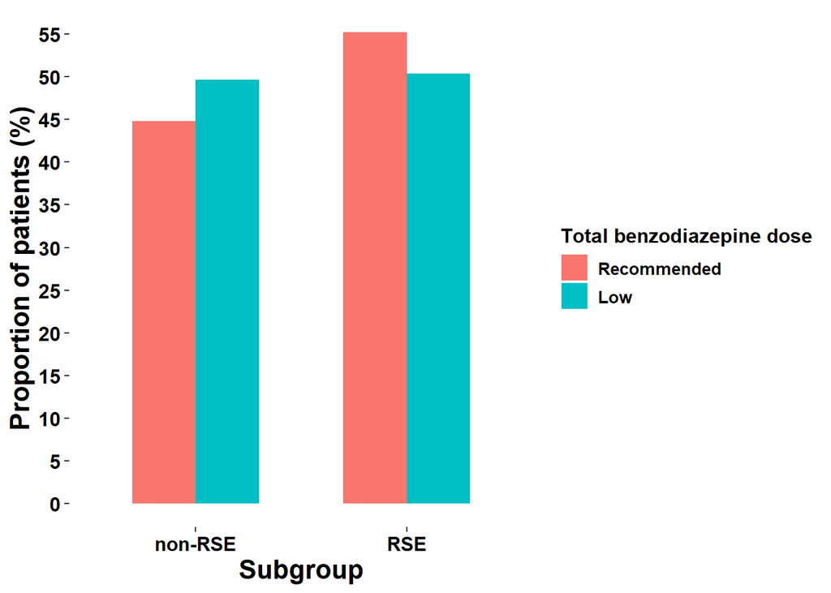

```r
#Transform value into percentages
percent_RSE <- pSERG %>%
    count(SE_GROUP, BZDlow10) %>%
    group_by(BZDlow10) %>%
    mutate(percent = (n / sum(n)) * 100) %>%
    ungroup()

#Create bar graph comparing BZD dose between subgroups
percent_RSE %>%
    ggplot(aes(x = SE_GROUP, y = percent, fill = BZDlow10)) +
    geom_bar(stat = "identity", position = "dodge", width = 0.6) +
    theme(axis.text = element_text(size = 12, color = "black", face = "bold"),
          axis.title = element_text(size = 16, color = "black", face = "bold"),
          legend.text = element_text(colour="black", size = 10, face = "bold"),
          legend.title = element_text(colour="black", size = 12, face = "bold"),
          panel.background = element_rect(fill = "transparent")) +
    scale_x_discrete(labels=c("non-RSE","RSE")) +
    scale_y_continuous(breaks = c(0, 5, 10, 15, 20, 25, 30, 35, 40, 45, 50, 55, 60, 65, 70)) +
    scale_fill_discrete(name="Total benzodiazepine dose",labels=c("Recommended", "Low")) +
    labs(x = "Subgroup", y = "Proportion of patients (%)")
```

#Bar graph low non-BZD ASM dose and RSE

```r
#Transform variable low non-BZD ASM dose into factor
class(pSERG$TOTALAEDlowSINGLEDOSE)
```

```
## [1] "numeric"
```

```r
pSERG$TOTALAEDlowSINGLEDOSE <- as.factor(as.numeric(pSERG$TOTALAEDlowSINGLEDOSE))
class(pSERG$TOTALAEDlowSINGLEDOSE)
```

```
## [1] "factor"
```

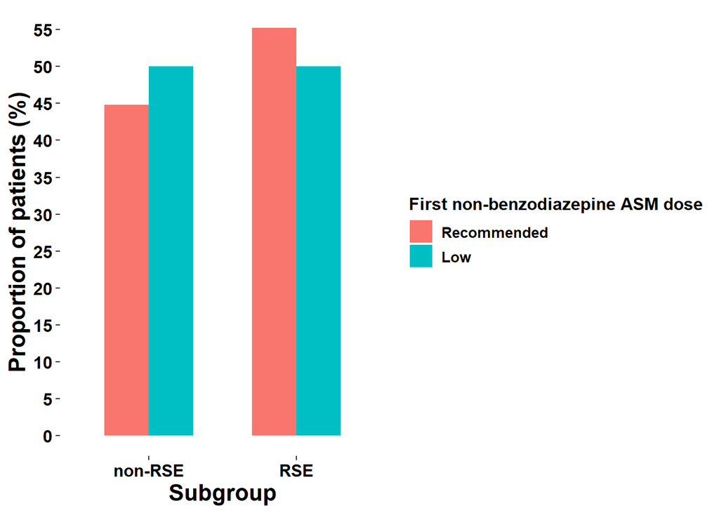

```r
#Transform value into percentages
percent_RSE <- pSERG %>%
    count(SE_GROUP, TOTALAEDlowSINGLEDOSE) %>%
    group_by(TOTALAEDlowSINGLEDOSE) %>%
    mutate(percent = (n / sum(n)) * 100) %>%
    ungroup()

#Create bar graph comparing non-BZD ASM dose between subgroups
percent_RSE %>%
    ggplot(aes(x = SE_GROUP, y = percent, fill = TOTALAEDlowSINGLEDOSE)) +
    geom_bar(stat = "identity", position = "dodge", width = 0.6) +
    theme(axis.text = element_text(size = 12, color = "black", face = "bold"),
          axis.title = element_text(size = 16, color = "black", face = "bold"),
          legend.text = element_text(colour="black", size = 10, face = "bold"),
          legend.title = element_text(colour="black", size = 12, face = "bold"),
          panel.background = element_rect(fill = "transparent")) +
    scale_x_discrete(labels=c("non-RSE","RSE")) +
    scale_y_continuous(breaks = c(0, 5, 10, 15, 20, 25, 30, 35, 40, 45, 50, 55, 60, 65, 70)) +
    scale_fill_discrete(name="First non-benzodiazepine ASM dose",labels=c("Recommended", "Low")) +
    labs(x = "Subgroup", y = "Proportion of patients (%)")
```